# 第五章： 专题 1： 点数据分析

章节作者：刘贇喆 | 华东师范大学 社会发展学院

更新时间：2026-11-13

章节概述

本章围绕空间点数据，学习用 `sf` 整理位置与属性，并结合**制图、聚合与空间统计**识别分布模式。

- **曼哈顿 Airbnb**：整理房源的每夜报价，学习价格分布、空间聚合，以及 **Moran’s I 与 LISA** 的全局和局部关联分析。
- **融合社交媒体与公共交通**：合并微博、小红书位置记录，用核密度估计（KDE）提取AOI，比较AOI内外记录到最近公交与地铁类POI的距离。

章节练习引入 **DBSCAN**，观察 `eps` 与 `minPts` 如何改变聚类；小组实践侧重**参数敏感性**与结果解释。

# **本章学习内容**

## **学习导航**

**本章学习内容**

欢迎开始 **第 5 章** 的学习。请点击 **下方导航卡** 进入相应小节：

**阅读提示**：通过返回主页或主页按钮，可回到本章学习导航。

**© 华东师范大学 社会发展学院 人口研究所** | [**DAWN 研究组**](https://dawn-ecnu.github.io) | yzliu@soci.ecnu.edu.cn

课程负责人：刘贇喆 本章作者：刘贇喆 | 敖漪宇

最后更新：2026年11月13日 构建环境：R version 4.6.1 (2026-06-24 ucrt)

[CC BY-NC-SA 4.0](https://creativecommons.org/licenses/by-nc-sa/4.0/deed.zh) 回到顶部

## **1.0 空间点数据**

### **1.0 空间点数据概论**

基本概念

第四章介绍了 `sf` 矢量表：每行是一条要素记录，`geometry` 列保存几何，其余列保存属性。本章关注其中的**空间点数据** （Spatial Point Data）。点的位置由坐标和坐标参考系 （Coordinate Reference System, CRS）共同确定。

**坐标表示位置**，其他字段说明对象或事件。 同一坐标可能对应几家店，也可能对应同一地点在不同时刻的多次签到。坐标因此不能充当记录的唯一编号；一条记录还可能包含地点名称、事件类型、时间和数据来源。

**读点图前，先辨认观察单位**

- **地点** 一家店、一座车站或一个设施入口。
- **事件** 某地某时的一次投诉、事故或签到。
- **移动位置** 一条轨迹中的某个采样点，或一次行程的起点、终点。

路灯可以直接记录为点。居民小区或城市在小比例尺地图上也常用代表点表示，此时点只概括位置，不能表示对象的完整范围。点位可能来自设备定位，也可能来自地址地理编码（Geocoding），即将地址转换为坐标。坐标精度和覆盖范围取决于数据的采集方式。

#### **1.1 点记录与观察单位**

下面选取纽约中城六座 Citi Bike 站点，将同一批记录放在表和地图中。字母 A—F 仅用于两边对照，每行对应一座站点。

> `capacity` 是站点的车位容量，不代表当时可借出的自行车数量。

六座 Citi Bike 站点的属性与几何

六座 Citi Bike 站点的属性与几何

| 记录 | 站点名称 | 车位 | `geometry` |
| --- | --- | --- | --- |
| A | W 35 St & 8 Ave | 45 | `POINT (-73.992805 40.752762)` |
| B | E 40 St & 5 Ave | 93 | `POINT (-73.981632 40.752062)` |
| C | W 42 St & 8 Ave | 41 | `POINT (-73.990985 40.757570)` |
| D | W 44 St & 5 Ave | 68 | `POINT (-73.980144 40.755003)` |
| E | W 49 St & 8 Ave | 67 | `POINT (-73.987882 40.762272)` |
| F | W 51 St & 6 Ave | 81 | `POINT (-73.980420 40.760660)` |

`geometry` 是 `sfc_POINT` 几何列，表中的 `POINT (x y)` 是便于阅读的文本表示。这里 `x = 经度`、`y = 纬度`，CRS 为 EPSG:4326。

MIDTOWN MANHATTAN

[figure not shown]

纽约中城的六座 Citi Bike 站点（A—F 与左表对应） [Citi Bike 快照](https://gbfs.citibikenyc.com/gbfs/en/station_information.json) 2026-10-14 · [© OpenStreetMap](https://www.openstreetmap.org/copyright)

#### **1.2 点分布与统计单元**

将同一批点汇总到不同的统计单元，结果可能随划分方式改变。这称为[**可变面元问题**](https://www.restore.ac.uk/geo-refer/91023cwors00y00000000.php) （Modifiable Areal Unit Problem, MAUP）。

> 布鲁克林 **6 × 6 km** 窗口内的 **380 座 Citi Bike 站点**

## 尺度效应

**单元大小**改变，局部汇总结果也可能改变。

**细网格 · 500 m**144 格 · 每格 0.25 km²

[figure not shown]

**粗网格 · 1.5 km**16 格 · 每格 2.25 km²

[figure not shown]

站点密度站/km²

- 0
- (0, 4]
- (4, 8]
- (8, 12]
- (12, 16]
- >16

## 分区效应

单元数量、面积相同，改变**边界位置**，汇总结果仍可能改变。

**横向分区 · 2 × 1.5 km**12 格 · 每格 3 km²

[figure not shown]

**纵向分区 · 1.5 × 2 km**12 格 · 每格 3 km²

[figure not shown]

站点密度站/km²

- 0
- (0, 4]
- (4, 8]
- (8, 12]
- (12, 16]
- >16

**延伸阅读 · 选区划分如何改变席位分配**

模拟选举共 **A 48 票、B 42 票**。九个小格各 10 票，图中票数按 A∶B 书写。

> 每三个相邻小格组成一个选区，区内票多的一方获得一席。

### 按行划区

**按行划区**A 获 3 席B 获 0 席

- 上排**16∶14****A 胜**
- 中排**16∶14****A 胜**
- 下排**16∶14****A 胜**

### 按列划区

**按列划区**A 获 1 席B 获 2 席

- 左列**14∶16****B 胜**
- 中列**14∶16****B 胜**
- 右列**20∶10****A 胜**

小格底色 A 领先 平票 B 领先

#### **1.3 常见的空间点记录**

**地点与设施点**

*兴趣点* （Point of Interest, POI）记录商店、车站等地点的位置，可附名称、类别等属性。

> 以下四个街区均截取 **1.6 × 1.6 km**，按相同的 OpenStreetMap 类别规则展示咖啡馆、图书馆与博物馆。

所选街区内已收录的兴趣点数量

所选街区内已收录的兴趣点数量

| 街区 | 咖啡馆 | 图书馆 | 博物馆 |
| --- | --- | --- | --- |
| **伦敦**特拉法加广场周边 | 179 | 2 | 4 |
| **纽约**曼哈顿中城 | 155 | 2 | 1 |
| **巴黎**卢浮宫周边 | 214 | 10 | 5 |
| **东京**上野周边 | 104 | 2 | 7 |

**伦敦**

[figure not shown]

**纽约**

[figure not shown]

**巴黎**

[figure not shown]

**东京**

[figure not shown]

[© OpenStreetMap contributors](https://www.openstreetmap.org/copyright) · 2026-10-14 · N 真北

- 咖啡馆
- 图书馆
- 博物馆

行为与事件点 （Event Points）

事件记录说明*何时、何地、发生什么*。车祸、犯罪案件、火灾、市政服务请求或社交媒体签到，都可以按发生地点记录为点。

时间精度可能从分钟到日期。地址或路口可转换为坐标，其定位精度取决于原始记录。

同一地点可反复产生记录。按时段绘图可观察数量与分布的变化，平台用户构成、上报意愿和数据缺漏也会影响观察结果。

> 图中街区和 **24 个事件**均为模拟。一天内分为 **8 个时间层**，每层相隔 3 小时。

[figure not shown]

- 签到
- 交通事件
- 热线诉求

轨迹采样点与起讫点

*轨迹* （Trajectory）由同一移动对象按时间排序的位置采样点组成。采样间隔、定位误差和信号缺失会影响路线判断。

*起讫记录* （Origin–Destination, OD）成对保存一趟行程的起点 **O** 与终点 **D**，可附出发时间、到达时间或交通方式。OD 可由完整轨迹简化，也可来自租借、进出站等系统记录。

> 本图轨迹与街网均为模拟，两条轨迹各有 **11 个采样点**，共享相同 O、D。连线用于辨认采样顺序，点间真实路径需另行判断。**OD 虚线仅表达起讫联系。**
- 轨迹 A
- 轨迹 B
- OD 联系

[figure not shown]

相同起讫点，对应两组不同的时序采样位置。

区域与对象的代表点

行政区、建筑轮廓等*多边形*也可生成点，用于标注位置、概括区域或连接区域间的行程。点的位置取决于所采用的计算方式。

代表点的计算方式与用途

| 表示方式 | 用途与解释 |
| --- | --- |
| 几何质心`st_centroid()` | 概括面形状的几何中心。凹形或带孔多边形的质心可能落在面外。 |
| 面内点`st_point_on_surface()` | 在面内放置符号或标签。 |
| 人口加权质心 | 概括人口分布的重心。 |

- 几何质心
- 面内点

矩形凹多边形

两种点重合质心位于面外

**© 华东师范大学 社会发展学院 人口研究所** | [**DAWN 研究组**](https://dawn-ecnu.github.io) | yzliu@soci.ecnu.edu.cn

课程负责人：刘贇喆 本章作者：刘贇喆 | 敖漪宇

最后更新：2026年11月13日 构建环境：R version 4.6.1 (2026-06-24 ucrt)

[CC BY-NC-SA 4.0](https://creativecommons.org/licenses/by-nc-sa/4.0/deed.zh) 回到顶部

## **2.0 点数据实战 1**

### **2.0 专题研究 1：曼哈顿 Airbnb 每夜报价**

#### **专题研究 1：从房源点到空间关联**

##### **分析导航**

**曼哈顿 Airbnb 空间探索流程**

本例从曼哈顿主岛的三期公开记录出发，检查有效每夜报价，按房源 ID 求均价并筛选均价的 P5–P95，再汇总为六边形中位报价。随后定义邻居与权重，用 Moran’s I 检验整体关联，用 LISA 定位局部高低报价组合。

**© 华东师范大学 社会发展学院 人口研究所** | [**DAWN 研究组**](https://dawn-ecnu.github.io) | yzliu@soci.ecnu.edu.cn

课程负责人：刘贇喆 本章作者：刘贇喆 | 敖漪宇

最后更新：2026年11月13日 构建环境：R version 4.6.1 (2026-06-24 ucrt)

[CC BY-NC-SA 4.0](https://creativecommons.org/licenses/by-nc-sa/4.0/deed.zh) 回到顶部

##### 研究课题

###### **2.1 从房源报价到空间关联**

**示例课题**

整理曼哈顿主岛三期Airbnb公开房源，将每夜报价汇总为六边形中位数，再回答：**相近报价是否倾向于相邻，局部高低值组合出现在哪里？**

从挂牌报价提出空间问题

房源的位置与每夜报价，为观察城市内部挂牌住宿的差异提供了线索。点图可以显示哪些地方报价较高或较低，但点位重叠和报价长尾会干扰区域比较；房源密集的位置，也未必对应较高的典型报价。

本例以曼哈顿主岛为研究区，使用[Inside Airbnb](https://insideairbnb.com/get-the-data/)在2026年3月、6月和9月公开的三个发布批次。`price`表示公开房源的每夜挂牌报价，单位为美元／夜，不代表实际成交价格。研究首先描述可观测报价的分布，再考察其空间关联。

把房源记录转为区域代表值

原始表的一行是一条**房源—批次记录**。同一房源可以跨批次出现，因此先按房源ID对已观测正价求均值，再筛选均价的P5–P95，使每个入选房源在后续分析中贡献一个代表报价；不同ID即使共用公开坐标，也分别保留。

仅有房源点还不足以比较区域典型报价。本例将入选ID归入面积为**0.10 km²**的完整六边形，每格至少有**5个不同ID**才计算格内房源均价的中位数。未达到门槛的格不补作零报价。至此，研究对象由逐条挂牌记录转为可比较的网格指标。

用ESDA连接整体模式与局部位置

探索性空间数据分析（exploratory spatial data analysis, ESDA）将分布图、地图与空间统计结合起来，用于描述空间差异、识别集聚与离群，并形成后续研究假设。[Anselin、Syabri与Kho（2006）](https://doi.org/10.1111/j.0016-7363.2005.00671.x)系统介绍了这类方法及其联系。

本例先用空间权重$W$定义哪些六边形互为邻居，再用全局Moran’s I概括整个研究区的报价关联。局部空间关联指标（local indicators of spatial association, LISA）是一类指标，本例采用其中的局部Moran识别高—高、低—低及高低反差的位置。全局关联与局部位置由此成为两个相继回答的问题。

> 本例的核心思路是：先明确每一步的统计单位，再用同一套网格和空间权重连接整体检验与局部定位。

**待检验的研究设想**

如果相近的中位报价在主岛内倾向于相邻，全局Moran’s I应呈现正向关联；局部检验则用于辨认这种关联出现在哪些格，以及哪些地方形成高低反差。地图上的连续色块提供空间线索，置换检验用于判断这些模式是否超出随机排列下的常见程度。

围绕这一设想，本研究依次回答三个问题：

1. **哪些报价进入分析？** 核对主岛范围、房源ID和价格字段，按ID汇总已观测正价，并在房源均价层筛选P5–P95。
2. **区域典型报价怎样随位置变化？** 将入选房源归入六边形，在样本支持充分的格内计算中位报价，比较高低值及其相邻关系。
3. **相近报价是否倾向于相邻，局部组合在哪里？** 使用同一套Queen邻接与行标准化权重，依次开展全局Moran检验和局部条件置换检验。

分析路线

| 分析环节 | 核心操作 | 形成的研究对象或证据 |
| --- | --- | --- |
| 数据检查 | 读取三期快照，核对坐标、主岛范围、房源ID与价格状态 | 有效正价的房源—批次记录 |
| 房源汇总 | 按ID求已观测报价的均值，再筛选P5–P95 | 每个入选ID的均价与代表位置 |
| 网格聚合 | 构建0.10 km²完整六边形，至少5个不同ID才计算中位数 | 区域中位报价及样本支持范围 |
| 权重与全局检验 | 排除无邻居格，重建Queen行标准化权重，计算Moran’s I并置换检验 | 整体空间关联的方向与统计证据 |
| 局部检验 | 沿用同一批参检格与权重，比较原始及调整后的局部p值 | 显著高低值组合及其对检验口径的敏感性 |
| 结果反思 | 比较筛选范围、网格尺度、ID门槛与权重设定 | 研究发现的适用条件与再分析方向 |

**分析单位与报价口径**

原始记录、房源均价与网格中位数分别对应**房源—批次记录、房源ID和六边形**，不能在解释中互换。三个发布批次提供的是挂牌信息快照，不构成连续成交记录；房型、入住条件及社区因素与报价差异的关系，需要补充资料后另行研究。

**方法延展 · 空间权重、Moran 散点图与 LISA**

**1. 把“邻近”写成空间权重。** Rook 邻接要求两个面共享边，Queen 邻接允许共享边或顶点；距离阈值与最近邻规则则按位置间的距离确定邻居。下图用方格说明两种接壤规则。

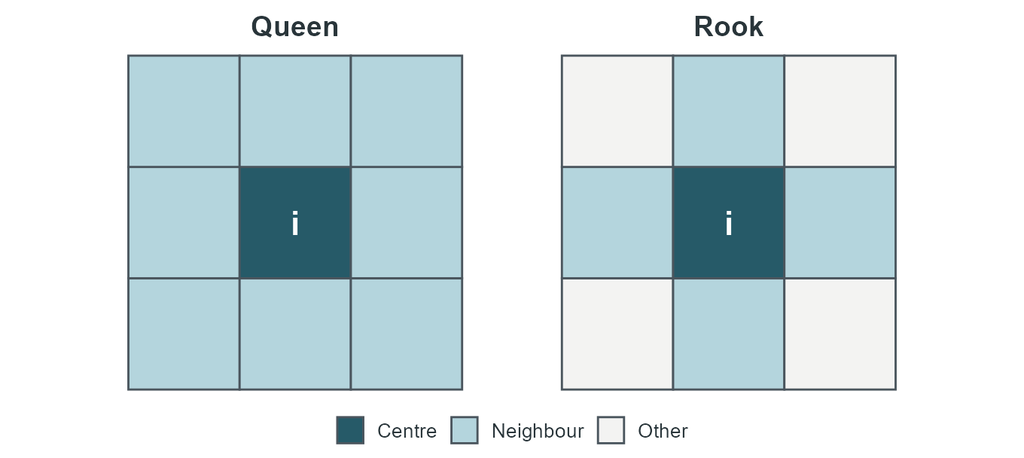

方格上的 Queen 与 Rook 邻接；i 为中心格，其周围的有色格表示邻居。

示意图仅说明接壤规则，不使用研究样本；配色与本章浅深色主题一致。

规则六边形密铺中，Queen 与 Rook 通常得到相同邻接；本例的有效格也已核对为相同。距离阈值或最近邻规则可提供不同的“周围”定义。完整说明见 [GeoDa 接壤权重教程](https://geodacenter.github.io/workbook/4a_contig_weights/lab4a.html)。

本例采用行标准化：若第 $i$ 格有 $k_i$ 个邻居，则各邻居的权重为 $1/k_i$，其他格的权重为零。令 $z_i$ 为第 $i$ 格标准化后的中位报价，空间滞后 （spatial lag） 为

$$(Wz)_i=\sum_j w_{ij}z_j.$$

因此，$Wz$ 可理解为邻居标准化报价的加权平均。本例先检查 **365 个达到 ID 门槛的完整六边形**，去掉 3 个没有 Queen 邻居的格，再对其余 **362 格**重建邻接与行标准化权重。地图的海岸遮罩只用于显示。

**2. 全局 Moran’s I 与散点图。** 一般形式为

$$I=\frac{n}{S_0}\frac{\sum_i\sum_j w_{ij}z_i z_j}{\sum_i z_i^2},
\qquad S_0=\sum_i\sum_j w_{ij}.$$

其中 $n$ 是统计计算使用的有效样本量，$S_0$ 是全部权重之和。正向关联表示相似数值倾向于相邻，负向关联表示相邻单元更常呈现反差。随机重排属性值时，期望为 $-1/(n-1)$，在样本量较大时接近零；统计量的可达范围取决于 $W$。

本例在剔除孤立格后，重新计算 362 格报价的均值与标准差。所有权重行和均为 1，因而 $n=S_0=362$；以 $z$ 为横轴、$Wz$ 为纵轴，**通过原点拟合的斜率等于本设定下的 Moran’s I**。全局置换检验固定格网位置与 $W$，随机重排报价，比较观测关联是否超出这种随机排列下常见的程度。参见 [Moran（1950）的经典文献](https://doi.org/10.1093/biomet/37.1-2.17) 与 [GeoDa 全局空间自相关教程](https://geodacenter.github.io/workbook/5a_global_auto/lab5a.html)。

**3. 从四象限走向局部检验。** [Anselin（1995）](https://doi.org/10.1111/j.1538-4632.1995.tb00338.x) 提出了 LISA 框架。下表中的高低均相对于**本次有效格的整体均值**；纵轴对应周围格的加权平均。

| 组合 | 该格 | 周围格 | 含义 |
| --- | --- | --- | --- |
| High–High（HH） | 高 | 高 | 相对高值的同向集聚。 |
| Low–Low（LL） | 低 | 低 | 相对低值的同向集聚。 |
| High–Low（HL） | 高 | 低 | 高值格与周围形成反差。 |
| Low–High（LH） | 低 | 高 | 低值格与周围形成反差。 |

象限先描述方向，局部检验再判断是否达到显著性门槛。本例采用局部条件置换的双侧模拟 $p$ 值，主图显示原始 $p\leq0.05$ 的局部类别；另以相同的原始 $p$ 值比较 BH、BY、Holm 与 Bonferroni 调整，检查显著范围对方法的敏感性。方法说明见 [GeoDa 局部空间自相关教程](https://geodacenter.github.io/workbook/6a_local_auto/lab6a.html)；R 的具体实现见 [spdep 的局部置换文档](https://r-spatial.github.io/spdep/reference/localmoran.html)。

**延伸阅读 · Airbnb、租差与城市住房研究**

空间探索可以衔接更具体的城市研究问题：高报价集聚区与旅游设施是否重合？房型构成是否解释部分地区差异？平台住宿供给与长期租赁、社区变化有怎样的关系？

- **纽约与租差。** Wachsmuth 与 Weisler（2018）的 *Airbnb and the rent gap: Gentrification through the sharing economy* 将纽约 Airbnb 的地理差异与租差、绅士化联系起来。可阅读[期刊原文入口](https://doi.org/10.1177/0308518X18778038)或[作者公开稿](https://upgo.lab.mcgill.ca/publication/airbnb-and-the-rent-gap/airbnb-and-the-rent-gap.pdf)，了解如何把空间格局转化为城市研究问题。租差指现有土地使用获得的地租与潜在更高地租之间的差额。
- **住房价格与租金。** Barron、Kung 与 Proserpio（2021）的 *The Effect of Home-Sharing on House Prices and Rents: Evidence from Airbnb* 研究平台住宿与住房市场的关系。[论文入口](https://doi.org/10.1287/mksc.2020.1227)可用于比较：检验价格关联，与识别 Airbnb 对租金或住房价格的影响，需要哪些不同资料和研究设计？

本例完成的是报价格局的 ESDA。上述机制可作为后续研究方向，需要补充住房、房型、设施及时间变化等资料再检验。

**© 华东师范大学 社会发展学院 人口研究所** | [**DAWN 研究组**](https://dawn-ecnu.github.io) | yzliu@soci.ecnu.edu.cn

课程负责人：刘贇喆 本章作者：刘贇喆 | 敖漪宇

最后更新：2026年11月13日 构建环境：R version 4.6.1 (2026-06-24 ucrt)

[CC BY-NC-SA 4.0](https://creativecommons.org/licenses/by-nc-sa/4.0/deed.zh) 回到顶部

##### 研究区域与数据

###### **2.2 研究区与三期数据**

研究范围

纽约市 （New York City, NYC）由五个行政区组成，编号与右侧定位图一致。

1. 1**曼哈顿**Manhattan
2. 2**皇后区**Queens
3. 3**布鲁克林**Brooklyn
4. 4**布朗克斯**The Bronx
5. 5**斯塔滕岛**Staten Island

本例范围 **曼哈顿主岛**，取行政区中面积最大的连续多边形。

> **离岛不纳入分析。**罗斯福岛等离岛，以及大陆上的 Marble Hill，均在本例边界外。

西临**哈德逊河**（Hudson River）东临**东河**（East River）；中央公园与街网供岛内定位

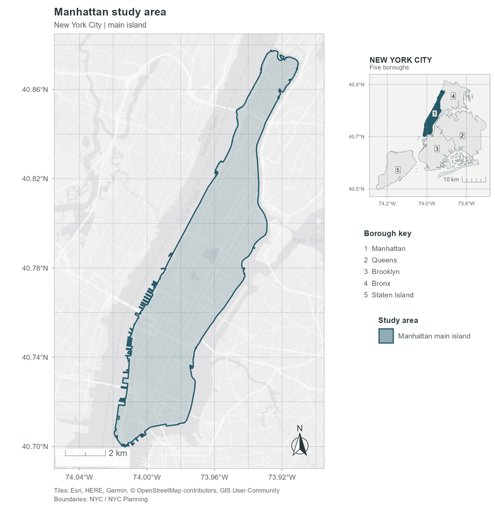

曼哈顿主岛研究区及其在纽约市的位置；右侧定位图标出五个行政区。

**查看并复制研究区定位图 R 代码**

按顺序运行本面板，在线读取官方边界与底图，在 Plots 面板显示研究区地图。后续图表共用这里的包、配色与底图，不依赖本机课程文件夹，也不保存图片。

**模块 1：加载本专题依赖。** 空间分析、地图要素与拼图分别由 `sf`／`spdep`、`ggspatial` 与 `cowplot` 完成。另需安装 `terra`、`jpeg`、`curl`、`viridisLite`、`units`、`ragg` 和 `knitr`。

```r
# 本专题只需加载一次；缺少的包先在 Console 用 install.packages() 安装。
library(dplyr)
library(readr)
library(sf)
library(spdep)
library(ggplot2)
library(classInt)
library(cowplot)
library(ggspatial)
library(scales)
library(withr)
# terra、jpeg、curl、viridisLite、units 和 ragg 在下文通过 包名::函数 调用。
```

**模块 2：在线读取边界并选择主题。** 得到五区边界 `nyc_boroughs` 与最大连续陆地 `main_island`；主岛提取在投影坐标系中比较面积，显示时使用经纬度。

```r
# 定位附图沿用 NYC Planning 五区边界，数据只保留在 R 对象中。
nyc_boroughs <- st_read(
  "https://data.cityofnewyork.us/resource/gthc-hcne.geojson", quiet = TRUE) %>%
  st_transform(4326)

# 分析主岛沿用本例的 ArcGIS 边界来源，不用定位附图替换分析范围。
boundary_url <- paste0(
  "https://services5.arcgis.com/GfwWNkhOj9bNBqoJ/arcgis/rest/services/",
  "NYC_Borough_Boundary/FeatureServer/0/query?where=1=1&outFields=*&outSR=4326&f=pgeojson")

# st_cast() 拆开同一区的离散陆地；用投影面积选出曼哈顿主岛。
main_island <- st_read(boundary_url, quiet = TRUE) %>%
  filter(BoroName == "Manhattan") %>%
  st_make_valid() %>%
  st_cast("POLYGON") %>%
  mutate(area_ft2 = as.numeric(st_area(st_transform(geometry, 2263)))) %>%
  slice_max(area_ft2, n = 1, with_ties = FALSE) %>%
  select(BoroName)

figure_mode <- "light" # 改为 "dark" 后重跑各图的制图模块。
```

**模块 3：定义浅深色配色。** 外画布透明，地图面板保留中性底色；正文、网格与边界颜色分别适配两个主题。

```r
topic1_tutorial_palette <- function(mode = "light") {
  mode <- match.arg(mode, c("light", "dark"))
  list(
    light = list(background = "transparent", page = "#FFFFFF", panel = "#F3F3F2",
      land = "#E6E7E5", text = "#29353A", muted = "#4A555D", grid = "#788E95",
      boundary = "#265A68", halo = "#FFFFFF", context_line = "#8A989A"),
    dark = list(background = "transparent", page = "#211F25", panel = "#27262A",
      land = "#36363A", text = "#F1EDF1", muted = "#CAC3CD", grid = "#A8A1B0",
      boundary = "#9FDEEB", halo = "#211F25", context_line = "#817C88")
  )[[mode]]
}
```

**模块 4：在线读取底图。** 以 XYZ 的列号、行号定位同一批 Esri 浅灰瓦片。`lapply()` 对每张瓦片执行同一转换，再合并为带坐标的栅格；无需手动下载或保存文件。

```r
tile_keys <- expand.grid(x = 1205:1207, y = 1537:1540)
tile_base <- paste0("https://server.arcgisonline.com/ArcGIS/rest/services/",
  "Canvas/World_Light_Gray_Base/MapServer/tile")
half_world <- 20037508.342789244
tile_span <- 2 * half_world / 2^12 # 第 12 级瓦片的宽度，单位为米。

tiles <- lapply(seq_len(nrow(tile_keys)), function(i) {
  # curl 返回内存中的原始字节；readJPEG() 解码成 RGB 数组。
  tile_url <- sprintf("%s/12/%d/%d", tile_base, tile_keys$y[i], tile_keys$x[i])
  rgb <- jpeg::readJPEG(curl::curl_fetch_memory(tile_url)$content)
  tile <- terra::rast(nrows = dim(rgb)[1], ncols = dim(rgb)[2], nlyrs = 3,
    xmin = -half_world + tile_keys$x[i] * tile_span,
    xmax = -half_world + (tile_keys$x[i] + 1) * tile_span,
    ymin = half_world - (tile_keys$y[i] + 1) * tile_span,
    ymax = half_world - tile_keys$y[i] * tile_span, crs = "EPSG:3857")
  # 调整数组顺序，使图片行列与 terra 的像元顺序一致。
  terra::values(tile) <- matrix(as.vector(aperm(rgb, c(2, 1, 3))), ncol = 3)
  tile
})
basemap_raster <- terra::project(do.call(terra::merge, tiles),
  "EPSG:4326", method = "bilinear")
basemap <- list(image = terra::as.array(basemap_raster),
  bounds = as.vector(terra::ext(basemap_raster)))
```

**模块 5：让底图适应浅深色。** 此函数只调节底图颜色与透明度，返回可加入 `ggplot()` 的图层。`function(mode)` 使后续地图复用同一套处理；RGB 三个通道采用相同混合规则。

```r
topic1_tutorial_basemap_layers <- function(mode = "light") {
  ink <- topic1_tutorial_palette(mode)
  image <- basemap$image
  background <- as.numeric(grDevices::col2rgb(ink$panel)) / 255
  if (mode == "dark") {
    luminance <- .2126 * image[, , 1] + .7152 * image[, , 2] + .0722 * image[, , 3]
    contrast <- pmin(1 - luminance, .45) * .38
    for (channel in 1:3) {
      chroma <- image[, , channel] - luminance
      image[, , channel] <- pmin(1, pmax(0,
        background[channel] + contrast + chroma * .80))
    }
  }
  alpha <- if (mode == "light") .50 else .55
  for (channel in 1:3) {
    image[, , channel] <- image[, , channel] * alpha + background[channel] * (1 - alpha)
  }
  bounds <- basemap$bounds
  list(ggplot2::annotation_raster(grDevices::as.raster(image),
    xmin = bounds[1], xmax = bounds[2], ymin = bounds[3], ymax = bounds[4]))
}
```

**模块 6：定义共用画布与地图视野。** 所有地图使用同一视野与经纬网；配色函数把页面主题写入各图的数据色阶。

```r
# 主岛视野与经纬网；后续点图、六边形图沿用同一范围。
topic1_price_map_context <- function(main_island) {
  x_limits <- c(-74.055, -73.895)
  y_limits <- c(40.690, 40.885)
  frame <- sf::st_as_sfc(sf::st_bbox(c(xmin = x_limits[1], ymin = y_limits[1],
    xmax = x_limits[2], ymax = y_limits[2]), crs = sf::st_crs(4326)))
  graticule <- sf::st_graticule(frame, crs = sf::st_crs(4326),
    datum = sf::st_crs(4326), lon = seq(-74.04, -73.90, by = .04),
    lat = seq(40.70, 40.86, by = .04))
  list(main_island = sf::st_transform(main_island, 4326),
    x_limits = x_limits, y_limits = y_limits, graticule = graticule)
}

# 画布跟随教程背景，paper仅用于标签与图形内部的遮罩。
topic1_price_tutorial_style <- function(ink, mode) {
  tutorial <- topic1_tutorial_palette(mode)
  ink$background <- tutorial$background
  ink$paper <- tutorial$page
  ink$panel <- tutorial$panel
  ink$map_ground <- tutorial$panel
  ink$water <- tutorial$panel
  ink$land <- tutorial$land
  ink$text <- tutorial$text
  ink$ink <- tutorial$text
  ink$muted <- tutorial$muted
  ink$grid <- tutorial$grid
  ink$boundary <- tutorial$boundary
  ink$scale <- tutorial$text
  ink$halo <- tutorial$halo
  ink
}

topic1_price_canvas_theme <- function() {
  ggplot2::theme(
    plot.background = ggplot2::element_rect(fill = "transparent", colour = NA),
    panel.background = ggplot2::element_rect(fill = "transparent", colour = NA))
}

# 研究区定位图的配色：主岛高亮、五区灰底、编号标签与附图边框。
topic1_price_study_style <- function(mode) {
  tutorial <- topic1_tutorial_palette(mode)
  list(study_fill = tutorial$boundary, land = tutorial$land,
    land_boundary = tutorial$context_line, locator_study_boundary = tutorial$boundary,
    locator_grid = tutorial$grid, locator_label = tutorial$text,
    locator_label_bg = scales::alpha(tutorial$page, .92),
    locator_axis = tutorial$muted, axis_tick = tutorial$grid,
    locator_panel = tutorial$panel, locator_border = tutorial$context_line,
    paper = tutorial$page, locator_title = tutorial$text,
    locator_subtitle = tutorial$muted, legend_title = tutorial$text,
    legend_text = tutorial$muted, study_grid = tutorial$grid,
    study_boundary = tutorial$boundary, north = tutorial$text,
    axis_text = tutorial$muted, panel = tutorial$panel,
    panel_border = tutorial$context_line, title = tutorial$text,
    subtitle = tutorial$muted, caption = tutorial$muted)
}
```

**模块 7：准备视野和五区编号。** 各区取最大陆地的面内点放置编号；`lapply()` 依次处理五区。主图与定位附图分别生成经纬网。

```r
mode <- figure_mode
context <- topic1_price_map_context(main_island)
main_island <- context$main_island
nyc_boroughs <- sf::st_transform(nyc_boroughs, 4326)
study_ink <- topic1_price_study_style(mode)
font_family <- "sans"
borough_order <- c("Manhattan", "Queens", "Brooklyn", "Bronx", "Staten Island")
borough_metric <- sf::st_transform(nyc_boroughs, 2263)

# 各区编号锚点：取最大陆地部分的面内点。
label_list <- lapply(seq_along(borough_order), function(i) {
  one_borough <- borough_metric[borough_metric$boroname == borough_order[i], ]
  parts <- suppressWarnings(sf::st_cast(sf::st_geometry(one_borough), "POLYGON"))
  largest_part <- parts[which.max(as.numeric(sf::st_area(parts)))]
  label_point <- sf::st_point_on_surface(largest_part)
  sf::st_sf(number = as.character(i), borough = borough_order[i], geometry = label_point)
})
borough_labels <- sf::st_transform(do.call(rbind, label_list), 4326)

# 主图与附图各自的视野和经纬网。
x_limits <- c(-74.055, -73.895)
y_limits <- c(40.69, 40.885)
main_frame <- sf::st_as_sfc(sf::st_bbox(c(xmin = x_limits[1], ymin = y_limits[1],
  xmax = x_limits[2], ymax = y_limits[2]), crs = sf::st_crs(4326)))
main_graticule <- sf::st_graticule(main_frame, crs = sf::st_crs(4326),
  datum = sf::st_crs(4326), lon = seq(-74.04, -73.9, by = 0.02),
  lat = seq(40.7, 40.88, by = 0.02))
locator_x <- c(-74.29, -73.68)
locator_y <- c(40.47, 40.94)
locator_frame <- sf::st_as_sfc(sf::st_bbox(c(xmin = locator_x[1], ymin = locator_y[1],
  xmax = locator_x[2], ymax = locator_y[2]), crs = sf::st_crs(4326)))
locator_graticule <- sf::st_graticule(locator_frame, crs = sf::st_crs(4326),
  datum = sf::st_crs(4326), lon = c(-74.2, -74, -73.8), lat = c(40.5, 40.7, 40.9))
study_fill <- study_ink$study_fill
longitude_labels <- function(x) sprintf("%.1f°W", abs(x))
latitude_labels <- function(y) sprintf("%.1f°N", y)
```

**模块 8：绘制五区定位附图。** `geom_sf_label()` 标注编号，标签函数只改变经纬度文字；比例尺使用米制。得到附图 `locator`。

```r
# 附图：纽约五区与主岛位置。
locator <- ggplot2::ggplot() +
  ggplot2::geom_sf(data = nyc_boroughs, fill = study_ink$land,
    colour = study_ink$land_boundary, linewidth = 0.19) +
  ggplot2::geom_sf(data = main_island, fill = study_fill,
    colour = study_ink$locator_study_boundary, linewidth = 0.38) +
  ggplot2::geom_sf(data = locator_graticule, colour = study_ink$locator_grid,
    alpha = 0.55, linewidth = 0.23) +
  ggplot2::geom_sf_label(data = borough_labels, ggplot2::aes(label = number),
    fun.geometry = function(x) x, size = 2.6, fontface = "bold", family = font_family,
    colour = study_ink$locator_label, fill = study_ink$locator_label_bg,
    linewidth = 0.16, label.padding = grid::unit(0.1, "lines"),
    label.r = grid::unit(0.08, "lines")) +
  ggplot2::scale_x_continuous(breaks = c(-74.2, -74, -73.8), labels = longitude_labels) +
  ggplot2::scale_y_continuous(breaks = c(40.5, 40.7, 40.9), labels = latitude_labels) +
  ggplot2::coord_sf(crs = sf::st_crs(4326), default_crs = sf::st_crs(4326),
    datum = sf::st_crs(4326), xlim = locator_x, ylim = locator_y, expand = FALSE) +
  ggspatial::annotation_scale(location = "br", width_hint = 0.22, style = "ticks",
    unit_category = "metric", line_col = study_ink$axis_text,
    text_col = study_ink$axis_text, line_width = 0.45, text_cex = 0.61,
    pad_x = grid::unit(0.08, "in"), pad_y = grid::unit(0.26, "in")) +
  ggplot2::labs(title = "NEW YORK CITY", subtitle = "Five boroughs")
```

**模块 9：设置定位附图样式。** 统一面板、坐标轴与标题的颜色和间距，沿用当前主题。

```r
locator <- locator +
  ggplot2::theme_minimal(base_family = font_family) +
  ggplot2::theme(panel.grid = ggplot2::element_blank(),
    axis.title = ggplot2::element_blank(),
    axis.text = ggplot2::element_text(size = 6.5, colour = study_ink$locator_axis),
    axis.ticks = ggplot2::element_line(colour = study_ink$axis_tick, linewidth = 0.25),
    axis.ticks.length = grid::unit(1.5, "pt"),
    panel.background = ggplot2::element_rect(fill = study_ink$locator_panel, colour = NA),
    panel.border = ggplot2::element_rect(fill = NA,
      colour = study_ink$locator_border, linewidth = 0.4),
    plot.background = ggplot2::element_rect(fill = "transparent", colour = NA),
    plot.title = ggplot2::element_text(size = 10, face = "bold",
      colour = study_ink$locator_title, margin = ggplot2::margin(b = 1)),
    plot.subtitle = ggplot2::element_text(size = 8,
      colour = study_ink$locator_subtitle, margin = ggplot2::margin(b = 4)),
    plot.margin = ggplot2::margin(3, 3, 3, 3))
```

**模块 10：绘制主岛地图。** 从底图开始，依次加入经纬网、主岛、研究区图例、坐标、比例尺与真北指示，得到主图 `map`。

```r
# 主图：主岛研究区。
map <- ggplot2::ggplot() +
  topic1_tutorial_basemap_layers(mode) +
  ggplot2::geom_sf(data = main_graticule, colour = study_ink$study_grid,
    alpha = 0.43, linewidth = 0.22) +
  ggplot2::geom_sf(data = main_island, ggplot2::aes(fill = "Manhattan main island"),
    alpha = 0.2, colour = study_ink$study_boundary, linewidth = 0.76) +
  ggplot2::annotate("rect", xmin = -74.054, xmax = -74.01,
    ymin = 40.691, ymax = 40.699, fill = study_ink$paper, alpha = 0.9, colour = NA) +
  ggplot2::scale_fill_manual(name = "Study area",
    values = c(`Manhattan main island` = study_fill),
    guide = ggplot2::guide_legend(override.aes = list(alpha = 0.5, linewidth = 0.7))) +
  ggplot2::scale_x_continuous(breaks = seq(-74.04, -73.9, by = 0.04),
    labels = function(x) sprintf("%.2f°W", abs(x))) +
  ggplot2::scale_y_continuous(breaks = seq(40.7, 40.88, by = 0.04),
    labels = function(y) sprintf("%.2f°N", y)) +
  ggplot2::coord_sf(crs = sf::st_crs(4326), default_crs = sf::st_crs(4326),
    datum = sf::st_crs(4326), xlim = x_limits, ylim = y_limits, expand = FALSE) +
  ggspatial::annotation_scale(location = "bl", width_hint = 0.19, style = "ticks",
    unit_category = "metric", line_col = study_ink$axis_text,
    text_col = study_ink$axis_text, line_width = 0.55, text_cex = 0.9,
    pad_x = grid::unit(0.2, "in"), pad_y = grid::unit(0.23, "in")) +
  ggspatial::annotation_north_arrow(location = "br", which_north = "true",
    height = grid::unit(0.57, "in"), width = grid::unit(0.49, "in"),
    pad_x = grid::unit(0.19, "in"), pad_y = grid::unit(0.18, "in"),
    style = ggspatial::north_arrow_fancy_orienteering(line_col = study_ink$north,
      fill = c(study_ink$paper, study_ink$north), text_col = study_ink$north,
      text_family = font_family, text_size = 11)) +
  ggplot2::labs(title = "Manhattan study area", subtitle = "New York City | main island",
    caption = paste0("Tiles: Esri, HERE, Garmin, © OpenStreetMap contributors, GIS User Community\n",
      "Boundaries: NYC / NYC Planning"))
```

**模块 11：设置主图与图例样式。** 设置中性地图面板、透明外画布与研究区图例。所有颜色来自前面的配色对象。

```r
map <- map +
  ggplot2::theme_minimal(base_family = font_family, base_size = 11) +
  ggplot2::theme(panel.grid = ggplot2::element_blank(),
    axis.title = ggplot2::element_blank(),
    axis.text = ggplot2::element_text(size = 9.2, colour = study_ink$axis_text),
    axis.ticks = ggplot2::element_line(colour = study_ink$axis_tick, linewidth = 0.3),
    axis.ticks.length = grid::unit(2.5, "pt"),
    panel.background = ggplot2::element_rect(fill = study_ink$panel, colour = NA),
    panel.border = ggplot2::element_rect(fill = NA,
      colour = study_ink$panel_border, linewidth = 0.35),
    plot.background = ggplot2::element_rect(fill = "transparent", colour = NA),
    plot.title = ggplot2::element_text(size = 14, face = "bold", colour = study_ink$title),
    plot.subtitle = ggplot2::element_text(size = 9.8, colour = study_ink$subtitle,
      margin = ggplot2::margin(b = 6)),
    plot.caption = ggplot2::element_text(size = 8.1, colour = study_ink$caption,
      hjust = 0, lineheight = 1.15, margin = ggplot2::margin(t = 9)),
    legend.position = "right", legend.direction = "vertical",
    legend.title.position = "top",
    legend.title = ggplot2::element_text(size = 10, face = "bold",
      colour = study_ink$legend_title),
    legend.text = ggplot2::element_text(size = 9.2, colour = study_ink$legend_text),
    legend.key.size = grid::unit(0.28, "in"),
    plot.margin = ggplot2::margin(10, 13, 12, 13))
```

**模块 12：组合并直接显示。** `get_legend()` 提取研究区图例；`draw_plot()` 的位置与宽高按整个画布的 0—1 比例指定。最后显示 `area_plot`，无需导出文件。

```r
# 组合主图、附图、五区编号说明与研究区图例。
# agg 保持拼图中文字度量一致，完成后恢复原设备设置。
previous_device <- cowplot::set_null_device("agg")
study_legend <- cowplot::get_legend(map)
figure <- cowplot::ggdraw() +
  cowplot::draw_plot(map + ggplot2::theme(legend.position = "none"),
    x = 0.005, y = 0, width = 0.69, height = 1) +
  cowplot::draw_plot(locator, x = 0.7, y = 0.565, width = 0.295, height = 0.355) +
  cowplot::draw_label("Borough key", x = 0.735, y = 0.55, hjust = 0, vjust = 1,
    size = 10, fontface = "bold", fontfamily = font_family,
    colour = study_ink$legend_title) +
  cowplot::draw_label(paste0(seq_along(borough_order), "  ", borough_order,
    collapse = "\n"), x = 0.735, y = 0.52, hjust = 0, vjust = 1, size = 9.2,
    lineheight = 1.35, fontfamily = font_family, colour = study_ink$legend_text) +
  cowplot::draw_grob(study_legend, x = 0.72, y = 0.305, width = 0.275, height = 0.1)
area_plot <- figure + topic1_price_canvas_theme()
cowplot::set_null_device(previous_device)
area_plot
```

**城市背景 · 曼哈顿的人口与经济**

曼哈顿行政区对应**纽约县**（New York County）。常住人口约**166.5 万**（2025 年 7 月）；人口密度约**2.89 万人／km²**（2020 年，[美国人口普查局](https://www.census.gov/quickfacts/newyorkcountynewyork)）。2024 年实际 GDP 约**8,137 亿美元**，居美国各县之首（2017 年链式美元，[BEA](https://www.bea.gov/news/2026/gross-domestic-product-county-and-personal-income-county-2024)）。

以上为曼哈顿行政区统计，范围大于本例的曼哈顿主岛。

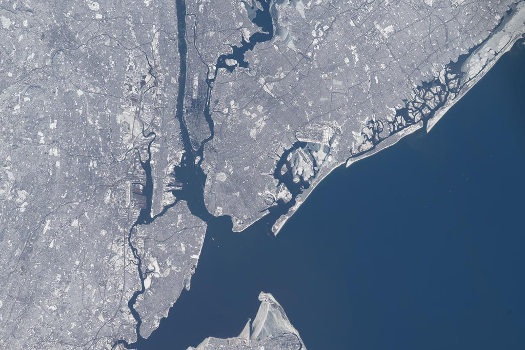

[纽约日景](https://images.nasa.gov/details/iss074e0315625) · 2026-02-13

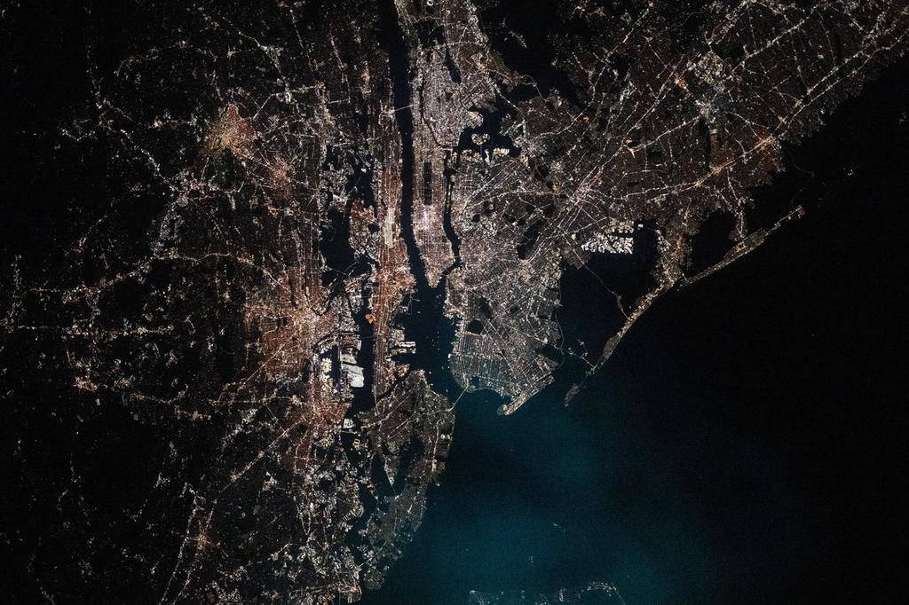

[纽约夜景](https://images.nasa.gov/details/iss073e0658285) · 2025-09-11

[figure not shown]

[时代广场](https://commons.wikimedia.org/wiki/File:Times_Square,_NYC_at_night_-_August_2025.jpg) · 2025-08-31

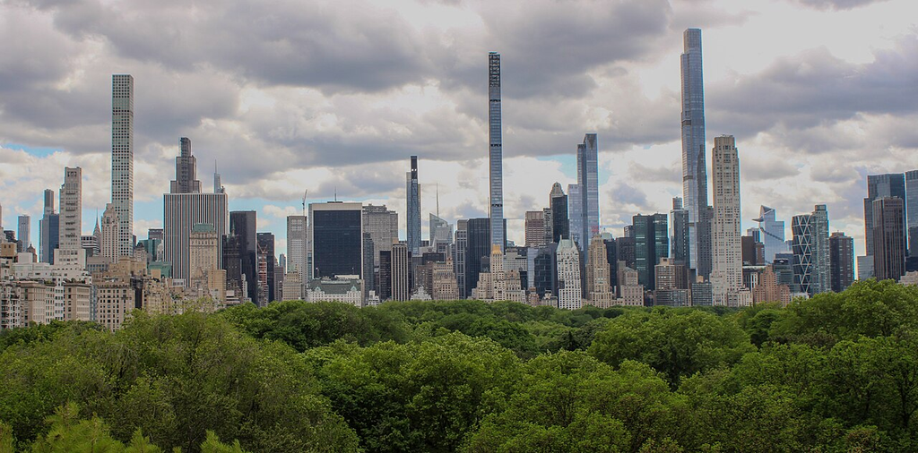

[中央公园与中城](https://commons.wikimedia.org/wiki/File:Central_Park_seen_from_the_Metropolitan_Museum_May_2025.jpg) · 2025-05-19

影像：NASA/Chris Williams；街景：Nielsoncaetanosalmeron、Boaventuravinicius（[CC BY 4.0](https://creativecommons.org/licenses/by/4.0/)）。

三期快照与记录单位

[Airbnb](https://www.airbnb.com/help/article/5) 是连接房东与旅客的住宿平台，房源包含整套房源、私人房间等类型。[Inside Airbnb](https://insideairbnb.com/about/) 是独立整理平台公开信息的项目，提供房源、日历与评论等数据下载。一次发布是当时可见信息的**快照**：同一房源可以在不同批次出现，房源上下架及信息更新也会改变样本。

> 本例采用 **2026 年 1—9 月**间的三个公开发布批次。原始文件见 [Inside Airbnb 数据目录](https://insideairbnb.com/get-the-data/)，使用前核对[数据使用政策](https://insideairbnb.com/data-policies/)。
1. 3 月发布2026-03-16
2. 6 月发布2026-06-14
3. 9 月发布2026-09-14

> 本例使用房源位置与公开报价。Inside Airbnb 的[数据说明](https://insideairbnb.com/data-assumptions/)指出，公开坐标经过匿名化，与实际地址可能相差约 0–150 m。

| 字段 | 含义与记录规则 | 分析用途 |
| --- | --- | --- |
| `id` 与发布批次 | 每批次每个 ID 一条，可跨批次出现 | 检查记录与批次构成 |
| `longitude`、`latitude` | 房源公开经纬度 | 限定主岛、确定代表位置 |
| `price` | 公开报价折算的每夜金额 | 价格检查、筛选与汇总 |
| `price_quote_checkin_date` `price_quote_checkout_date` | 入住／退房日期；相减为报价夜数 | 识别入住日期与报价时长 |
| `minimum_nights`、`room_type` | 最低入住限制与房型 | 分组比较报价条件 |

**阅读提示 · 发布日期、入住日期与每夜报价**

发布批次记录数据的发布时间；报价所对应的入住、退房日期由 `price_quote_checkin_date` 与 `price_quote_checkout_date` 给出，两者之差为报价夜数。实际入住日期可能跨到下一年。

`minimum_nights` 是房源的最低入住限制；本次报价夜数应由报价所列的入住、退房日期计算。`price` 已是**每夜报价**，无需再除以入住夜数。

各次报价的入住日期、时长、房型和折扣可能不同，可用这些字段进一步分组比较。三期汇总概括的是三个快照中的挂牌报价，不能解释为连续九个月的成交记录。

价格字段检查

**先检查价格字段。**下表按价格状态统计三期原表与曼哈顿主岛记录。

> “**价格缺失**”包括空白值；“**解析失败**”指非空价格无法转换为数值。

三期 Airbnb 价格字段状态

| 统计范围 | 记录数 | 价格缺失 | 解析失败 | 负价 | 零价 | 正价 |
| --- | --- | --- | --- | --- | --- | --- |
| 纽约市三期原表 | 96,156 | 33,800 | 0 | 0 | 0 | 62,356 |
| 曼哈顿主岛 | 43,589 | 15,853 | 0 | 0 | 0 | 27,736 |

三期数据均无负价或零价。主岛内 **43,589 条记录**中，**15,853 条价格缺失**，其余 **27,736 条为有效正价记录**。

**查看并复制三期读取与价格检查 R 代码**

先运行研究区代码中的依赖声明与边界读取，得到 `main_island`。以下直接从 Inside Airbnb 读取三个压缩 CSV，合并到内存中的数据框；首次运行需联网。

**三期文件读取与字段解析**

合并三个发布批次并解析报价，得到保留批次和报价日期的 `listing_rows`。

```r
release_dates <- c("2026-03-16", "2026-06-14", "2026-09-14")
source_base <- "https://data.insideairbnb.com/united-states/ny/new-york-city"
quote_fields <- c("id", "longitude", "latitude", "price", "room_type",
  "minimum_nights", "price_quote_checkin_date", "price_quote_checkout_date")

# 函数负责读取一个批次；read_csv() 可直接读取在线压缩 CSV。
read_release <- function(release_date) {
  source_url <- paste0(source_base, "/", release_date, "/data/listings.csv.gz")
  read_csv(source_url, col_select = all_of(quote_fields),
    col_types = cols(.default = col_character(),
      longitude = col_double(), latitude = col_double()),
    show_col_types = FALSE, progress = FALSE) %>%
    mutate(snapshot = release_date,
      price_usd = parse_number(price, locale = locale(grouping_mark = ",")),
      quote_checkin = as.Date(price_quote_checkin_date),
      quote_checkout = as.Date(price_quote_checkout_date),
      quote_nights = as.integer(quote_checkout - quote_checkin))
}
# 对三个发布日期分别读取，再按行合并；保留发布批次用于比较。
listing_rows <- bind_rows(lapply(release_dates, read_release))
```

**坐标与主岛范围**

保留有限坐标及主岛内记录，得到 `main_island_rows`；报价缺失值仍保留用于统计。

```r
# 模块 4：先检查坐标，再确定主岛内记录；保留报价缺失以便统计。
valid_location <- is.finite(listing_rows$longitude) &
  is.finite(listing_rows$latitude)
located_rows <- listing_rows[valid_location, ]
on_main_island <- lengths(st_intersects(
  st_as_sf(located_rows, coords = c("longitude", "latitude"), crs = 4326),
  main_island
)) > 0L
main_island_rows <- located_rows[on_main_island, ]
```

**报价状态检查**

对比原表与主岛记录，输出缺失、解析失败及正负报价的计数。

```r
# 模块 5：分别报告原表与主岛记录的价格缺失、解析和正负状态。
count_price_status <- function(rows, scope) {
  price_missing <- is.na(rows$price) | trimws(rows$price) == ""
  price_valid <- is.finite(rows$price_usd)
  tibble::tibble(
    scope = scope,
    records = nrow(rows),
    missing = sum(price_missing),
    parse_failed = sum(!price_missing & !price_valid),
    negative = sum(price_valid & rows$price_usd < 0),
    zero = sum(price_valid & rows$price_usd == 0),
    positive = sum(price_valid & rows$price_usd > 0)
  )
}
price_eda <- bind_rows(
  count_price_status(listing_rows, "纽约市三期原表"),
  count_price_status(main_island_rows, "曼哈顿主岛")
)
price_eda %>%
  mutate(across(-scope, ~ format(.x, big.mark = ",", trim = TRUE))) %>%
  knitr::kable(
    format = "html",
    caption = "三期 Airbnb 价格字段状态",
    col.names = c("统计范围", "记录数", "价格缺失", "解析失败",
                  "负价", "零价", "正价"),
    align = c("l", rep("r", 6))
  )
```

**有效正价**

仅保留有限且大于零的每夜报价，得到后续分布与均价计算所用的 `positive_rows`。

```r
# 模块 6：保留可用且大于零的每夜报价，供分布检查与 ID 汇总。
positive_rows <- main_island_rows %>%
  filter(is.finite(price_usd), price_usd > 0)
```

三期房源点分布

三张地图分别展示各发布批次的**有效正价记录**，共用地图范围、**Fisher 七级断点**与色盘。

> 分类在合并三期报价的 `log10` 尺度上计算，图例以**美元／夜**表示。

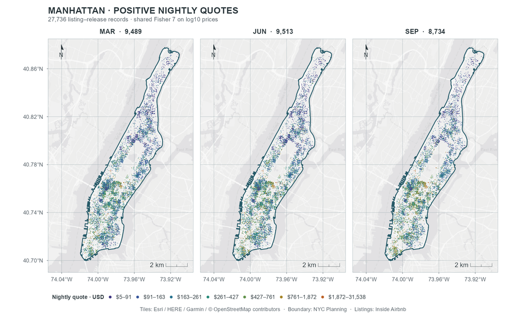

2026 年三期曼哈顿主岛的 27,736 条有效正价记录；三幅地图共用 Fisher 七级断点。

**本图的基本解读。** 三期点图均可见报价的空间差异：北段较多较低报价点，中南段混合分布着更多较高报价点。点位较密的地方存在遮挡，后续用六边形聚合后再比较区域模式。三个发布批次中的房源构成与实际入住日期不同，跨期价格变化还需在相同报价条件下另行比较。

**查看并复制三期房源点图 R 代码**

先运行研究区定位图代码得到主题与底图函数，再运行三期读取代码得到 `positive_rows` 与 `main_island`。以下依次完成分级、点位转换、地图图层与三期分面，最后直接显示。

**模块 1：定义三期点图配色。** 七个价格类别共用一组颜色；深色主题增加轻微光晕以分离叠点。

```r
topic1_price_release_style <- function(mode) {
  styles <- list(
    light = list(hist_bar = "#3199A0", hist_tail = "#BACBD2", hist_kde = "#A83A51",
      hist_fence = "#A6293D", hist_band = "#64B6B8", hist_rug = "#2E5666",
      point = c("#403782", "#36569C", "#26728F", "#278A79", "#62934B", "#A68425", "#BD6227"),
      point_alpha = .75, point_size = .68, glow_alpha = 0, glow_size = 0),
    dark = list(hist_bar = "#57D2D3", hist_tail = "#506B7E", hist_kde = "#FFCD81",
      hist_fence = "#FFCA77", hist_band = "#3E999D", hist_rug = "#B1D4E0",
      point = c("#AB9AF5", "#83A9F5", "#63C5E8", "#60DBCB", "#A7E38F", "#F4D773", "#FFAB70"),
      point_alpha = .76, point_size = .74, glow_alpha = .07, glow_size = 2.1))
  topic1_price_tutorial_style(styles[[mode]], mode)
}
```

**模块 2：三期共同价格分级。** 在合并三期的 `log10` 报价上计算 Fisher 七级断点，得到每条记录的 `price_class`。`cut()` 按同一组断点分组；图例取整只影响文字，不改变分级。

```r
positive <- positive_rows
positive$snapshot <- substr(as.character(positive$snapshot), 1, 7)

# 局部种子使结果可复现，并在运算后恢复此前的随机状态。
edges_log <- withr::with_seed(20261024,
  classInt::classIntervals(log10(positive$price_usd), n = 7,
    style = "fisher", largeN = 30000L)$brks)
edges_usd <- 10^edges_log
price_labels <- sprintf("$%s–%s",
  format(round(head(edges_usd, -1)), big.mark = ",", trim = TRUE),
  format(round(tail(edges_usd, -1)), big.mark = ",", trim = TRUE))
positive$price_class <- cut(log10(positive$price_usd), breaks = edges_log,
  labels = price_labels, include.lowest = TRUE)
```

**模块 3：点位与三期标签。** 保留全部有效正价记录，转换为 WGS84 点对象；同坐标记录仍分别保留。打乱绘图顺序只改变叠点的上下关系，不删除或抽取记录。`release_labels` 为各分面提供月份和记录数。

```r
# 减轻固定记录顺序对叠点遮挡的影响。
point_rows <- withr::with_seed(20261024,
  positive[sample.int(nrow(positive)), ])
point_sf <- sf::st_as_sf(point_rows,
  coords = c("longitude", "latitude"), crs = 4326, remove = FALSE)

counts <- dplyr::count(positive, snapshot, name = "records")
release_labels <- stats::setNames(
  paste0(toupper(month.abb[as.integer(substr(counts$snapshot, 6, 7))]),
    "  ·  ", format(counts$records, big.mark = ",", trim = TRUE)),
  counts$snapshot)
```

**模块 4：共同视野、经纬网与色盘。** 三期使用相同地图范围。`st_graticule()` 生成经纬网；章节配套色盘返回浅色或深色所需的颜色、点大小与透明度。

```r
x_limits <- c(-74.055, -73.895)
y_limits <- c(40.690, 40.885)
map_frame <- sf::st_as_sfc(sf::st_bbox(c(
  xmin = x_limits[1], ymin = y_limits[1],
  xmax = x_limits[2], ymax = y_limits[2]), crs = sf::st_crs(4326)))
graticule <- sf::st_graticule(map_frame, crs = sf::st_crs(4326),
  datum = sf::st_crs(4326), lon = seq(-74.04, -73.90, by = .04),
  lat = seq(40.70, 40.86, by = .04))
main_island <- sf::st_transform(main_island, 4326)

ink <- topic1_price_release_style(figure_mode)
point_palette <- stats::setNames(ink$point, price_labels)
```

**模块 5：底图、记录点与主岛边界。** `release_map` 从空白地图开始，依次加入共用底图、经纬网、房源点和边界。深色版本另加低透明度辅助点层，保持与正文图一致。

```r
release_map <- ggplot2::ggplot() +
  topic1_tutorial_basemap_layers(figure_mode) +
  ggplot2::geom_sf(data = graticule, colour = ink$grid,
    linewidth = .29, alpha = .5)

if (ink$glow_alpha > 0) {
  release_map <- release_map + ggplot2::geom_sf(data = point_sf,
    ggplot2::aes(colour = price_class), shape = 16,
    size = ink$glow_size, alpha = ink$glow_alpha,
    stroke = 0, show.legend = FALSE)
}

release_map <- release_map +
  ggplot2::geom_sf(data = point_sf, ggplot2::aes(colour = price_class),
    shape = 16, size = ink$point_size, alpha = ink$point_alpha, stroke = 0) +
  ggplot2::geom_sf(data = main_island, fill = NA,
    colour = ink$boundary, linewidth = .8)
```

**模块 6：共同色阶与经纬度坐标。** 手动色标将价格类别与颜色对应。`function(x)` 和 `function(y)` 只格式化轴标签，不改变点坐标；`coord_sf()` 固定三期视野。

```r
release_map <- release_map +
  ggplot2::scale_colour_manual(values = point_palette, limits = price_labels,
    drop = FALSE, name = "Nightly quote · USD",
    guide = ggplot2::guide_legend(nrow = 1, byrow = TRUE,
      title.position = "left", override.aes = list(size = 2.7, alpha = 1))) +
  ggplot2::scale_x_continuous(breaks = seq(-74.04, -73.92, by = .04),
    labels = function(x) sprintf("%.2f°W", abs(x))) +
  ggplot2::scale_y_continuous(breaks = seq(40.70, 40.86, by = .04),
    labels = function(y) sprintf("%.2f°N", y)) +
  ggplot2::coord_sf(crs = sf::st_crs(4326), default_crs = sf::st_crs(4326),
    datum = sf::st_crs(4326), xlim = x_limits, ylim = y_limits, expand = FALSE)
```

**模块 7：比例尺与真北指示。** `annotation_scale()` 在各分面右下角放置米制比例尺；`annotation_north_arrow()` 在左上角标注真北。

```r
release_map <- release_map +
  ggspatial::annotation_scale(location = "br", width_hint = .18,
    style = "ticks", unit_category = "metric", line_col = ink$ink,
    text_col = ink$ink, line_width = .6, text_cex = 1.1,
    pad_x = grid::unit(.17, "in"), pad_y = grid::unit(.17, "in")) +
  ggspatial::annotation_north_arrow(location = "tl", which_north = "true",
    height = grid::unit(.42, "in"), width = grid::unit(.42, "in"),
    pad_x = grid::unit(.17, "in"), pad_y = grid::unit(.17, "in"),
    style = ggspatial::north_arrow_minimal(line_col = ink$ink,
      fill = ink$ink, text_col = ink$ink, text_size = 12))
```

**模块 8：三期分面与来源。** `facet_wrap()` 将 `snapshot` 拆成一行三幅地图，并保持共同坐标和色标；月份及样本数来自前面计算的 `release_labels`。

```r
release_map <- release_map +
  ggplot2::facet_wrap(~snapshot, nrow = 1,
    labeller = ggplot2::as_labeller(release_labels)) +
  ggplot2::labs(title = "MANHATTAN · POSITIVE NIGHTLY QUOTES",
    subtitle = paste0(scales::comma(nrow(positive)),
      " listing–release records · shared Fisher 7 on log10 prices"),
    caption = paste0("Tiles: Esri / HERE / Garmin / © OpenStreetMap contributors  ·  ",
      "Boundary: NYC Planning  ·  Listings: Inside Airbnb"))
```

**模块 9：地图、坐标轴与共享图例样式。** 保留中性地图面板、透明外画布和底部共享图例；颜色仍由同一份 `ink` 控制，方便在浅深主题间切换。

```r
release_map <- release_map + ggplot2::theme_minimal(base_family = "sans",
  base_size = 17) + ggplot2::theme(
  panel.grid = ggplot2::element_blank(),
  axis.title = ggplot2::element_blank(),
  panel.background = ggplot2::element_rect(fill = ink$map_ground, colour = NA),
  panel.border = ggplot2::element_rect(fill = NA, colour = ink$grid, linewidth = .35),
  plot.background = ggplot2::element_rect(fill = "transparent", colour = NA),
  plot.title = ggplot2::element_text(size = 19, face = "bold", colour = ink$ink,
    margin = ggplot2::margin(b = 3)),
  plot.subtitle = ggplot2::element_text(size = 12.5, colour = ink$muted,
    margin = ggplot2::margin(b = 12)),
  plot.caption = ggplot2::element_text(size = 11, colour = ink$muted, hjust = .5,
    margin = ggplot2::margin(t = 8)),
  axis.text = ggplot2::element_text(size = 11.5, colour = ink$muted),
  axis.ticks = ggplot2::element_line(colour = ink$muted, linewidth = .35),
  axis.ticks.length = grid::unit(2.5, "pt"),
  legend.position = "bottom", legend.direction = "horizontal",
  legend.justification = "left", legend.box = "vertical",
  legend.title = ggplot2::element_text(size = 11.5, face = "bold", colour = ink$ink),
  legend.text = ggplot2::element_text(size = 11.5, colour = ink$ink),
  legend.key = ggplot2::element_rect(fill = ink$paper, colour = NA),
  legend.key.width = grid::unit(8, "pt"), legend.key.height = grid::unit(10, "pt"),
  legend.spacing.x = grid::unit(2, "pt"),
  strip.text = ggplot2::element_text(size = 14, face = "bold", colour = ink$ink,
    margin = ggplot2::margin(0, 0, 9, 0)),
  strip.background = ggplot2::element_rect(fill = "transparent", colour = NA),
  panel.spacing.x = grid::unit(.2, "in"),
  plot.margin = ggplot2::margin(15, 20, 12, 20))
```

**模块 10：显示完整三期图。** cowplot 将已经完成的分面图放入透明画布，得到 `release_plot`。临时使用教材的绘图设备，以保持文字度量和拼图间距一致，随后恢复原设置。

```r
previous_device <- cowplot::set_null_device("agg")
release_plot <- cowplot::ggdraw() + cowplot::draw_plot(release_map) +
  ggplot2::theme(
    plot.background = ggplot2::element_rect(fill = "transparent", colour = NA),
    panel.background = ggplot2::element_rect(fill = "transparent", colour = NA))
cowplot::set_null_device(previous_device)
release_plot
```

**© 华东师范大学 社会发展学院 人口研究所** | [**DAWN 研究组**](https://dawn-ecnu.github.io) | yzliu@soci.ecnu.edu.cn

课程负责人：刘贇喆 本章作者：刘贇喆 | 敖漪宇

最后更新：2026年11月13日 构建环境：R version 4.6.1 (2026-06-24 ucrt)

[CC BY-NC-SA 4.0](https://creativecommons.org/licenses/by-nc-sa/4.0/deed.zh) 回到顶部

##### 数据预处理

###### **2.3 价格分布、房源均价与筛选**

本节以主岛内的有效正价记录为起点，观察报价分布，形成每个房源的均价，再通过 P5–P95 筛选并查看结果。

本节从报价记录到房源均价的分析流程

| 分析步骤 | 分析目的 | 处理方法 |
| --- | --- | --- |
| 观察报价分布 | 辨认主体价格区间与高价长尾。 | 分别绘制原价与 `log10` 直方图，叠加 KDE、rug 和中位数线。 |
| 形成房源均价 | 让每个房源贡献一个代表报价。 | 按 `id` 计算有效报价的算术均值，位置取最新有效正价记录的公开坐标。 |
| 筛选房源均价 | 降低两端极端均价对后续分析的影响。 | 在美元均价上计算 P5、P95，保留包含上下界的区间。 |
| 查看筛选结果 | 核对保留样本的空间分布与价格构成。 | 绘制入选 ID 点图，并用全部 ID 的均价分布标出保留类别和两端剔除值。 |

缺失检查针对分析所需的坐标、报价和 ID；其他字段缺失不构成整行删除的理由。同一 ID 跨批次出现是预期的重复观测，由均价汇总；同一 ID、同一批次若重复，代码会报错，须回查来源。不同 ID 共用坐标时仍分别保留。

> **先按 ID 求均价，再筛 P5–P95。** 每个房源只向分位数计算贡献一个值；先在逐条报价中截尾可能改变随后得到的均价与入选 ID。

报价的原价与对数分布

下图比较主岛内 **27,736 条有效正价记录**的原价与 `log10` 分布。原价图保留金额差异；对数图压缩高价长尾，便于观察主体分布，相同横向距离表示相同的价格倍数变化。`log10` 用于分布展示，均价与 P5–P95 均在原始美元／夜尺度上计算。

柱高表示各区间的记录数，KDE 概括平滑后的分布，底部短线 （rug） 标示记录位置。两图均标出同一个美元中位数 **237.75 美元／夜**。

**读图补充 · KDE、rug 与对数横轴**

两幅直方图的柱高均表示相应区间内的记录数，核密度曲线 （kernel density estimate, KDE） 概括平滑后的分布，底部观测短线 （rug） 标示每条有效正价记录的位置。KDE 分别在原价与 `log10` 尺度上估计，再乘以样本量与各自组距，使曲线与频数轴对应。两图的组距位于不同尺度，应比较分布形状，而不直接比较对应柱高或曲线高度。

两图的中位数参考线都表示 **237.75 美元／夜**，在对数图中放置于 `log10(237.75)` 的位置。水平网格线便于读取频数；这些参照线与 KDE、rug 均不参与价格筛选。

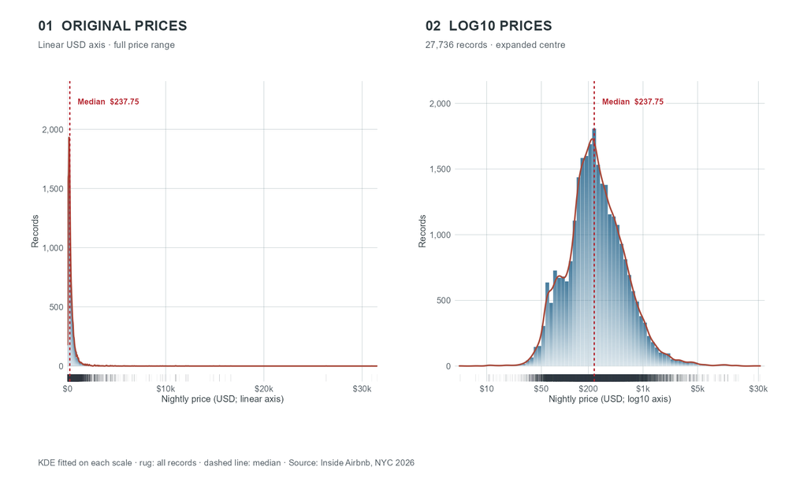

27,736 条有效正价记录的原价与对数分布、KDE 及 rug；两图中位数参考线均为 237.75 美元／夜，此时尚未按 ID 汇总或筛选 P5–P95。

**查看并复制原价与对数分布 R 代码**

接续 `positive_rows` 与研究区定位图代码中的配色和画布函数。本面板定义分布图函数并直接显示。

接续2.2的有效正价记录与共用主题。以下按“计数—密度—子图—拼图”分段，保留原价与对数尺度各自的组距和KDE估计。

**模块 1：选择配色并接续有效报价。** 先完成2.2的研究区代码与数据读取，得到 `positive_rows`、`figure_mode`、`topic1_price_tutorial_style()` 和 `topic1_price_canvas_theme()`。以下代码依次运行；每条有效报价仍作为一条记录。

```r
topic1_price_distribution_style <- function(mode) {
  styles <- list(
    light = list(bar = "#A9BED0", keep = "#326E92", fence = "#B4232D",
      band = "#87C8D0", kde = "#A74839", bar_bottom_alpha = .18, bar_top_alpha = .90),
    dark = list(bar = "#3D5770", keep = "#62C8D4", fence = "#FFD16C",
      band = "#2A8D9D", kde = "#F5B86D", bar_bottom_alpha = .16, bar_top_alpha = .95))
  topic1_price_tutorial_style(styles[[mode]], mode)
}

positive <- positive_rows
record_count <- nrow(positive)
median_usd <- median(positive$price_usd)
```

**模块 2：计算两种尺度的直方图。** 原价使用25美元组距，对数使用0.05组距；得到 `raw_bars` 与 `log_bars`，其中 `records` 是各组记录数。

```r
# 原价直方图：0起、组距25美元的左闭区间。
raw_top <- ceiling(max(positive$price_usd) / 25) * 25
raw_hist <- graphics::hist(positive$price_usd,
  breaks = seq(0, raw_top, by = 25), right = FALSE, include.lowest = TRUE, plot = FALSE)
raw_bars <- data.frame(xmin = head(raw_hist$breaks, -1),
  xmax = tail(raw_hist$breaks, -1), records = raw_hist$counts)

# 对数直方图：log10尺度、组距0.05。
log_prices <- log10(positive$price_usd)
log_breaks <- seq(floor(min(log_prices) * 20) / 20,
  ceiling(max(log_prices) * 20) / 20, by = .05)
log_hist <- graphics::hist(log_prices, breaks = log_breaks, plot = FALSE)
log_bars <- data.frame(xmin = head(log_hist$breaks, -1),
  xmax = tail(log_hist$breaks, -1), records = log_hist$counts)
```

**模块 3：估计密度曲线并换算为频数。** 原价在零点做反射，避免密度外溢到负价；对数密度在 `log10` 尺度单独估计。曲线乘以样本量和组距后可与直方图比较。

```r
# 原价做零点反射，log10尺度单独拟合，再换算到频数轴。
raw_density <- stats::density(c(positive$price_usd, -positive$price_usd),
  bw = stats::bw.nrd0(positive$price_usd), n = 16384, from = 0, to = raw_top)
raw_curve <- data.frame(x = raw_density$x, records = 2 * raw_density$y * record_count * 25)
log_density <- stats::density(log_prices, bw = "nrd0", n = 4096,
  from = min(log_breaks), to = max(log_breaks))
log_curve <- data.frame(x = log_density$x, records = log_density$y * record_count * .05)
raw_peak <- max(raw_bars$records, raw_curve$records)
log_peak <- max(log_bars$records, log_curve$records)
ink <- topic1_price_distribution_style(figure_mode)
```

**模块 4：定义渐变柱与金额标签。** 渐变只改变同一柱体的透明度；金额超过1000美元时用 `k` 缩写。两个短函数供下方子图调用。

```r
# 柱体填充：同一颜色由低至高的透明度渐变。
topic1_price_bar_gradient <- function(theme) {
  grid::linearGradient(
    colours = scales::alpha(theme$keep,
      c(theme$bar_bottom_alpha, theme$bar_top_alpha)),
    stops = c(0, 1), x1 = 0.5, y1 = 0, x2 = 0.5, y2 = 1, group = FALSE)
}

# 金额刻度：1000美元以上缩写为k。
topic1_price_money <- function(x) {
  vapply(x, function(value) {
    if (is.na(value)) return(NA_character_)
    if (value == 0) return("$0")
    if (value >= 1000) {
      return(paste0("$", format(value / 1000, trim = TRUE, scientific = FALSE), "k"))
    }
    paste0("$", format(value, trim = TRUE, scientific = FALSE))
  }, character(1))
}
```

**模块 5：统一两幅子图的文字和网格。** 透明外画布便于适配教材浅深背景；坐标、网格与留白使用同一套参数。

```r
# 两幅子图共用的坐标与文字样式。
topic1_price_chart_theme <- function(theme) {
  ggplot2::theme_minimal(base_family = "sans", base_size = 12) +
    ggplot2::theme(
      panel.background = ggplot2::element_rect(fill = "transparent", colour = NA),
      plot.background = ggplot2::element_rect(fill = "transparent", colour = NA),
      panel.grid.major = ggplot2::element_line(
        colour = scales::alpha(theme$grid, 0.48), linewidth = 0.26),
      panel.grid.minor = ggplot2::element_blank(),
      axis.title = ggplot2::element_text(colour = theme$text, size = 12),
      axis.text = ggplot2::element_text(colour = theme$muted, size = 11.5),
      plot.margin = ggplot2::margin(3, 8, 7, 4))
}
```

**模块 6：绘制原价分布。** 得到 `raw_plot`；依次叠加渐变柱、KDE、底部记录短线和美元中位数。

```r
raw_plot <- ggplot2::ggplot(raw_bars) +
  ggplot2::geom_rect(ggplot2::aes(xmin = xmin, xmax = xmax, ymin = 0, ymax = records),
    fill = topic1_price_bar_gradient(ink), colour = NA) +
  ggplot2::geom_line(data = raw_curve, ggplot2::aes(x = x, y = records),
    colour = ink$kde, linewidth = 0.95, lineend = "round") +
  ggplot2::geom_rug(data = positive, inherit.aes = FALSE,
    ggplot2::aes(x = price_usd), sides = "b", length = grid::unit(0.024, "npc"),
    colour = ink$text, alpha = 0.12, linewidth = 0.2) +
  ggplot2::geom_vline(xintercept = median_usd, colour = ink$fence,
    linetype = "22", linewidth = 0.82) +
  ggplot2::annotate("label", x = median_usd, y = raw_peak * 1.115,
    label = sprintf("Median  $%.2f", median_usd), hjust = -0.08, vjust = 0.5,
    colour = ink$fence, fill = ink$paper, linewidth = 0, size = 3.8,
    fontface = "bold") +
  ggplot2::scale_x_continuous(limits = c(0, raw_top),
    breaks = scales::breaks_pretty(n = 4), labels = topic1_price_money,
    expand = ggplot2::expansion(mult = c(0, 0))) +
  ggplot2::scale_y_continuous(labels = scales::label_comma(),
    breaks = scales::breaks_pretty(n = 4),
    expand = ggplot2::expansion(mult = c(0, 0))) +
  ggplot2::coord_cartesian(ylim = c(-raw_peak * 0.065, raw_peak * 1.2)) +
  ggplot2::labs(x = "Nightly price (USD; linear axis)", y = "Records") +
  topic1_price_chart_theme(ink)
```

**模块 7：绘制对数分布。** 得到 `log_plot`；横轴在对数尺度展开，刻度仍显示美元。虚线与原价图使用同一个美元中位数。

```r
log_plot <- ggplot2::ggplot(log_bars) +
  ggplot2::geom_rect(ggplot2::aes(xmin = xmin, xmax = xmax, ymin = 0, ymax = records),
    fill = topic1_price_bar_gradient(ink), colour = ink$paper, linewidth = 0.08) +
  ggplot2::geom_line(data = log_curve, ggplot2::aes(x = x, y = records),
    colour = ink$kde, linewidth = 0.95, lineend = "round") +
  ggplot2::geom_rug(data = positive, inherit.aes = FALSE,
    ggplot2::aes(x = log10(price_usd)), sides = "b",
    length = grid::unit(0.024, "npc"), colour = ink$text,
    alpha = 0.1, linewidth = 0.2) +
  ggplot2::geom_vline(xintercept = log10(median_usd), colour = ink$fence,
    linetype = "22", linewidth = 0.82) +
  ggplot2::annotate("label", x = log10(median_usd), y = log_peak * 1.115,
    label = sprintf("Median  $%.2f", median_usd), hjust = -0.08, vjust = 0.5,
    colour = ink$fence, fill = ink$paper, linewidth = 0, size = 3.8,
    fontface = "bold") +
  ggplot2::scale_x_continuous(breaks = log10(c(10, 50, 200, 1000, 5000, 30000)),
    labels = c("$10", "$50", "$200", "$1k", "$5k", "$30k"),
    expand = ggplot2::expansion(mult = c(0.015, 0.015))) +
  ggplot2::scale_y_continuous(labels = scales::label_comma(),
    breaks = scales::breaks_pretty(n = 4),
    expand = ggplot2::expansion(mult = c(0, 0))) +
  ggplot2::coord_cartesian(ylim = c(-log_peak * 0.065, log_peak * 1.2)) +
  ggplot2::labs(x = "Nightly price (USD; log10 axis)", y = "Records") +
  topic1_price_chart_theme(ink)
```

**模块 8：直接显示两图组合。** 将两个子图与标题、来源说明拼为 `price_pair`；最后一行在Plots面板显示结果。

```r
# 拼图时统一文字度量设备，结束后恢复。
previous_device <- cowplot::set_null_device("agg")
price_pair <- cowplot::ggdraw() +
  cowplot::draw_plot(raw_plot,
    x = 0.035, y = 0.17, width = 0.44, height = 0.67) +
  cowplot::draw_plot(log_plot,
    x = 0.515, y = 0.17, width = 0.44, height = 0.67) +
  cowplot::draw_label("01  ORIGINAL PRICES", x = 0.047, y = 0.948,
    hjust = 0, vjust = 0.5, size = 19, fontface = "bold", colour = ink$text) +
  cowplot::draw_label("Linear USD axis · full price range", x = 0.047, y = 0.91,
    hjust = 0, vjust = 0.5, size = 12.5, colour = ink$muted) +
  cowplot::draw_label("02  LOG10 PRICES", x = 0.527, y = 0.948,
    hjust = 0, vjust = 0.5, size = 19, fontface = "bold", colour = ink$text) +
  cowplot::draw_label(paste0(scales::comma(record_count), " records · expanded centre"),
    x = 0.527, y = 0.91, hjust = 0, vjust = 0.5, size = 12.5, colour = ink$muted) +
  cowplot::draw_label("KDE fitted on each scale · rug: all records · dashed line: median · Source: Inside Airbnb, NYC 2026",
    x = 0.047, y = 0.062, hjust = 0, vjust = 0.5, size = 11.5, colour = ink$muted) +
  ggplot2::theme(plot.background = ggplot2::element_rect(fill = "transparent", colour = NA)) + topic1_price_canvas_theme()
invisible(cowplot::set_null_device(previous_device))
price_pair
```

房源均价与分位筛选

**按房源 ID 求均价。** 对 27,736 条有效正价记录按 `id` 分组，计算各房源已观测报价的算术平均，得到 **11,853 个房源均价**。每个 ID 无论出现一、二还是三期，都使用同一个 `mean()` 规则；未观测批次不补零，不同 ID 即使坐标相同也分别保留。均价可平滑部分已观测报价波动，仍会受到入住条件与季节差异的影响。

**在房源均价层筛选 P5–P95。** 对 11,853 个均价计算第 5 与第 95 百分位，得到 **63.96–1,000 美元／夜**的保留区间。分位点采用 R 默认的 `type = 7`，筛选直接使用 `quantile()` 返回的完整精度值，并包含上下界。均价低于 P5 和高于 P95 的房源各有 **592 个**，最终保留 **10,669 个房源 ID**。每个 ID 只贡献一个均价，不会因出现批次较多而在分位数计算中重复计权。

| 处理阶段 | 统计单位 | 保留数量 |
| --- | --- | --- |
| 主岛内原始记录 | 房源—批次记录 | 43,589 |
| 有效正价记录 | 房源—批次记录 | 27,736 |
| 按 ID 求均价 | 不同房源 ID | 11,853 |
| 均价 P5–P95 筛选后 | 不同房源 ID | 10,669 |

**查看并复制同 ID 均价与 P5–P95 筛选 R 代码**

**模块 7：ID 检查与代表报价**

按 `id` 求有效报价的均值，得到每个房源唯一的 `listing_mean_all`，并保留最新有效坐标。

```r
# 模块 7：按房源 ID 汇总全部有效正价，计算原始美元每夜报价的均值。
# 单期、两期和三期均使用同一规则；未出现的批次不补零。
listing_mean_all <- positive_rows %>%
  arrange(id, snapshot) %>%
  group_by(id) %>%
  summarise(longitude = dplyr::last(longitude),
            latitude = dplyr::last(latitude),
            listing_mean_usd = mean(price_usd),
            n_releases = n_distinct(snapshot),
            n_records = n(), .groups = "drop")
```

**模块 8：均价分位筛选**

在美元均价上计算完整精度的 P5、P95，得到包含上下界的入选表 `listing_clean`。

```r
# 模块 8：每个 ID 贡献一个均价；在均价层计算 P5–P95，包含上下界。
# 分位点使用完整精度；显示时的四舍五入不参与筛选。
price_bounds <- quantile(listing_mean_all$listing_mean_usd,
                         probs = c(0.05, 0.95), type = 7)
price_lower <- unname(price_bounds[1])
price_upper <- unname(price_bounds[2])
listing_clean <- listing_mean_all %>%
  filter(listing_mean_usd >= price_lower,
         listing_mean_usd <= price_upper)
```

**模块 9：阶段数量核对**

输出各阶段的记录数或房源 ID 数，核对统计单位的变化。

```r
# 模块 9：按处理阶段报告数量，并明确记录与房源 ID 的单位变化。
data.frame(
  stage = c("主岛内原始记录", "有效正价记录", "按 ID 求均价",
            "均价 P5–P95 筛选后"),
  unit = c("房源—批次记录", "房源—批次记录", "不同房源 ID", "不同房源 ID"),
  count = c(nrow(main_island_rows), nrow(positive_rows),
            nrow(listing_mean_all), nrow(listing_clean))
) %>% knitr::kable(col.names = c("处理阶段", "统计单位", "保留数量"),
                   format.args = list(big.mark = ","))
```

筛选后的房源分布

地图展示 P5–P95 保留的 **10,669 个房源 ID**。每个点代表一个 ID 的已观测均价，位置取该 ID 最新一条有效正价记录的公开坐标。坐标经过匿名化，不能解释为精确地址；不同 ID 共用坐标时，点位可能重叠。

右侧直方图展示全部 **11,853 个 ID 均价**。P5–P95 内的部分沿用地图的 Fisher 七级颜色；低于 P5 和高于 P95 的两端各有 **592 个 ID**，以灰色表示。Fisher 断点仍由筛选后的均价在 `log10` 尺度上计算，图例以美元／夜表示。

直方图的 KDE 与 rug 均使用全部 **11,853 个均价**。KDE 在 `log10` 尺度上估计，并按样本量与组距缩放到频数轴；rug 标出每个 ID 均价的位置。这里的 KDE 描述**一维价格分布**，其高度不表示原美元尺度上的概率密度；专题研究 2 将学习位置空间中的核密度。

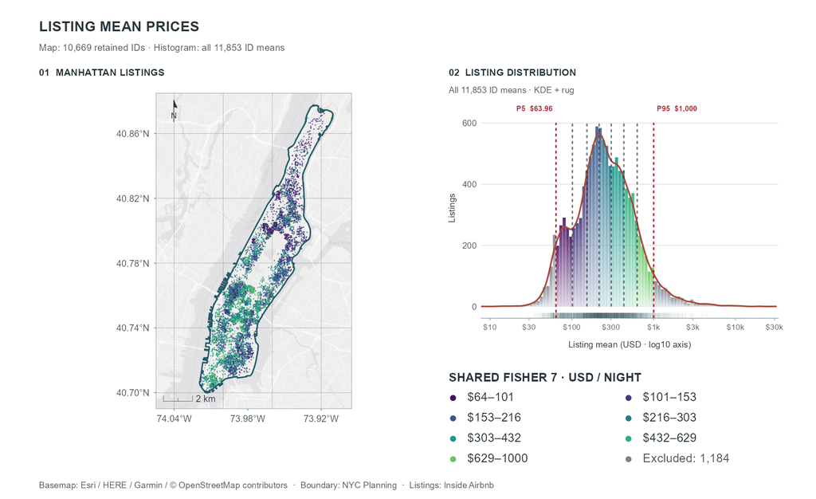

地图展示 10,669 个保留 ID；直方图展示全部 11,853 个 ID 均价，彩色部分与地图共用 Fisher 七级色阶，灰色两端各为 592 个剔除 ID。

**查看并复制房源点图与均价分布 R 代码**

先运行房源均价与 P5–P95 筛选代码，得到 `listing_mean_all`、`listing_clean` 和 `price_bounds`；主题与底图函数见研究区定位图代码。本面板定义组合图函数并直接显示。

接续上方房源均价与筛选结果。以下逐步建立点位地图、包含两端尾部的分布图及共同图例，显示与正文一致的组合结果。

**模块 1：接续筛选结果与主题。** 先运行2.2研究区代码，以及本节的房源均价和P5–P95筛选代码；须已有 `listing_mean_all`、`listing_clean`、`price_bounds`、`main_island` 和 `figure_mode`。以下保留全部均价用于分布图，仅将入选ID绘在地图上。

```r
topic1_price_listing_style <- function(mode) {
  styles <- list(
    light = list(bar = "#A9BED0", bar_selected = "#326E92", kde = "#A74839",
      fence = "#B4232D", band = "#87C8D0",
      colours = unname(viridisLite::viridis(7, begin = .04, end = .76)),
      point_alpha = .81, halo_alpha = 0, bar_bottom_alpha = .18,
      bar_top_alpha = .90, rug_alpha = .035, excluded = "#7B8490"),
    dark = list(bar = "#3D5770", bar_selected = "#62C8D4", kde = "#F5B86D",
      fence = "#FFD16C", band = "#2A8D9D",
      colours = c("#AB9AF5", "#83A9F5", "#63C5E8", "#60DBCB", "#A7E38F", "#F4D773", "#FFAB70"),
      point_alpha = .82, halo_alpha = .1, bar_bottom_alpha = .16,
      bar_top_alpha = .95, rug_alpha = .025, excluded = "#ADB6C2"))
  topic1_price_tutorial_style(styles[[mode]], mode)
}

mode <- figure_mode
context <- topic1_price_map_context(main_island)
main_island <- context$main_island
graticule <- context$graticule
x_limits <- context$x_limits
y_limits <- context$y_limits
bounds <- unname(price_bounds)
listing_price <- listing_clean
```

**模块 2：建立地图与直方图共用的类别。** 由入选房源均价计算Fisher七级，再按ID连回全部均价。低于P5、高于P95的房源分别保留为两个尾部类别。

```r
# 入选均价决定Fisher七级；地图与直方图共用这套类别标签。
edges <- 10^withr::with_seed(20261024,
  classInt::classIntervals(log10(listing_price$listing_mean_usd), n = 7,
    style = "fisher", largeN = 30000L)$brks)
labels <- sprintf("$%.0f–%.0f", head(edges, -1), tail(edges, -1))
listing_price$price_class <- cut(listing_price$listing_mean_usd,
  breaks = c(-Inf, edges[2:7], Inf), labels = labels)

# ID真类别连回全部均价，两个剔除尾部也参与直方图、KDE和rug。
histogram_price <- listing_mean_all
histogram_levels <- c("Below P5", labels, "Above P95")
retained_index <- match(histogram_price$id, listing_price$id)
histogram_price$histogram_class <- ifelse(
  histogram_price$listing_mean_usd < bounds[1], "Below P5",
  ifelse(histogram_price$listing_mean_usd > bounds[2], "Above P95",
    as.character(listing_price$price_class[retained_index])))
histogram_price$histogram_class <- factor(histogram_price$histogram_class,
  levels = histogram_levels)
```

**模块 3：准备点位与说明文字。** 每个入选ID使用一个代表位置；局部种子只固定叠点顺序，不改变后续分析的随机状态。得到 `points` 与图例标签。

```r
point_rows <- withr::with_seed(20261024, listing_price[sample.int(nrow(listing_price)), ])
points <- sf::st_as_sf(point_rows, coords = c("longitude", "latitude"), crs = 4326)
ink <- topic1_price_listing_style(mode)
threshold_labels <- paste(c("P5 ", "P95 "),
  sub("\\.00$", "", scales::dollar(bounds, accuracy = .01)))
panel_subtitle <- paste0("Map: ", scales::comma(nrow(listing_price)),
  " retained IDs · Histogram: all ", scales::comma(nrow(histogram_price)), " ID means")
histogram_subtitle <- paste0("All ", scales::comma(nrow(histogram_price)),
  " ID means · KDE + rug")
excluded_label <- paste0("Excluded: ", scales::comma(sum(is.na(retained_index))))
```

**模块 4：绘制地图底图、房源点与边界。** 沿用2.2的地图范围与底图函数。`map_plot`共用七级色阶，并标出经纬度；深色主题增加轻微点位光晕。

```r
palette <- stats::setNames(ink$colours, labels)
map_plot <- ggplot2::ggplot() +
  topic1_tutorial_basemap_layers(mode) +
  ggplot2::geom_sf(data = graticule, colour = ink$grid, linewidth = 0.33, alpha = 0.52) +
  ggplot2::geom_sf(data = main_island, fill = ink$land, colour = NA,
    alpha = if (ink$halo_alpha > 0) 0.04 else 0.08)
if (ink$halo_alpha > 0) {
  map_plot <- map_plot + ggplot2::geom_sf(data = points, ggplot2::aes(colour = price_class),
    shape = 16, size = 2.25, alpha = ink$halo_alpha, stroke = 0, show.legend = FALSE)
}
map_plot <- map_plot +
  ggplot2::geom_sf(data = points, ggplot2::aes(colour = price_class), shape = 16,
    size = if (ink$halo_alpha > 0) 0.74 else 0.82,
    alpha = ink$point_alpha, stroke = 0) +
  ggplot2::geom_sf(data = main_island, fill = NA, colour = ink$boundary,
    linewidth = 0.9) +
  ggplot2::scale_colour_manual(values = palette, limits = labels, drop = FALSE,
    guide = "none") +
  ggplot2::scale_x_continuous(breaks = c(-74.04, -73.98, -73.92),
    labels = function(x) sprintf("%.2f°W", abs(x))) +
  ggplot2::scale_y_continuous(breaks = seq(40.7, 40.86, by = 0.04),
    labels = function(y) sprintf("%.2f°N", y)) +
  ggplot2::coord_sf(crs = sf::st_crs(4326), default_crs = sf::st_crs(4326),
    datum = sf::st_crs(4326), xlim = x_limits, ylim = y_limits, expand = FALSE)
```

**模块 5：加入地图要素与文字样式。** 加入比例尺、真北指示和面板边界，统一拼图中的字号与边距。

```r
map_plot <- map_plot +
  ggspatial::annotation_scale(location = "bl", width_hint = 0.18, style = "ticks",
    unit_category = "metric", line_col = ink$scale, text_col = ink$scale,
    line_width = 0.55, text_cex = 1,
    pad_x = grid::unit(0.14, "in"), pad_y = grid::unit(0.14, "in")) +
  ggspatial::annotation_north_arrow(location = "tl", which_north = "true",
    height = grid::unit(0.4, "in"), width = grid::unit(0.4, "in"),
    pad_x = grid::unit(0.13, "in"), pad_y = grid::unit(0.13, "in"),
    style = ggspatial::north_arrow_minimal(line_col = ink$scale, fill = ink$scale,
      text_col = ink$scale, text_size = 11)) +
  ggplot2::theme_minimal(base_family = "sans", base_size = 14) +
  ggplot2::theme(
    panel.background = ggplot2::element_rect(fill = ink$water, colour = NA),
    plot.background = ggplot2::element_rect(fill = "transparent", colour = NA),
    panel.grid = ggplot2::element_blank(),
    panel.border = ggplot2::element_rect(fill = NA, colour = ink$grid, linewidth = 0.45),
    axis.title = ggplot2::element_blank(),
    axis.text = ggplot2::element_text(colour = ink$muted, size = 13),
    axis.ticks = ggplot2::element_line(colour = ink$muted, linewidth = 0.35),
    axis.ticks.length = grid::unit(2.2, "pt"),
    legend.position = "none", plot.margin = ggplot2::margin(6, 7, 8, 7))
# 拼图中的地图字号与边距。
map_plot <- map_plot +
  ggplot2::theme(axis.text = ggplot2::element_text(colour = ink$muted, size = 12),
    plot.margin = ggplot2::margin(1, 2, 4, 1))
```

**模块 6：计算堆叠直方图的各段位置。** 全部房源均价按0.04组距计数；`ggplot_build()`提供各类别矩形段的上下边界，供分段渐变使用。

```r
palette <- stats::setNames(c(ink$excluded, ink$colours, ink$excluded), histogram_levels)
original <- ggplot2::ggplot(histogram_price,
  ggplot2::aes(x = log10(listing_mean_usd), fill = histogram_class)) +
  ggplot2::geom_histogram(binwidth = 0.04, boundary = log10(edges[[1]]),
    position = "stack", closed = "left") +
  ggplot2::scale_fill_manual(values = palette, limits = histogram_levels, drop = FALSE)
segments <- ggplot2::ggplot_build(original)$data[[1]]
segments$histogram_class <- histogram_levels[segments$group]
segments$class_index <- match(segments$histogram_class, labels)
segments$bin_height <- ave(segments$ymax, segments$x, FUN = max)
segments <- segments[segments$count > 0, ]
alpha_range <- ink$bar_top_alpha - ink$bar_bottom_alpha
segments$alpha_bottom <- ink$bar_bottom_alpha + alpha_range * segments$ymin / segments$bin_height
segments$alpha_top <- ink$bar_bottom_alpha + alpha_range * segments$ymax / segments$bin_height
```

**模块 7：准备渐变填充和KDE。** 每个矩形段按其所在柱体的高度设置透明度。KDE使用全部均价，并乘以样本量和0.04组距，换算为频数。

```r
gradient_fills <- lapply(seq_len(nrow(segments)), function(i) {
  grid::linearGradient(
    colours = scales::alpha(segments$fill[[i]],
      c(segments$alpha_bottom[[i]], segments$alpha_top[[i]])),
    stops = c(0, 1), x1 = 0.5, y1 = 0, x2 = 0.5, y2 = 1, group = FALSE)
})
cut_positions <- log10(edges)
log_prices <- log10(histogram_price$listing_mean_usd)
kde <- stats::density(log_prices, bw = "nrd0", n = 1024,
  from = min(log_prices), to = max(log_prices))
kde <- data.frame(price_log10 = kde$x, listings = kde$y * nrow(histogram_price) * 0.04)
peak <- max(segments$bin_height, kde$listings)
```

**模块 8：绘制直方图与筛选参考线。** 得到 `hist_plot`的主要图层：分段渐变柱、KDE、记录短线、Fisher分界线及P5/P95标记。

```r
hist_plot <- ggplot2::ggplot() +
  ggplot2::geom_rect(data = segments,
    ggplot2::aes(xmin = xmin, xmax = xmax, ymin = ymin, ymax = ymax),
    fill = gradient_fills, colour = ink$paper, linewidth = 0.13) +
  ggplot2::geom_line(data = kde, inherit.aes = FALSE,
    ggplot2::aes(x = price_log10, y = listings), colour = ink$kde,
    linewidth = 0.98, lineend = "round") +
  ggplot2::geom_rug(data = histogram_price, inherit.aes = FALSE,
    ggplot2::aes(x = log10(listing_mean_usd)), sides = "b",
    length = grid::unit(0.024, "npc"), colour = ink$text,
    alpha = ink$rug_alpha, linewidth = 0.14) +
  ggplot2::annotate("segment", x = cut_positions[2:7], xend = cut_positions[2:7],
    y = 0, yend = peak * 1.02, colour = ink$text, linewidth = 0.9,
    linetype = "22", alpha = 0.65) +
  ggplot2::annotate("segment", x = log10(bounds), xend = log10(bounds),
    y = -peak * 0.065, yend = peak * 1.02, colour = ink$fence,
    linewidth = 0.88, linetype = "22") +
  ggplot2::annotate("label", x = log10(bounds), y = peak * 1.1,
    label = threshold_labels, hjust = c(1.04, -0.04), vjust = 0.5,
    colour = ink$fence, fill = ink$paper, linewidth = 0,
    label.padding = grid::unit(2, "pt"), fontface = "bold", size = 3.5)
```

**模块 9：配置分布图坐标与主题。** 横轴在对数尺度展开但仍以美元标注；保留两端剔除房源的分布信息。

```r
hist_plot <- hist_plot +
  ggplot2::scale_x_continuous(
    breaks = log10(c(10, 30, 100, 300, 1000, 3000, 10000, 30000)),
    labels = c("$10", "$30", "$100", "$300", "$1k", "$3k", "$10k", "$30k"),
    expand = ggplot2::expansion(mult = c(0, 0))) +
  ggplot2::scale_y_continuous(labels = scales::label_comma(),
    expand = ggplot2::expansion(mult = c(0, 0))) +
  ggplot2::coord_cartesian(xlim = range(c(segments$xmin, segments$xmax)),
    ylim = c(-peak * 0.065, peak * 1.16), clip = "on") +
  ggplot2::labs(x = "Listing mean (USD · log10 axis)", y = "Listings") +
  ggplot2::theme_minimal(base_family = "sans", base_size = 12) +
  ggplot2::theme(
    panel.background = ggplot2::element_rect(fill = "transparent", colour = NA),
    plot.background = ggplot2::element_rect(fill = "transparent", colour = NA),
    panel.grid.major.y = ggplot2::element_line(
      colour = scales::alpha(ink$grid, 0.45), linewidth = 0.26),
    panel.grid.major.x = ggplot2::element_blank(),
    panel.grid.minor = ggplot2::element_blank(),
    axis.line.x = ggplot2::element_line(colour = ink$grid, linewidth = 0.35),
    axis.ticks.x = ggplot2::element_line(colour = ink$grid, linewidth = 0.35),
    axis.ticks.length.x = grid::unit(3, "pt"),
    axis.text.x = ggplot2::element_text(colour = ink$muted, size = 10.7,
      margin = ggplot2::margin(t = 5)),
    axis.text.y = ggplot2::element_text(colour = ink$muted, size = 11.4),
    axis.title = ggplot2::element_text(colour = ink$text, size = 11.5),
    axis.title.x = ggplot2::element_text(margin = ggplot2::margin(t = 12)),
    axis.title.y = ggplot2::element_text(margin = ggplot2::margin(r = 8)),
    plot.margin = ggplot2::margin(7, 14, 7, 8))
```

**模块 10：排列地图与分布图。** 地图放左侧、全部均价的分布图放右侧，标题明确两图的统计对象与数量。

```r
# 拼图时统一文字度量设备，结束后恢复。
previous_device <- cowplot::set_null_device("agg")
panel <- cowplot::ggdraw() +
  cowplot::draw_plot(map_plot, x = -0.04, y = 0.145, width = 0.655, height = 0.67) +
  cowplot::draw_plot(hist_plot, x = 0.542, y = 0.29, width = 0.425, height = 0.525) +
  cowplot::draw_label("LISTING MEAN PRICES", x = 0.048, y = 0.947,
    hjust = 0, vjust = 0.5, colour = ink$text, fontface = "bold", size = 19) +
  cowplot::draw_label(panel_subtitle, x = 0.048, y = 0.905,
    hjust = 0, vjust = 0.5, colour = ink$muted, size = 12.5) +
  cowplot::draw_label("01  MANHATTAN LISTINGS", x = 0.048, y = 0.855,
    hjust = 0, vjust = 0.5, colour = ink$text, fontface = "bold", size = 13) +
  cowplot::draw_label("02  LISTING DISTRIBUTION", x = 0.55, y = 0.855,
    hjust = 0, vjust = 0.5, colour = ink$text, fontface = "bold", size = 13) +
  cowplot::draw_label(histogram_subtitle, x = 0.55, y = 0.82,
    hjust = 0, vjust = 0.5, colour = ink$muted, size = 11.5) +
  cowplot::draw_label("SHARED FISHER 7 · USD / NIGHT", x = 0.55, y = 0.244,
    hjust = 0, vjust = 0.5, colour = ink$text, fontface = "bold", size = 16)
```

**模块 11：加入共同图例并直接显示。** 七级金额标签同时对应地图与直方图；尾部剔除房源使用中性灰。最后的 `listing_panel`显示完整组合图。

```r
for (i in seq_along(labels)) {
  item_x <- 0.55 + ((i - 1) %% 2) * 0.215
  item_y <- 0.205 - ((i - 1) %/% 2) * 0.041
  panel <- panel +
    cowplot::draw_label("●", x = item_x, y = item_y, hjust = 0, vjust = 0.5,
      colour = ink$colours[[i]], size = 19) +
    cowplot::draw_label(labels[[i]], x = item_x + 0.023, y = item_y,
      hjust = 0, vjust = 0.5, colour = ink$text, size = 16)
}
listing_panel <- panel +
  cowplot::draw_label("●", x = 0.765, y = 0.082, hjust = 0, vjust = 0.5,
    colour = ink$excluded, size = 19) +
  cowplot::draw_label(excluded_label, x = 0.788, y = 0.082, hjust = 0, vjust = 0.5,
    colour = ink$muted, size = 16) +
  cowplot::draw_label("Basemap: Esri / HERE / Garmin / © OpenStreetMap contributors  ·  Boundary: NYC Planning  ·  Listings: Inside Airbnb",
    x = 0.048, y = 0.028, hjust = 0, vjust = 0.5, colour = ink$muted, size = 11.5) +
  ggplot2::theme(plot.background = ggplot2::element_rect(fill = "transparent", colour = NA)) + topic1_price_canvas_theme()
invisible(cowplot::set_null_device(previous_device))
listing_panel
```

结果解读

27,736 条有效正价记录呈右偏长尾，中位数为 **237.75 美元／夜**，少量高价记录将右尾拉长。按 ID 求均价并筛选 P5–P95 后，样本包含 10,669 个房源，其已观测均价处于 **63.96–1,000 美元／夜**。后续将结合六边形聚合，继续比较报价的空间差异。

初步分布图以**房源—批次记录**为单位，组合图中的地图与均价直方图以**房源 ID**为单位。ID 均价概括已观测批次的报价，仍受入住条件、季节差异与房源出现批次的影响。

**© 华东师范大学 社会发展学院 人口研究所** | [**DAWN 研究组**](https://dawn-ecnu.github.io) | yzliu@soci.ecnu.edu.cn

课程负责人：刘贇喆 本章作者：刘贇喆 | 敖漪宇

最后更新：2026年11月13日 构建环境：R version 4.6.1 (2026-06-24 ucrt)

[CC BY-NC-SA 4.0](https://creativecommons.org/licenses/by-nc-sa/4.0/deed.zh) 回到顶部

##### 网格化与聚合

###### **2.4 六边形网格与中位报价**

逐点设色存在点位叠压，难以直接比较区域的典型报价。本节将 2.3 节保留的 **10,669 个房源 ID** 归入固定面积网格：每个 ID 携带一个已观测均价和最新有效正价记录的公开坐标，同坐标的不同 ID 分别参与汇总。

本例采用面积 **$0.10\text{ km}^2$**、边长约 **196 m** 的完整正六边形，并要求每格至少包含 **5 个不同 ID**，再计算格内房源均价的中位数。面积、网格起点与 ID 门槛都是需要说明的分析设定，可通过改变设定比较结果。

距离与面积计算使用 **EPSG:2263**，其单位为**美国测量英尺**，按 $1\text{ m}=3937/1200\text{ ft}$ 换算。`st_make_grid()` 的六边形 `cellsize` 是对边距离，本例约为 **339.8 m**。统计使用与主岛相交的**完整格**；地图才将格网裁切到主岛边界，并在 EPSG:4326 下显示。

与主岛相交的 **653 格**中，**365 格**至少包含 5 个不同 ID；其余 **288 格**不计算中位报价，不以 0 补值。`n_coordinates` 记录不同公开坐标数，帮助检查空间覆盖，但不作为纳入门槛。`listing_members` 保留每个入选 ID 的报价与格编号，可用于后续样本支持诊断。

下图左侧显示这 365 格的中位报价，右侧直方图、KDE 与 rug 展示同一批格的数值分布。Fisher 七级仅用于设色，后续 Moran 与 LISA 使用**未分级、未取对数的美元中位报价**。

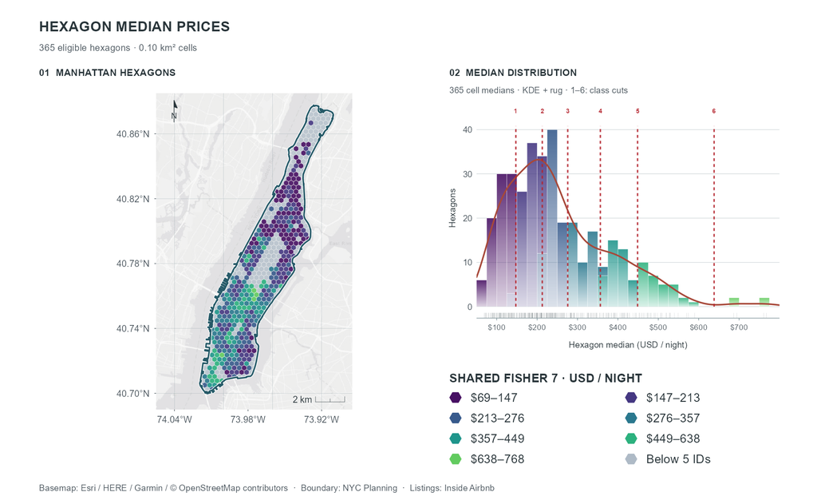

0.10 km² 完整六边形的中位报价：365 格至少包含5个不同房源ID；288格不足门槛，价格不补零。地图与直方图共用Fisher七级色阶。

**查看并复制六边形网格分析 R 代码**

**分析 1：建立完整六边形。** 换算目标面积并固定网格起点，得到与主岛相交的 `hex_grid`；格编号在筛选前确定。

```r
# 1. 将目标面积换算为 EPSG:2263 使用的美国测量英尺。
main_island_2263 <- st_transform(main_island, 2263)
target_area_m2 <- 100000
feet_per_metre <- 3937 / 1200
cellsize_ft <- sqrt(2 * target_area_m2 / sqrt(3)) * feet_per_metre

# 沿用主岛外包框起点，先编号，再保留与主岛相交的完整格。
grid_origin_ft <- unname(st_bbox(main_island_2263)[c("xmin", "ymin")])
hex_grid <- st_make_grid(main_island_2263,
                         cellsize = cellsize_ft,
                         offset = grid_origin_ft,
                         square = FALSE) %>%
  st_sf() %>%
  mutate(hex_id = row_number()) %>%
  st_filter(main_island_2263, .predicate = st_intersects)
```

**分析 2：将房源归入网格。** 在相同投影中确定每个 ID 所在的格，得到 `listing_members`；每个 ID 须且仅归属一格。

```r
# 2. 空间归属：每个 ID 只归入一个格，不按坐标删除房源。
listing_points_2263 <- st_as_sf(listing_clean,
  coords = c("longitude", "latitude"), crs = 4326,
  remove = FALSE) %>% st_transform(2263)
within_hits <- st_within(listing_points_2263, hex_grid)

# 每个 ID 须且仅归入一个格，避免重复计数或遗漏。
stopifnot(all(lengths(within_hits) == 1L))
listing_members <- listing_clean %>%
  mutate(hex_id = hex_grid$hex_id[
    vapply(within_hits, `[[`, integer(1), 1)])
```

**分析 3：计算支持数与中位报价。** 统计不同 ID 和坐标数，仅对至少包含 5 个 ID 的格求报价中位数，得到 `hex_support` 与 `hex_medians`。

```r
# 3. 先统计不同 ID 与坐标，再对达到 5 个 ID 的格计算中位报价。
hex_support <- listing_members %>%
  group_by(hex_id) %>%
  summarise(n_ids = n_distinct(id),
            n_coordinates = n_distinct(longitude, latitude),
            .groups = "drop")
hex_medians <- listing_members %>%
  semi_join(filter(hex_support, n_ids >= 5L), by = "hex_id") %>%
  group_by(hex_id) %>%
  summarise(median_usd = median(listing_mean_usd), .groups = "drop")
```

**分析 4：回连完整格网。** 得到全部格 `hex_all` 和达标格 `hex_eligible`；空格计数补 0，不足门槛的报价保留 `NA`。

```r
# 4. 回连全部完整格；空格的计数补 0，未达门槛的报价保留 NA。
hex_values <- left_join(hex_support, hex_medians, by = "hex_id")
hex_all <- hex_grid %>%
  left_join(hex_values, by = "hex_id") %>%
  mutate(n_ids = coalesce(n_ids, 0L),
         n_coordinates = coalesce(n_coordinates, 0L),
         eligible = n_ids >= 5L)
hex_eligible <- hex_all %>% filter(eligible) %>% arrange(hex_id)
```

**绘图前提。** 已得到 `hex_all`、`hex_eligible` 与 `main_island_2263`；沿用2.2的 `figure_mode`、浅深配色与底图函数。以下直接建立地图、直方图和组合图，不另定义大型绘图函数。

**制图 1：选择专题配色。** 小函数仅集中保存地图、直方图与后续LISA共用的浅深色参数。

```r
topic1_spatial_map_theme <- function(mode) {
  mode <- match.arg(mode, c("light", "dark"))
  themes <- list(
    light = list(
      missing = "#AEBAC6",
      fill_alpha = .91, kde = "#A74839", fence = "#B4232D",
      bar_bottom_alpha = .18, bar_top_alpha = .90,
      colours = c("#471063FF", "#453882FF", "#375A8CFF", "#2A788EFF",
                  "#1F958BFF", "#2CB17EFF", "#62CB5FFF"),
      quadrants = c(HH = "#B83F4D", LH = "#087D69", LL = "#2867A4", HL = "#7B4AA7"),
      neutrals = c(NS = "#959EAA", Isolate = "#D9E1E8", Below5 = "#D9E1E8"),
      line = "#956207"),
    dark = list(
      missing = "#485C70",
      fill_alpha = .91, kde = "#F5B86D", fence = "#FFD16C",
      bar_bottom_alpha = .16, bar_top_alpha = .95,
      colours = c("#AB9AF5", "#83A9F5", "#63C5E8", "#60DBCB",
                  "#A7E38F", "#F4D773", "#FFAB70"),
      quadrants = c(HH = "#FF9A94", LH = "#65D7BF", LL = "#8ABCF6", HL = "#C4A4F4"),
      neutrals = c(NS = "#96A7B8", Isolate = "#354A60", Below5 = "#354A60"),
      line = "#F6D380"))
  palette <- topic1_tutorial_palette(mode)
  c(themes[[mode]], list(
    mode = mode, background = palette$background, paper = palette$page,
    panel = palette$panel, text = palette$text, muted = palette$muted,
    grid = palette$grid, boundary = palette$boundary, halo = palette$halo,
    scale = palette$text, hex_line = palette$panel, zero = palette$muted))
}
```

**制图 2：定义地图背景层。** 复用2.2的底图，并在共同范围内叠加经纬网；后续LISA直接使用同一背景。

```r
topic1_spatial_map_background <- function(ink) {
  frame <- sf::st_as_sfc(sf::st_bbox(
    c(xmin = -74.055, ymin = 40.690, xmax = -73.895, ymax = 40.885),
    crs = sf::st_crs(4326)))
  graticule <- sf::st_graticule(frame, crs = sf::st_crs(4326),
    datum = sf::st_crs(4326), lon = seq(-74.04, -73.90, by = .04),
    lat = seq(40.70, 40.86, by = .04))
  c(topic1_tutorial_basemap_layers(
    ink$mode),
    list(ggplot2::geom_sf(data = graticule, colour = ink$grid,
      linewidth = .22, alpha = .36)))
}
```

**制图 3：定义地图要素层。** 主岛边界、经纬度刻度、真北指北针、比例尺与文字样式集中在一个短函数中。

```r
topic1_spatial_map_foreground <- function(ink, main_island, base_family) {
  list(
    ggplot2::geom_sf(data = main_island, fill = NA, colour = ink$halo, linewidth = 1.65),
    ggplot2::geom_sf(data = main_island, fill = NA, colour = ink$boundary, linewidth = .95),
    ggplot2::scale_x_continuous(breaks = c(-74.04, -73.98, -73.92),
      labels = function(x) sprintf("%.2f°W", abs(x))),
    ggplot2::scale_y_continuous(breaks = seq(40.70, 40.86, by = .04),
      labels = function(y) sprintf("%.2f°N", y)),
    ggplot2::coord_sf(crs = sf::st_crs(4326), default_crs = sf::st_crs(4326),
      datum = sf::st_crs(4326), xlim = c(-74.055, -73.895),
      ylim = c(40.690, 40.885), expand = FALSE),
    ggspatial::annotation_scale(location = "br", width_hint = .18, style = "ticks",
      unit_category = "metric", line_col = ink$scale, text_col = ink$scale,
      line_width = .55, text_cex = 1.0,
      pad_x = grid::unit(.14, "in"), pad_y = grid::unit(.14, "in")),
    ggspatial::annotation_north_arrow(location = "tl", which_north = "true",
      height = grid::unit(.40, "in"), width = grid::unit(.40, "in"),
      pad_x = grid::unit(.13, "in"), pad_y = grid::unit(.13, "in"),
      style = ggspatial::north_arrow_minimal(line_col = ink$scale, fill = ink$scale,
        text_col = ink$scale, text_size = 11)),
    ggplot2::theme_minimal(base_family = base_family, base_size = 14),
    ggplot2::theme(
      panel.background = ggplot2::element_rect(fill = ink$panel, colour = NA),
      plot.background = ggplot2::element_rect(fill = ink$background, colour = NA),
      panel.grid = ggplot2::element_blank(), panel.border = ggplot2::element_blank(),
      axis.title = ggplot2::element_blank(),
      axis.text = ggplot2::element_text(colour = ink$muted, size = 12),
      axis.ticks = ggplot2::element_line(colour = ink$muted, linewidth = .35),
      axis.ticks.length = grid::unit(2.2, "pt"),
      plot.margin = ggplot2::margin(1, 2, 4, 1)))
}
```

**制图 4：准备分级与显示几何。** Fisher断点由达标完整格计算。仅地图显示时裁切几何，格内统计值不重新计算。

```r
ink <- topic1_spatial_map_theme(figure_mode)
edges <- classInt::classIntervals(hex_eligible$median_usd, n = 7,
  style = "fisher", largeN = Inf)$brks
class_labels <- sprintf("$%.0f–%.0f", head(edges, -1), tail(edges, -1))
full_hex <- sf::st_transform(hex_all, 2263)
full_hex$price_class <- cut(full_hex$median_usd, c(-Inf, edges[2:7], Inf),
  labels = class_labels)
island_2263 <- sf::st_transform(main_island_2263, 2263)
# 裁切只改变显示几何，完整格中的计数与中位数直接沿用输入。
display_hex <- suppressWarnings(sf::st_intersection(full_hex,
  sf::st_geometry(island_2263)))
display_hex <- sf::st_transform(display_hex, 4326)
main_island <- sf::st_transform(island_2263, 4326)
```

**制图 5：逐层绘制网格地图。** 先画底图，再分别画不足门槛格与达标格，最后叠加轮廓及地图要素。

```r
# 左侧地图：不足5个ID的格作为背景，价格不补零。
map <- ggplot2::ggplot() +
  topic1_spatial_map_background(ink) +
  ggplot2::geom_sf(data = display_hex[!display_hex$eligible, ], fill = ink$missing,
    colour = ink$hex_line, linewidth = .16, alpha = .76) +
  ggplot2::geom_sf(data = display_hex[display_hex$eligible, ],
    ggplot2::aes(fill = price_class), colour = ink$hex_line,
    linewidth = .19, alpha = ink$fill_alpha) +
  ggplot2::scale_fill_manual(values = stats::setNames(ink$colours, class_labels),
    limits = class_labels, drop = FALSE, guide = "none") +
  topic1_spatial_map_foreground(ink, main_island, "sans")
```

**制图 6：准备直方图柱段。** 右图仍使用同一批达标格；箱宽为25美元，柱内按Fisher类别堆叠，再逐段设置上下渐变。

```r
# 右侧直方图：与地图同一批达标格。
histogram_data <- sf::st_drop_geometry(hex_eligible)
histogram_data$price_class <- cut(histogram_data$median_usd,
  c(-Inf, edges[2:7], Inf), labels = class_labels)

binwidth <- 25
original <- ggplot2::ggplot(histogram_data,
  ggplot2::aes(x = median_usd, fill = price_class)) +
  ggplot2::geom_histogram(binwidth = binwidth, boundary = 0,
    position = "stack", closed = "left") +
  ggplot2::scale_fill_manual(values = stats::setNames(ink$colours, class_labels),
    limits = class_labels, drop = FALSE)
segments <- ggplot2::ggplot_build(original)$data[[1]]
segments$bin_height <- ave(segments$ymax, segments$x, FUN = max)
segments <- segments[segments$count > 0, ]
alpha_range <- ink$bar_top_alpha - ink$bar_bottom_alpha
alpha_bottom <- ink$bar_bottom_alpha + alpha_range * segments$ymin / segments$bin_height
alpha_top <- ink$bar_bottom_alpha + alpha_range * segments$ymax / segments$bin_height
gradient_fills <- lapply(seq_len(nrow(segments)), function(i) {
  grid::linearGradient(
    colours = scales::alpha(segments$fill[[i]], c(alpha_bottom[i], alpha_top[i])),
    stops = c(0, 1), x1 = .5, y1 = 0, x2 = .5, y2 = 1, group = FALSE)
})
```

**制图 7：计算同尺度KDE曲线。** 概率密度乘以格数与箱宽后，与直方图共用“格数”纵轴。

```r
# 将概率密度乘以格数与箱宽，使KDE和直方图使用相同纵轴。
kde_raw <- stats::density(histogram_data$median_usd, bw = "nrd0", n = 1024,
  from = 50, to = 800)
kde <- data.frame(median_usd = kde_raw$x,
  hexagons = kde_raw$y * nrow(histogram_data) * binwidth)
peak <- max(segments$bin_height, kde$hexagons)
```

**制图 8：叠加直方图、KDE与rug。** 六条虚线及编号对应七级Fisher断点，不参与Moran或LISA计算。

```r
histogram <- ggplot2::ggplot() +
  ggplot2::geom_rect(data = segments,
    ggplot2::aes(xmin = xmin, xmax = xmax, ymin = ymin, ymax = ymax),
    fill = gradient_fills, colour = ink$paper, linewidth = .13) +
  ggplot2::geom_line(data = kde, ggplot2::aes(x = median_usd, y = hexagons),
    colour = ink$kde, linewidth = .98, lineend = "round") +
  ggplot2::geom_rug(data = histogram_data, ggplot2::aes(x = median_usd), sides = "b",
    length = grid::unit(.024, "npc"), colour = ink$text, alpha = .20, linewidth = .18) +
  ggplot2::annotate("segment", x = edges[2:7], xend = edges[2:7],
    y = 0, yend = peak * 1.02, colour = ink$fence, linewidth = .90,
    linetype = "22", alpha = .85) +
  ggplot2::annotate("label", x = edges[2:7], y = peak * 1.105,
    label = as.character(1:6), vjust = .5, colour = ink$fence, fill = ink$paper,
    linewidth = 0, label.padding = grid::unit(1, "pt"), fontface = "bold", size = 3.15) +
  ggplot2::scale_x_continuous(breaks = seq(100, 700, by = 100),
    labels = scales::label_dollar(accuracy = 1),
    expand = ggplot2::expansion(mult = c(0, 0))) +
  ggplot2::scale_y_continuous(labels = scales::label_comma(),
    expand = ggplot2::expansion(mult = c(0, 0))) +
  ggplot2::coord_cartesian(xlim = c(50, 800), ylim = c(-peak * .065, peak * 1.18),
    clip = "on") +
  ggplot2::labs(x = "Hexagon median (USD / night)", y = "Hexagons")
```

**制图 9：设置直方图样式。** 坐标范围、字体与间距保持正文图的设置。

```r
histogram <- histogram +
  ggplot2::theme_minimal(base_family = "sans", base_size = 12) +
  ggplot2::theme(
    panel.background = ggplot2::element_rect(fill = ink$background, colour = NA),
    plot.background = ggplot2::element_rect(fill = ink$background, colour = NA),
    panel.grid.major.y = ggplot2::element_line(
      colour = scales::alpha(ink$grid, .45), linewidth = .26),
    panel.grid.major.x = ggplot2::element_blank(),
    panel.grid.minor = ggplot2::element_blank(),
    axis.line.x = ggplot2::element_line(colour = ink$grid, linewidth = .35),
    axis.ticks.x = ggplot2::element_line(colour = ink$grid, linewidth = .35),
    axis.ticks.length.x = grid::unit(3, "pt"),
    axis.text.x = ggplot2::element_text(colour = ink$muted, size = 10.7,
      margin = ggplot2::margin(t = 5)),
    axis.text.y = ggplot2::element_text(colour = ink$muted, size = 11.4),
    axis.title = ggplot2::element_text(colour = ink$text, size = 11.5),
    axis.title.x = ggplot2::element_text(margin = ggplot2::margin(t = 12)),
    axis.title.y = ggplot2::element_text(margin = ggplot2::margin(r = 8)),
    plot.margin = ggplot2::margin(7, 14, 7, 8))
```

**制图 10：定义六边形图例符号。** 小函数按组合图的横纵尺寸换算符号，避免六边形在拼图中被拉伸。

```r
topic1_spatial_legend_item <- function(plot, label, colour, x, y, ink, size) {
  radius_px <- 13.5
  theta <- (0:5) * pi / 3
  hexagon <- grid::polygonGrob(
    x = (cos(theta) + 1) / 2, y = (sin(theta) + 1) / 2, default.units = "npc",
    gp = grid::gpar(fill = colour, col = colour, lwd = 0))
  plot +
    cowplot::draw_grob(hexagon, x = x, y = y - radius_px / 1100,
      width = 2 * radius_px / 1800, height = 2 * radius_px / 1100) +
    cowplot::draw_label(label, x = x + .026, y = y, hjust = 0, vjust = .5,
      colour = ink$text, size = size)
}
```

**制图 11：安排组合图。** 地图置左、数值分布置右，标题与副标题使用分析对象自动生成。

```r
area_km2 <- as.numeric(units::set_units(sf::st_area(full_hex[1, ]), "km^2"))
hex_panel <- cowplot::ggdraw() +
  cowplot::draw_plot(map, x = -.040, y = .145, width = .655, height = .670) +
  cowplot::draw_plot(histogram, x = .542, y = .290, width = .425, height = .525) +
  cowplot::draw_label("HEXAGON MEDIAN PRICES", x = .048, y = .947, hjust = 0,
    vjust = .5, colour = ink$text, fontface = "bold", size = 19) +
  cowplot::draw_label(sprintf("%d eligible hexagons · %.2f km² cells",
    nrow(hex_eligible), area_km2), x = .048, y = .905, hjust = 0, vjust = .5,
    colour = ink$muted, size = 12.5) +
  cowplot::draw_label("01  MANHATTAN HEXAGONS", x = .048, y = .855, hjust = 0,
    vjust = .5, colour = ink$text, fontface = "bold", size = 13) +
  cowplot::draw_label("02  MEDIAN DISTRIBUTION", x = .550, y = .855, hjust = 0,
    vjust = .5, colour = ink$text, fontface = "bold", size = 13) +
  cowplot::draw_label(sprintf("%d cell medians · KDE + rug · 1–6: class cuts",
    nrow(histogram_data)), x = .550, y = .820, hjust = 0, vjust = .5,
    colour = ink$muted, size = 11.5) +
  cowplot::draw_label("SHARED FISHER 7 · USD / NIGHT", x = .550, y = .244,
    hjust = 0, vjust = .5, colour = ink$text, fontface = "bold", size = 16)
```

**制图 12：补充共同图例并显示。** 七级报价及不足门槛格共用一组图例；直接输出 `hex_panel` 到Plots面板。

```r
for (i in seq_along(class_labels)) {
  hex_panel <- topic1_spatial_legend_item(hex_panel, class_labels[i], ink$colours[i],
    c(.550, .765)[(i - 1) %% 2 + 1], c(.205, .164, .123, .082)[(i - 1) %/% 2 + 1],
    ink, 16)
}
hex_panel <- topic1_spatial_legend_item(hex_panel, "Below 5 IDs", ink$missing,
  .765, .082, ink, 16)
hex_panel <- hex_panel + cowplot::draw_label(
  "Basemap: Esri / HERE / Garmin / © OpenStreetMap contributors  ·  Boundary: NYC Planning  ·  Listings: Inside Airbnb",
  x = .048, y = .025, hjust = 0, vjust = .5, colour = ink$muted, size = 11.5) +
  ggplot2::theme(plot.background = ggplot2::element_rect(fill = ink$background,
    colour = NA))
hex_panel
```

**读图顺序：样本支持 → 代表报价 → 相邻差异。**

1. **先看支持范围。** 有报价色阶的格包含至少 5 个不同 ID；灰色格不足门槛，不能读作零报价或低报价。
2. **再比较报价。** 颜色与直方图表示格内各 ID 均价的中位数。北段较多格处于低报价等级，中南段有较多高报价组合。
3. **观察相邻格。** 相近色阶的连续分布和局部反差提供空间线索，是否超出随机排列下的常见程度还需检验。

网格将房源层面的均价转换成区域层面的代表值。每个 ID 贡献一次；同坐标的不同 ID 仍分别参与计数和中位数计算。Fisher 颜色仅用于读图，空间检验直接使用连续报价。

课程负责人：刘贇喆 本章作者：刘贇喆 | 敖漪宇

##### 全局空间自相关

###### **2.5 全局 Moran’s I**

全局 Moran’s I 检查相似报价是否倾向于相邻。本例先对 **365 个达标完整格**构建 Queen 邻接，其中 **3 格没有邻居**。将这 3 格排除后，在其余 **362 格**上重建权重，并用这批格的均值与标准差重新计算标准化报价。365 格仍是达到房源数量门槛的上游样本，362 格才是空间检验样本。

Queen 把共边或共顶点的格定义为邻居；行标准化权重 `W` 的各行和为 1，对角线为 0。当前参检图有 **2 个连通部分**，没有孤立格。

**$I=0.621$，单侧置换 $p=0.0001$。** 在当前报价口径、0.10 km² 网格和 Queen 行标准化权重下，相近中位报价的格倾向于相邻，表现为全局正空间自相关。$I$ 衡量空间关联，其数值不表示已解释的价格差异比例。

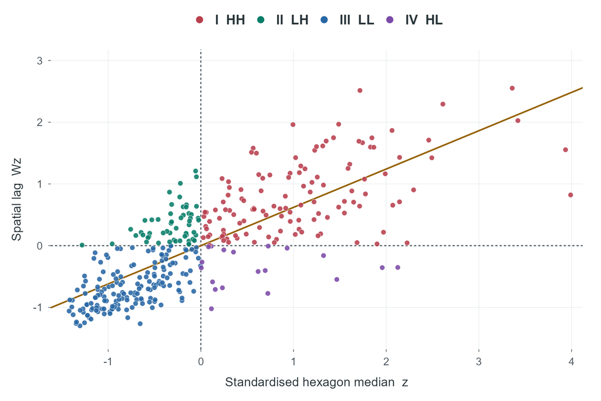

同一批362个有Queen邻居的完整格：横轴为标准化中位报价z，纵轴为邻居的行加权均值Wz；金色过原点线斜率为0.620857。颜色仅表示四象限组合，不表示局部显著性。

**查看并复制全局空间自相关 R 代码**

**分析 1：识别孤立格。** 根据 Queen 邻接确定无邻居格，得到孤立格清单 `isolated_hex_ids` 与参检对象 `analysis_hex`。

```r
# 1. 识别 Queen 邻接中的孤立格，保留其清单并确定参检对象。
neighbors_eligible <- poly2nb(hex_eligible, queen = TRUE,
                             row.names = as.character(hex_eligible$hex_id))
queen_isolates <- card(neighbors_eligible) == 0L
isolated_hex_ids <- hex_eligible$hex_id[queen_isolates]
analysis_hex <- hex_eligible[!queen_isolates, ]
```

**分析 2：重建空间权重。** 在参检对象上重建邻居，得到行标准化权重 `w`，并核对格编号顺序。

```r
# 2. 在参检对象上重建邻接，再构造行标准化权重 W。
neighbors <- poly2nb(analysis_hex, queen = TRUE,
                    row.names = as.character(analysis_hex$hex_id))
w <- nb2listw(neighbors, style = "W", zero.policy = FALSE)
# 数值与权重必须沿用相同的格编号顺序。
stopifnot(identical(as.character(analysis_hex$hex_id), attr(w, "region.id")))
```

**分析 3：计算标准化值与全局关联。** 得到本格报价 `z`、邻域加权均值 `wz` 及全局统计量 `global_i`，供散点图使用。

```r
# 3. 标准化连续美元中位报价，并计算邻域加权均值与全局 Moran's I。
hex_price <- analysis_hex$median_usd
z <- as.numeric(scale(hex_price))
stopifnot(all(is.finite(z)))
wz <- lag.listw(w, z, zero.policy = FALSE)
analysis_n <- length(z)
weight_sum <- Szero(w)
global_i <- analysis_n / weight_sum * sum(z * wz) / sum(z^2)

# 行标准化且没有孤立格时n=S0；过原点拟合线斜率等于Moran I。
```

**分析 4：运行全局置换检验。** 固定随机设置，以 9,999 次置换判断正向空间关联，得到 `global_permutation`。

```r
# 4. 固定随机设置，对原美元中位报价进行单侧置换检验。
RNGkind("Mersenne-Twister", "Inversion", "Rejection")
set.seed(20261024)
global_permutation <- moran.mc(hex_price, w, nsim = 9999,
  alternative = "greater", zero.policy = FALSE)
```

**绘图前提。** 已按2.5分析代码得到同一顺序的 `analysis_hex`、`z`、`wz` 与 `global_i`。配色函数沿用2.4；绘图不重新标准化 `wz`，不重新模拟检验。

**制图 1：准备四象限与显示范围。** 象限仅表示本格和邻域的正负组合，此时不筛局部显著性。

```r
moran_ink <- topic1_spatial_map_theme(figure_mode)
moran_ink$stroke <- moran_ink$paper

# 四象限只表示本格与邻域的正负组合，不表示局部显著性。
quadrant <- ifelse(z > 0 & wz > 0, "HH", ifelse(z < 0 & wz > 0, "LH",
  ifelse(z < 0 & wz < 0, "LL", ifelse(z > 0 & wz < 0, "HL", "Axis"))))
moran_points <- data.frame(hex_id = analysis_hex$hex_id, z = z, wz = wz, quadrant = quadrant)
moran_x_limits <- c(floor(min(z) * 2) / 2 - .12, ceiling(max(z) * 2) / 2 + .12)
moran_y_limits <- c(floor(min(wz) * 2) / 2 - .18, ceiling(max(wz) * 2) / 2 + .18)
```

**制图 2：绘制散点与全局线。** 虚线经过零点，全局线过原点且斜率为本节计算的Moran’s I；图中不增加独立观测OLS的置信带。

```r
moran_plot <- ggplot2::ggplot(moran_points, ggplot2::aes(x = z, y = wz)) +
  ggplot2::geom_hline(yintercept = 0, colour = moran_ink$zero, linewidth = .6, linetype = "22") +
  ggplot2::geom_vline(xintercept = 0, colour = moran_ink$zero, linewidth = .6, linetype = "22") +
  ggplot2::geom_abline(intercept = 0, slope = global_i, colour = moran_ink$line, linewidth = .9) +
  ggplot2::geom_point(ggplot2::aes(fill = quadrant), shape = 21, size = 2.7,
    stroke = .30, colour = moran_ink$stroke, alpha = .88) +
  ggplot2::scale_fill_manual(values = moran_ink$quadrants,
    limits = c("HH", "LH", "LL", "HL"), drop = FALSE,
    labels = c(HH = "I  HH", LH = "II  LH", LL = "III  LL", HL = "IV  HL")) +
  ggplot2::scale_x_continuous(breaks = scales::breaks_width(1),
    expand = ggplot2::expansion(mult = 0)) +
  ggplot2::scale_y_continuous(breaks = scales::breaks_width(1),
    expand = ggplot2::expansion(mult = 0)) +
  ggplot2::coord_cartesian(xlim = moran_x_limits, ylim = moran_y_limits, clip = "on") +
  ggplot2::labs(x = "Standardised hexagon median  z", y = "Spatial lag  Wz", fill = NULL)
```

**制图 3：统一坐标、文字与图例。** 保持正文图的字体、边距与四象限图例。

```r
moran_plot <- moran_plot +
  ggplot2::theme_minimal(base_family = "Arial", base_size = 15) +
  ggplot2::theme(
    plot.background = ggplot2::element_rect(fill = moran_ink$background, colour = NA),
    panel.background = ggplot2::element_rect(fill = moran_ink$background, colour = NA),
    panel.grid.minor = ggplot2::element_blank(),
    panel.grid.major = ggplot2::element_line(colour = scales::alpha(moran_ink$grid, .17),
      linewidth = .3),
    text = ggplot2::element_text(colour = moran_ink$text),
    axis.text = ggplot2::element_text(colour = moran_ink$muted, size = 13),
    axis.title = ggplot2::element_text(colour = moran_ink$text, size = 15),
    axis.title.x = ggplot2::element_text(margin = ggplot2::margin(t = 12)),
    axis.title.y = ggplot2::element_text(margin = ggplot2::margin(r = 12)),
    axis.ticks = ggplot2::element_line(colour = moran_ink$zero, linewidth = .35),
    axis.ticks.length = grid::unit(3, "pt"),
    legend.position = "top", legend.justification = "center",
    legend.direction = "horizontal",
    legend.text = ggplot2::element_text(size = 16, face = "bold"),
    legend.key.width = grid::unit(22, "pt"), legend.spacing.x = grid::unit(11, "pt"),
    legend.margin = ggplot2::margin(b = 12),
    legend.box.margin = ggplot2::margin(0, 0, 0, 0),
    plot.margin = ggplot2::margin(15, 22, 15, 14)) +
  ggplot2::guides(fill = ggplot2::guide_legend(nrow = 1,
    override.aes = list(size = 4, alpha = 1)))
```

**制图 4：直接显示。** 运行 `moran_plot` 即在Plots面板得到本节散点图。

```r
moran_plot
```

**Moran 散点图的读图顺序**

| 顺序 | 怎样读 | 本图中的含义 |
| --- | --- | --- |
| 1 · 横轴 | 读取该格的标准化报价。 | $z=0$ 对应362个参检格的中位报价均值；$z>0$ 为高于这一均值。 |
| 2 · 纵轴 | 读取邻居标准化报价的行加权平均。 | $Wz>0$ 表示邻域平均报价高于同一参照，不要求每个邻居都偏高。 |
| 3 · 象限 | 对照本格与邻域的高低。 | HH122格、LH56格、LL165格、HL19格；这些是正负组合，还没有筛局部显著性。 |
| 4 · 全局线与检验 | 查看整体方向，再看随机置换的证据。 | 过原点线向右上倾斜，斜率为0.620857；9,999次单侧置换的$p=0.0001$。 |

本图的过原点拟合方程为

$$\widehat{Wz}=0.6209z.$$

当某格的中位报价高于样本均值1个标准差时，直线上对应的邻域加权平均约高出同一均值0.621个标准差。散点仍可偏离直线，整体相似性与局部反差可以同时存在。

**进阶 · 为什么斜率等于 Moran’s I**

纵轴$Wz$由已经标准化的邻居值计算，没有再单独标准化。全局统计量为

$$I=\frac{n}{S_0}\frac{z^\mathsf{T}Wz}{z^\mathsf{T}z}.$$

本例排除了无邻居格，在同一362格上重新标准化，且每行权重和为1，因此$n=S_0=362$，上式等于过原点拟合线的斜率。更换权重规范、样本或孤立格处理后，需要重新核对这一关系。

图中没有普通独立观测 OLS 的置信带。空间关联的显著性来自固定图结构、重排报价的置换检验；$I$不作为方差解释比例。参见 [GeoDa全局空间自相关教程](https://geodacenter.github.io/workbook/5a_global_auto/lab5a.html)。

课程负责人：刘贇喆 本章作者：刘贇喆 | 敖漪宇

##### 局部空间自相关

###### **2.6 LISA：局部关联在哪里**

全局 Moran’s I 概括整体关联，局部 Moran 检验逐格考察本格与邻域的组合。本节沿用相同的 **362 个参检格、Queen 权重、$z$ 与 $Wz$**。高低以这批格的整体均值为参照，与 Fisher 地图上的颜色等级分别解读。

每格进行 **9,999次双侧条件置换**：固定该格的报价，从其他格抽取邻居值，同一次模拟的邻域内不重复抽取同一个格。本例默认用**原始模拟$p\leq0.05$**识别局部类别，同时保留 BH、BY、Holm 与 Bonferroni 调整作比较。

原始$p\leq0.05$下，**112格**通过局部检验：**HH44格、LH2格、LL64格、HL2格**；其余 **250格**未通过。地图中的不足5ID 格及3个无 Queen 邻居格未参加本轮检验，统一作为背景灰显示，不能当作“局部不显著”或零报价。

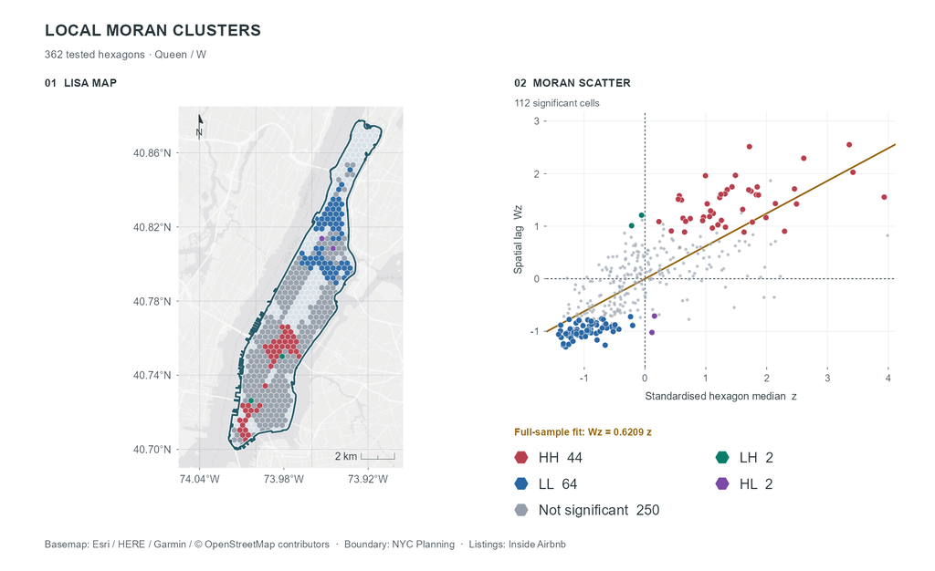

同一批362格的局部Moran地图与Moran散点：原始双侧模拟p不超过0.05时设色，共112格；HH44、LH2、LL64、HL2。250个参检格未通过阈值；另291个未检验格只作背景灰显示。

| p值处理 | 通过阈值 | HH | LH | LL | HL | 未通过 |
| --- | --- | --- | --- | --- | --- | --- |
| none | 112 | 44 | 2 | 64 | 2 | 250 |
| BH | 52 | 24 | 0 | 28 | 0 | 310 |
| BY | 11 | 5 | 0 | 6 | 0 | 351 |
| holm | 0 | 0 | 0 | 0 | 0 | 362 |
| bonferroni | 0 | 0 | 0 | 0 | 0 | 362 |

BH 调整后保留 **52格**（HH24、LL28），BY 调整后保留 **11格**（HH5、LL6）；原始p下的4个 LH/HL 未在这两种调整后保留。局部数量与范围对检验口径敏感，不能把原始112格称为经多重检验确认的112格。

BH 针对错误发现比例的期望，其保证需要独立或特定正相关条件；BY 允许更一般的依赖结构。Holm 和 Bonferroni 控制整组至少一次误报的概率。本例9,999次双侧模拟的最小p为0.0002，高于$0.05/362$，因此后两种方法的0格还受到模拟分辨率限制，不能据此断言没有局部空间关联。

**查看并复制局部空间自相关 R 代码**

**分析 1：运行局部条件置换。** 沿用全局分析的 `z` 与 `w`，固定串行计算和随机设置，得到 `local_permutation`。

```r
# 1. 沿用同一 z 与 W，明确串行计算并固定随机设置。
set.coresOption(NULL)
RNGkind("Mersenne-Twister", "Inversion", "Rejection")
set.seed(20261025)
local_permutation <- localmoran_perm(z, w, nsim = 9999,
  alternative = "two.sided", iseed = 20261025,
  no_repeat_in_row = TRUE, mlvar = TRUE, sample_Ei = TRUE,
  adjust.x = FALSE, zero.policy = FALSE)
```

**分析 2：提取 p 值并分类。** 使用双侧模拟秩 p 值及同一组 `z`、`wz` 判断象限，将原始 p 不大于 0.05 的格标为相应类别。

```r
# 2. 提取双侧模拟秩 p，按本格与邻域的正负组合确定四象限。
p_raw <- as.numeric(local_permutation[, "Pr(z != E(Ii)) Sim"])
quadrant <- case_when(
  z > 0 & wz > 0 ~ "HH",
  z < 0 & wz > 0 ~ "LH",
  z < 0 & wz < 0 ~ "LL",
  z > 0 & wz < 0 ~ "HL",
  TRUE ~ "Axis")
stopifnot(length(p_raw) == nrow(analysis_hex), all(is.finite(p_raw)),
          !any(quadrant == "Axis"))
analysis_hex$lisa_cluster <- ifelse(p_raw <= 0.05, quadrant, "NS")
```

**分析 3：比较多重检验校正。** 对同一组原始 p 值逐一应用校正，得到 `lisa_method_counts`，不重新模拟。

```r
# 3. 共用同一组原始 p 值，仅改变校正方法，不再抽样。
adjustment_methods <- c("none", "BH", "BY", "holm", "bonferroni")
p_adjusted <- vapply(adjustment_methods,
  function(method) p.adjust(p_raw, method = method), numeric(length(p_raw)))
lisa_class_by_method <- apply(p_adjusted, 2,
  function(p) ifelse(p <= 0.05, quadrant, "NS"))
lisa_method_counts <- bind_rows(lapply(adjustment_methods, function(method) {
  classes <- lisa_class_by_method[, method]
  data.frame(method = method, significant = sum(classes != "NS"),
             HH = sum(classes == "HH"), LH = sum(classes == "LH"),
             LL = sum(classes == "LL"), HL = sum(classes == "HL"),
             NS = sum(classes == "NS"))
}))
lisa_method_counts %>%
  knitr::kable(col.names = c("p值处理", "通过阈值", "HH", "LH", "LL", "HL", "未通过"))
```

**绘图前提。** 沿用2.4的地图要素与图例符号，以及2.6分析得到的 `analysis_hex`、`z`、`wz`、`global_i` 和 `lisa_class_by_method`。以下仅切换已有类别，不重新运行置换。

**制图 1：选择局部检验口径。** `"none"` 对应正文原始p值；可改为 `"BH"` 或 `"BY"` 后从此模块继续运行。

```r
lisa_method <- "none"
quadrant_levels <- c("HH", "LH", "LL", "HL")
ink <- topic1_spatial_map_theme(figure_mode)
points <- data.frame(hex_id = analysis_hex$hex_id, z = z, wz = wz,
  display_class = as.character(lisa_class_by_method[, lisa_method]))
```

**制图 2：连接类别与显示几何。** 地图裁切不改变完整格中的检验结果；不足门槛和无邻居格保留为两类背景。

```r
# 显示几何按主岛边界裁切，再连回各格的检验类别。
full_hex <- sf::st_transform(hex_all, 2263)
island_2263 <- sf::st_transform(main_island_2263, 2263)
display_hex <- suppressWarnings(sf::st_intersection(full_hex,
  sf::st_geometry(island_2263)))
display_hex <- sf::st_transform(display_hex, 4326)
matched <- match(display_hex$hex_id, points$hex_id)
display_hex$draw_class <- ifelse(!display_hex$eligible, "Below5",
  ifelse(is.na(matched), "Isolate", points$display_class[matched]))
```

**制图 3：逐层绘制LISA地图。** 地图与后续散点使用同一组局部类别。

```r
# 先铺底图，再画类别及主岛轮廓。
map <- ggplot2::ggplot() +
  topic1_spatial_map_background(ink) +
  ggplot2::geom_sf(data = display_hex, ggplot2::aes(fill = draw_class),
    colour = ink$paper, linewidth = .17, alpha = .95) +
  ggplot2::scale_fill_manual(values = c(ink$quadrants, ink$neutrals), guide = "none") +
  topic1_spatial_map_foreground(ink, sf::st_transform(island_2263, 4326), "Arial")
```

**制图 4：区分通过与未通过检验的格。** 只在已经参检的格中分组；横纵范围由同一批格计算。

```r
significant <- points$display_class != "NS"
selected <- points[significant, ]
plain <- points[!significant, ]
x_limits <- c(floor(min(points$z) * 2) / 2 - .12, ceiling(max(points$z) * 2) / 2 + .12)
y_limits <- c(floor(min(points$wz) * 2) / 2 - .18, ceiling(max(points$wz) * 2) / 2 + .18)
```

**制图 5：绘制全局线与灰点。** 未通过当前门槛的参检格使用小号灰点。

```r
scatter <- ggplot2::ggplot() +
  ggplot2::geom_hline(yintercept = 0, colour = ink$zero, linewidth = .55, linetype = "22") +
  ggplot2::geom_vline(xintercept = 0, colour = ink$zero, linewidth = .55, linetype = "22") +
  ggplot2::geom_abline(intercept = 0, slope = global_i, colour = ink$line, linewidth = .9) +
  ggplot2::geom_point(data = plain, ggplot2::aes(x = z, y = wz, fill = display_class),
    shape = 21, size = 1.65, stroke = .20, colour = ink$paper, alpha = .64) +
  ggplot2::scale_fill_manual(values = c(ink$quadrants, ink$neutrals), guide = "none") +
  ggplot2::scale_x_continuous(breaks = scales::breaks_width(1),
    expand = ggplot2::expansion(mult = 0)) +
  ggplot2::scale_y_continuous(breaks = scales::breaks_width(1),
    expand = ggplot2::expansion(mult = 0)) +
  ggplot2::coord_cartesian(xlim = x_limits, ylim = y_limits, clip = "on") +
  ggplot2::labs(x = "Standardised hexagon median  z", y = "Spatial lag  Wz")
```

**制图 6：统一散点样式。** 零点参考线、刻度和字号保持正文图的设置。

```r
scatter <- scatter +
  ggplot2::theme_minimal(base_family = "Arial", base_size = 12) +
  ggplot2::theme(
    plot.background = ggplot2::element_rect(fill = ink$background, colour = NA),
    panel.background = ggplot2::element_rect(fill = ink$background, colour = NA),
    panel.grid.minor = ggplot2::element_blank(),
    panel.grid.major = ggplot2::element_line(colour = scales::alpha(ink$grid, .18),
      linewidth = .3),
    axis.text = ggplot2::element_text(colour = ink$muted, size = 11.5),
    axis.title = ggplot2::element_text(colour = ink$text, size = 12),
    axis.title.x = ggplot2::element_text(margin = ggplot2::margin(t = 10)),
    axis.title.y = ggplot2::element_text(margin = ggplot2::margin(r = 8)),
    axis.ticks = ggplot2::element_line(colour = ink$zero, linewidth = .35),
    axis.ticks.length = grid::unit(3, "pt"),
    plot.margin = ggplot2::margin(7, 10, 7, 8))
```

**制图 7：叠加显著格。** 浅深主题使用相同类别；深色主题为显著格增加两层轻微光晕。

```r
if (identical(figure_mode, "dark")) {
  scatter <- scatter +
    ggplot2::geom_point(data = selected, ggplot2::aes(z, wz, colour = display_class),
      size = 6.0, shape = 16, alpha = .055, show.legend = FALSE) +
    ggplot2::geom_point(data = selected, ggplot2::aes(z, wz, colour = display_class),
      size = 4.55, shape = 16, alpha = .11, show.legend = FALSE) +
    ggplot2::scale_colour_manual(values = ink$quadrants, guide = "none")
}
scatter <- scatter + ggplot2::geom_point(data = selected, ggplot2::aes(z, wz, fill = display_class),
  shape = 21, size = if (identical(figure_mode, "dark")) 3.25 else 2.95,
  stroke = .30, colour = ink$paper, alpha = 1)
```

**制图 8：统计图例计数。** 四象限及未通过数量只统计参检格，地图背景格不计入“未通过”。

```r
significant_count <- sum(points$display_class != "NS")
ns_count <- sum(points$display_class == "NS")
counts <- table(factor(points$display_class, levels = quadrant_levels))
```

**制图 9：组合地图与散点。** 标题、全样本拟合式和显著格数直接读取分析结果。拼图使用agg字体度量，完成后恢复原设备。

```r
# agg只用于拼图时的字体与尺寸度量，完成后恢复原设备。
previous_device <- cowplot::set_null_device("agg")
lisa_panel <- cowplot::ggdraw() +
  cowplot::draw_plot(map, x = -.040, y = .145, width = .655, height = .670) +
  cowplot::draw_plot(scatter, x = .542, y = .286, width = .425, height = .529) +
  cowplot::draw_label("LOCAL MORAN CLUSTERS", x = .048, y = .947, hjust = 0,
    vjust = .5, colour = ink$text, fontface = "bold", size = 19) +
  cowplot::draw_label(sprintf("%d tested hexagons · Queen / W", nrow(analysis_hex)),
    x = .048, y = .905, hjust = 0, vjust = .5, colour = ink$muted, size = 12.5) +
  cowplot::draw_label("01  LISA MAP", x = .048, y = .855, hjust = 0, vjust = .5,
    colour = ink$text, fontface = "bold", size = 13) +
  cowplot::draw_label("02  MORAN SCATTER", x = .550, y = .855, hjust = 0, vjust = .5,
    colour = ink$text, fontface = "bold", size = 13) +
  cowplot::draw_label(sprintf("%d significant cells", significant_count),
    x = .550, y = .820, hjust = 0, vjust = .5, colour = ink$muted, size = 11.5) +
  cowplot::draw_label(sprintf("Full-sample fit: Wz = %.4f z", global_i),
    x = .550, y = .244, hjust = 0, vjust = .5, colour = ink$line,
    size = 11.5, fontface = "bold")
```

**制图 10：补充类别图例并显示。** 图例颜色与地图、散点一致；直接输出 `lisa_panel` 到Plots面板。

```r
for (j in seq_along(quadrant_levels)) {
  key <- quadrant_levels[j]
  lisa_panel <- topic1_spatial_legend_item(lisa_panel, sprintf("%s  %d", key, counts[[key]]),
    ink$quadrants[[key]], c(.550, .765)[(j - 1) %% 2 + 1],
    c(.199, .153)[(j - 1) %/% 2 + 1], ink, 16.5)
}
lisa_panel <- topic1_spatial_legend_item(lisa_panel, sprintf("Not significant  %d", ns_count),
  ink$neutrals[["NS"]], .550, .107, ink, 16.5)
lisa_panel <- lisa_panel + cowplot::draw_label(
  "Basemap: Esri / HERE / Garmin / © OpenStreetMap contributors  ·  Boundary: NYC Planning  ·  Listings: Inside Airbnb",
  x = .048, y = .047, hjust = 0, vjust = .5, colour = ink$muted, size = 11.5) +
  ggplot2::theme(plot.background = ggplot2::element_rect(fill = ink$background,
    colour = NA))
cowplot::set_null_device(previous_device)
lisa_panel
```

**LISA 地图的读图顺序**

1. **区分未检验与未通过。** 背景灰含288个不足5ID 格及3个无邻居格；“NS”只指362格中完成局部检验但未过门槛的250格。
2. **核对高低参照。** HH 是本格中位报价与邻域加权平均都高于362格均值；LL 是两者都低于该均值，不要求每个邻居同为高或低。
3. **定位同类组合与局部反差。** 原始p下 HH 主要位于主岛中南段，LL 主要位于北段；LH 与 HL 各2格表示本格和邻域的高低相异。
4. **比较检验口径。** 对照原始p、BH 和 BY，观察局部证据保留多少，再讨论位置和范围。

这里的“热点／冷点”指**报价的高—高／低—低局部组合**。它们不表示人流热度、入住率或出租量；本节也未另行进行 Getis–Ord 热点检验。解释实际成交、房型与社区因素的作用，需要额外数据与研究设计。

北部报价较低的网格与中南段报价较高的网格提供了可继续研究的空间线索。社区历史、住房与社会经济资料可用于提出假设，但当前 LISA 本身没有识别价格差异的原因。

**进阶 · 北部社区、社会经济不利与低报价片区**

**从社区历史认识北部。** Harlem 是非裔美国人的重要居住与文化中心，20 世纪初的人口迁入及 Harlem Renaissance 塑造了其文化地位；此后的就业变化、建筑修复与新建持续改变着社区，见 [美国国家公园管理局的 Harlem 历史介绍](https://www.nps.gov/articles/000/harlem.htm)。Washington Heights 与 Inwood 则具有鲜明的移民社区背景。纽约市规划局《The Newest New Yorkers 2026》采用 2019—2023 年 ACS 数据，估计两地外出生人口分别约占 **44%** 和 **41%**，见[报告第三章](https://www.nyc.gov/assets/planning/newest-new-yorkers-2026/Ch3.html)。这些资料展示了北部社区的历史与人口差异。

**社会经济不利怎样进入分析？** 社会经济不利 （socioeconomic deprivation） 涉及收入、就业、教育与住房条件等方面的资源不足。可先用贫困率和住房负担等具体指标描述社区，再检查它们与低报价片区的关系。

NYU Furman Center 社区网页中标为 **2024 年**的指标提供了以下背景：

| 社区统计区 | 贫困率 | 严重租金负担家庭占租房家庭比例 |
| --- | --- | --- |
| [Central Harlem，MN10](https://www.furmancenter.org/neighborhoods/central-harlem/) | 26.7% | 29.3% |
| [Washington Heights/Inwood，MN12](https://www.furmancenter.org/neighborhoods/washington-heights-inwood/) | 19.2% | 30.2% |

同一来源给出的全市贫困率为 **18.0%**；严重租金负担指租金支出超过家庭收入的 **50%**。北部各社区的社会经济条件存在差异，低住宿报价与居民较重的住房负担也可能同时出现：前者衡量公开住宿价格，后者还取决于居民收入。

**由此可以提出的假设是：** 在统一入住时长，并考虑入住日期、房型、可住人数与区位后，社区社会经济条件与六边形报价之间是否仍有关联？检验时需将社区资料与六边形进行空间匹配，核对统计年份与样本覆盖。这里的社区资料按 Community District 或报告中的社区单元汇总，未与本例 LL 格逐格叠加；它们提供解释线索，当前 LISA 识别的对象仍是**报价的局部关联**。

#### 为什么整体显著，多数格却未通过局部检验？

全局 Moran’s I 把全部362个参检格的相邻关系汇总为一个统计量；局部检验分别考察各格，门槛与多重检验处理也会影响识别范围。本例默认原始p下有250格未通过，BH 后为310格、BY 后为351格。未通过表示证据未达到所设门槛，不能据此认定没有空间关联；另291格没有参加检验，不应并入“NS”。参见 [GeoDa局部空间自相关教程](https://geodacenter.github.io/workbook/6a_local_auto/lab6a.html)。

课程负责人：刘贇喆 本章作者：刘贇喆 | 敖漪宇

## **3.0 专题研究 1：回顾与反思**

### **3.0 专题研究 1：回顾与反思**

本例完成了获取数据、预处理、空间聚合、全局 Moran’s I 与 LISA 局部分析的基本 ESDA 流程。回顾分为三个层次：处理后的一条观测代表什么，当前结果说明什么，以及哪些研究选择需要进一步检验。

#### **3.1 研究回顾：问题与回答**

| 基本流程 | 已完成的操作 | 得到的分析对象或证据 |
| --- | --- | --- |
| 数据获取与初探 | 读取 3、6、9 月三个快照，限定主岛，检查报价状态并绘制原价／对数分布。 | 研究范围内的房源—批次记录。 |
| 数据预处理 | 保留有效正价，核查 ID 与批次唯一性；按 ID 求均价，再筛均价的 P5–P95。 | 每个挂牌房源 ID 一个代表报价与位置。 |
| 六边形密铺与聚合 | 每个 ID 唯一归格；至少含 5 个不同 ID 的格计算中位报价。 | 固定面积的区域观测及各格样本量。 |
| 全局 Moran’s I | 排除无邻居格，重建 Queen 权重和标准化值，绘制散点图并作全局置换。 | 整体空间关联的方向、量级及检验结果。 |
| LISA | 沿用同一批参检格与权重，作局部条件置换，比较原始与调整后的 p 值分类。 | 局部集聚、空间离群及其位置。 |

**记录数为何逐步变化？** 主岛 43,589 条原始记录 → 27,736 条有效正价记录 → 11,853 个 ID 均价 → P5–P95 后 10,669 个 ID → 365 个至少含 5 个不同 ID 的达标六边形 → 362 个有 Queen 邻居的参检格。

这条流程包含筛选，也包含分析单位的转换。按 ID 汇总将同一挂牌房源的跨期观测合成一个代表报价；六边形聚合再将房源报价概括为区域中位数。计算比例或均值时，应说明分子、分母及其单位，不能将记录数、房源数与六边形数当作同一总量替换。坐标相同的不同 ID 在整个流程中仍分别保留。

| 研究问题 | 当前结果 | 怎样解释？ |
| --- | --- | --- |
| 报价如何分布？ | 有效报价右偏、长尾；六边形图中，北段较多格报价偏低，中南段有更多报价较高的格。 | 描述的是当前样本的挂牌报价；房型、入住条件和缺失分布仍可能影响地区差异。 |
| 相近报价是否倾向于相邻？ | 362 格的 $I=0.621$，9,999 次单侧置换的 $p=0.0001$。 | 当前尺度与权重下呈全局正空间自相关；I 不表示价格差异的解释比例。 |
| 局部集聚在哪里？ | 原始 $p\leq0.05$ 下，HH 44 格主要在中南段，LL 64 格主要在北段；LH、HL 各 2 格。 | HH／LL 是本格与邻域相对于整体均值的同向组合；LH／HL 提示局部反差。 |
| 局部判断依赖检验口径吗？ | 原始 p 下有 112 个显著格，BH 后为 52 格，BY 后为 11 格。 | 显著范围会随多重检验处理变化；仅凭主图不能断言局部边界稳定。 |

全局结果概括整体关联，局部结果将高低值组合落实到位置。二者共同为房型、区位与社区条件研究提供线索；价格成因仍需补充资料和解释设计。下文先回顾空间聚合，再讨论影响这些判断的研究设置。

#### **3.2 知识回顾：从点到区域**

##### 为什么把点汇总到网格？

原始点适合查看位置与点间差异。本例关注**相邻局部区域的典型报价是否相似**，因此将每个房源 ID 的代表点归入固定面积的格，以格内中位价比较区域。点数据也可直接使用距离或 $k$ 最近邻权重，方法见 [GeoDa 点距离权重教程](https://geodacenter.github.io/workbook/4b_dist_weights/lab4b.html)。

**六边形分箱** （hexagonal binning / hexbin）：以无空隙、不重叠的六边形划分平面，将每个点唯一归格，再计算数量、均值或中位数。密铺规定单元怎样覆盖空间，分箱规定点怎样归组和汇总。

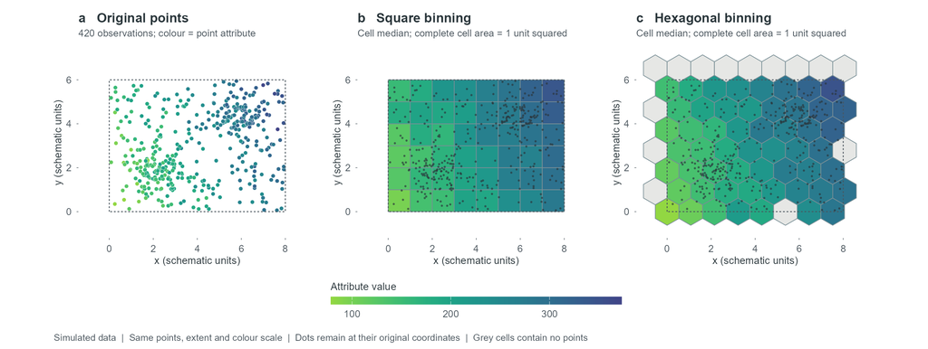

同一批模拟点：原始点、等面积方格与六边形分箱

**读图。** 同一批模拟点分别汇总到等面积方格与六边形，整体高低值位置相近，边界附近的混合和局部细节有所不同。聚合得到区域代表值，也压缩了格内差异。

##### 为什么选六边形？方格可以吗？

| 比较项 | 正六边形 | 正方形 |
| --- | --- | --- |
| 完整密铺内部的邻居 | 6 个共边邻居，中心距离相等。 | 4 个共边邻居；加入角邻居后为 8 个，角邻居距离是边邻居的 $\sqrt{2}$ 倍。 |
| 形状与数据衔接 | 同面积时更紧凑，适合比较六个方向的邻域，仍有固定方向。 | 便于与栅格像元、行列索引衔接，也可旋转。 |
| 本例需要核对 | 少样本格退出后，邻居可能不足 6 个；实测 Queen 与 Rook 列表相同。 | Queen 与 Rook 通常不同，需随几何重新定义。 |

几何解释见 [Esri：Why hexagons?](https://pro.arcgis.com/en/pro-app/3.4/tool-reference/spatial-statistics/h-whyhexagons.htm)。两种形状均需检查面积、起点和边缘。

**等面积比较的参数。** 当 $A=0.10\text{ km}^2$ 时，方格边长 $\sqrt{A}\approx316.23$ m；正六边形边长 $\sqrt{2A/(3\sqrt{3})}\approx196.19$ m，对边距离约 339.81 m。`st_make_grid()` 的六边形 `cellsize` 指对边距离；只切换 `square` 而保留原 `cellsize` 会改变面积。长度须换成投影单位，本例 EPSG:2263 使用美国测量英尺。见 [`st_make_grid()` 文档](https://r-spatial.github.io/sf/reference/st_make_grid.html)。

**选学进阶 · Uber H3 的层级网格与索引压缩**

[Uber 的 H3](https://www.uber.com/us/en/blog/h3/) 是以六边形为主的全球层级空间索引 （hierarchical geospatial index）。单元有唯一编号，可查询父格、子格和邻居；分辨率 0–15，数值越大，单元越小。

**按密度调整大小。** 可先在同一细层级编码所有点，再设置点数阈值：过密区域继续细分，稀疏区域沿父索引合并。最终每点只归入一个组，各组重新计算统计量。规则需另行设定；[H3 已答讨论](https://github.com/uber/h3/discussions/737)与[自适应网格交互示例](https://observablehq.com/@nrabinowitz/h3-adaptive-grid)展示了实现思路。

**索引压缩。** [`compactCells()`](https://h3geo.org/docs/api/hierarchy/#compactcells) 将齐全的同层子格集合递归换成父格；它读取索引集合，不读取房源点数。下图展示这一操作。

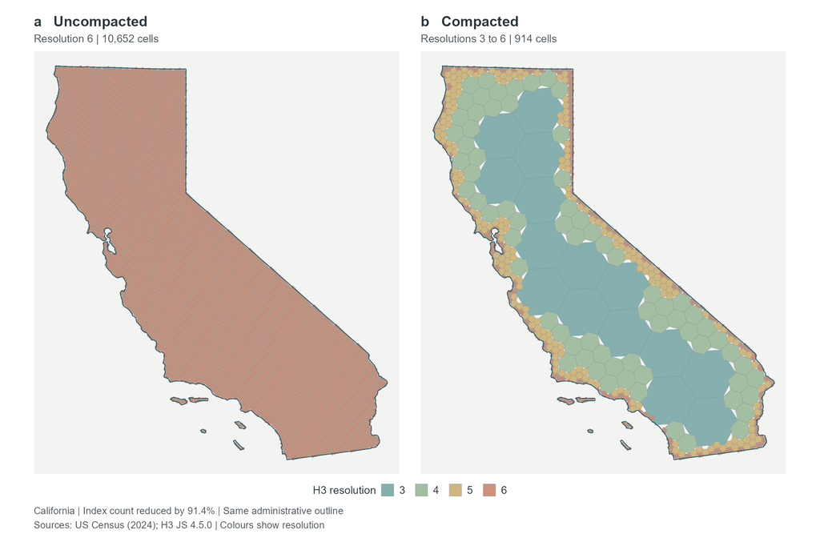

加州 H3 索引：统一细分辨率与压缩后的混合分辨率表示

加州的 **10,652 个分辨率 6 索引**压缩为 **914 个混合层级索引**，数量减少约 **91.4%**；展开回分辨率 6 后，索引集合完全恢复。内部容易凑齐完整子格组，边缘较多细格保留。颜色表示分辨率，格的大小由子格集合是否齐全决定，与人口或房源密度无关。

图按 [Uber 原文](https://www.uber.com/us/en/blog/h3/)与 [H3 官方索引说明](https://h3geo.org/docs/highlights/indexing/)的思路独立计算；行政轮廓采用 [U.S. Census Bureau 制图边界](https://www.census.gov/geographies/mapping-files/time-series/geo/cartographic-boundary.html)。

**使用边界。** 父子关系在索引上精确，原生几何仅近似嵌套，多层级绘图可出现间隙或重叠，见[边界交互示例](https://observablehq.com/@nrabinowitz/h3-hierarchical-non-containment)。每个分辨率还包含 12 个五边形，同级面积并非处处相同；[尺度表](https://h3geo.org/docs/core-library/restable/)中的分辨率 9 平均面积约 0.105 km²，只可作为尺度参照。

**应用阅读。** Uber 原文介绍出行供需；[Volkswagen／NVIDIA 案例](https://developer.nvidia.com/blog/accelerating-volkswagen-connected-car-data-pipelines-100x-faster-with-nvidia-rapids/)以每批约 2,500 条位置记录为计算约束，逐级细分过密组。若用混合层级格比较报价，还需记录实际覆盖与点数，重新定义邻居。本例仍保留固定面积的 `sf` 平面六边形。

#### **3.3 研究设置的不足与改进**

数据检查可以发现空值、解析失败和重复批次记录，但不会自动决定研究范围、价格变量或空间尺度。本例采用的一组设定使分析得以实施，仍存在其他合理选择。敏感性分析通过有计划地改变这些设定，检查主要发现的适用范围及发生变化的位置。

| 环节 | 当前设定 | 可以怎样比较？ |
| --- | --- | --- |
| 范围与时点 | 曼哈顿主岛，3、6、9 月三个快照。 | 分批次或按房型比较，检查样本构成、缺失与覆盖差异。 |
| 价格与代表值 | ID 算术均价；格内中位数；原美元统计变量。 | 分别比较 ID 层代表值、格层代表值和统计变量变换，避免同时改动。 |
| 价格筛选 | 在 ID 均价层保留 P5–P95。 | 对比不截尾、P1–P99，并记录被排除 ID 及有效覆盖。 |
| 空间单元与支持 | 0.10 km² 六边形，至少 5 个不同 ID。 | 分开比较面积、起点、等面积形状与 ID 数量门槛。 |
| 邻居与权重 | Queen、行标准化，排除孤立格后重建。 | 比较有依据的距离或最近邻规则，检查连通部分和长连线。 |
| 显示与统计判断 | Fisher 七级设色，局部原始 $p\leq0.05$。 | 分级数只改显示；p 调整方法和显著性阈值分别比较。 |

##### 样本与报价口径

当前使用平台每夜挂牌报价。实际入住日期、时长、房型、可住人数和折扣仍有差异，三个批次还存在上下架及价格缺失。可先按批次、房型检查缺失比例和报价分布，再比较相近住宿产品。跨期均价概括已观测时点，没有消除季节变化，也不能代替成交价或入住率。

按房源 ID 汇总后，每个 ID 对分位筛选和格内中位数各贡献一个代表报价；不同 ID 即使位于同一公开坐标也分别保留。代表位置取该 ID 最新一条有效正价记录的公开坐标，坐标跨期变化时，归格可能受此规则影响。未出现的批次保留为未观测状态。房源 ID 标识公开挂牌房源，不能据此证明是不同建筑、经过核实的独立物理住处或实际成交。

**代表值与代表位置可以分别检查。** 当前存在两次不同层级的汇总：ID 层概括跨期报价，格层概括区域内的房源报价。比较 ID 均值与中位数时，从模块 7 开始重算分位筛选及下游结果；本例每个 ID 至多三条报价，只有一条或两条时，R 默认中位数与均值相同。比较格内中位数与均值时，则固定入选 ID 和位置，从 2.4 节的格内汇总代码开始重算，以检查高价房源对区域代表值的影响。

位置规则可先比较最新与最早有效正价记录的坐标：固定 ID 报价与分位入选集合，只更换代表位置，统计多少 ID 改格，再重做格内汇总、邻居和检验。经纬度均值可能落在未观测的位置，采用前须另作说明。

##### 价格筛选与空间覆盖

P5–P95 聚焦房源均价的主体范围，也改变格内组成及达到 ID 门槛的区域。当前在 **11,853 个 ID 均价**中保留 **10,669 个**，显示范围为 **63.96–1,000 美元／夜**，两端各排除 **592 个 ID**。区间外报价仍可能有效；分位阈值应与研究对象相联系。

**价格范围的对照应同时检查报价与覆盖。** 可固定 11,853 个 ID 的代表均价与位置，比较不截尾、P1–P99 和当前 P5–P95。每次从模块 8 重算分位边界与入选 ID，再按同一网格重新汇总，检查达标格、孤立格与空间检验。

| 比较层次 | 具体做法 | 回答什么？ |
| --- | --- | --- |
| 各方案的完整结果 | 每个价格范围都运行完整流程，报告入选 ID、达标格、参检格、I 与局部类别。 | 采用这一筛选范围后，实际得到怎样的覆盖和结果？ |
| 固定网格下的共同格 | 另取各方案共同参检的格，在相同顺序下重新检查邻居、构建 W 并计算各方案的 z 与 Wz。 | 限定在同一空间覆盖后，报价差异仍会怎样影响结果？ |

共同格分析不能直接截取旧 W 或沿用旧 z：邻居减少会改变权重，参检集合改变也会改变标准化参照。若共同集合出现孤立格，还须按统一规则处理并重新核对。比较局部类别时，分别记录“退出检验”与“仍参检但由 HH／LL 变为 NS”，避免把样本退出读成集聚消失。

上述价格范围的系统对照尚未执行。当前 365 个达标格、362 个参检格和 I 只对应主方案，不能沿用到新筛选样本。

##### 空间聚合与尺度选择：当前模式是否稳定？

本例采用 **0.10 km² 六边形、每格至少 5 个不同挂牌房源 ID**。同坐标不同 ID 分别计数，同一 ID 跨批次只计一次；该门槛不能解释为五处不同物理住处或五次成交。这项选择同时影响局部细节、格内数据量及有效覆盖，需要结合敏感性分析讨论。

**15 分钟城市：生活圈与计算单元**

15 分钟城市强调居民通过约 15 分钟步行或骑行获得日常服务。[Moreno 等（2021）](https://doi.org/10.3390/smartcities4010006)从密度、邻近、多样性与数字化讨论这一规划框架。它为本例提供邻里尺度的观察视角。

[Bruno 等（2024）](https://doi.org/10.1038/s44284-024-00119-4)的[作者公开稿方法部分](https://arxiv.org/html/2408.03794v1#S3.SS2)采用**边长 200 m**的六边形，再用 OSRM 计算到设施的路网时间。其计算单元与本例约 196 m 的边长接近，为细尺度选择提供了研究实现参照。

**本例的 0.10 km² 承载报价汇总；15 分钟服务范围取决于路网、出行方式和设施位置。** 时间目标不能直接推导固定面积，面积是否适合当前数据仍需检验。

**先看一次聚合隐藏了什么。** 当前两个真实格的中位报价相近，内部报价却很不同：

| 检查项 | 格 662 | 格 381 |
| --- | --- | --- |
| 中位报价（美元／夜） | 232.74 | 239.45 |
| 不同房源 ID 数 n | 46 | 22 |
| 中间一半房源均价所在区间 Q1–Q3（美元／夜） | 216.48–259.74 | 86.74–466.98 |

IQR 是上述区间的宽度 $Q_3-Q_1$，两格分别为 **43.26** 与 **380.24 美元**。它衡量格内离散程度；n 表示汇总所依据的不同房源数量，两者共同补充中位价图。

**查看当前网格的诊断图 · 两格分布与全岛 n／IQR**

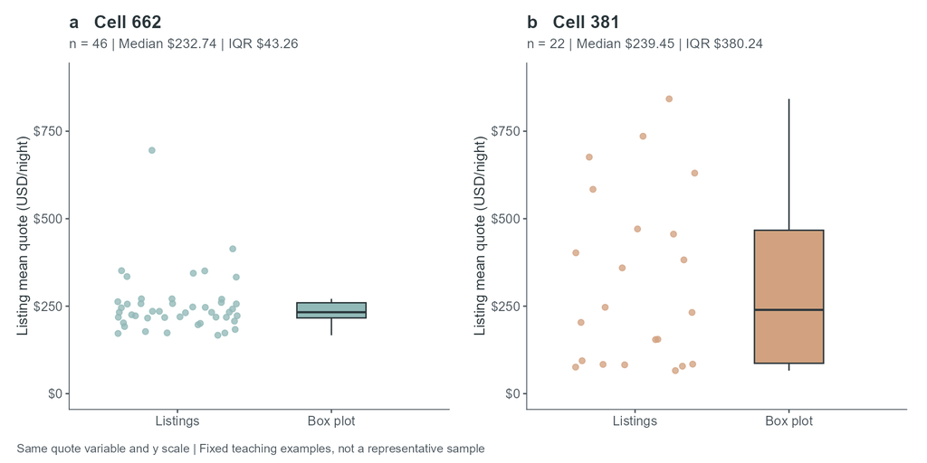

两个中位报价相近的真实六边形：房源均价与箱线图

两图纵轴一致，每点代表一个房源 ID 的已观测报价均值。662、381 两格作为固定教学例，说明相近的区域中位数可能对应差异很大的格内分布；它们不能代表全岛所有格，也不能据此给出中位数的精度或置信区间。

[figure not shown]

当前0.10 km²网格的样本支持：不同房源ID数与格内报价IQR（分别采用五级Fisher）

365 个达标格的房源 ID 数为 **5–299**，中位数 **20**；格内房源均价 IQR 的中位数为 **148.83 美元／夜**。两图分别以五级 Fisher 显示数量与 IQR，再与中位报价、LISA对读。统计基于每个 ID 的代表均价，分位点用 `type = 7`；房源数与 IQR 不能直接解释为中位数的精度，至少 5 个 ID 只规定纳入资格。定义见 [R IQR 文档](https://search.r-project.org/R/refmans/stats/html/IQR.html)，重抽样推断可选读 [Bootstrap 教程](https://rafalab.dfci.harvard.edu/dsbook-part-2/inference/bootstrap.html)。

**当前数量与 IQR 的计算代码**

```r
# 当前样本支持：从同一份ID归格表计算数量和格内报价离散程度。
# 诊断使用全部365个达标格，区别于Moran/LISA的362个参检格。
hex_support_current <- listing_members %>%
  group_by(hex_id) %>%
  summarise(n_id = n_distinct(id),
            median_usd = median(listing_mean_usd),
            q1 = quantile(listing_mean_usd, 0.25, type = 7),
            q3 = quantile(listing_mean_usd, 0.75, type = 7),
            iqr_usd = IQR(listing_mean_usd, type = 7), .groups = "drop") %>%
  filter(n_id >= 5L)
stopifnot(nrow(hex_support_current) == 365L,
          min(hex_support_current$n_id) == 5L,
          median(hex_support_current$n_id) == 20,
          max(hex_support_current$n_id) == 299L,
          abs(median(hex_support_current$iqr_usd) - 148.83) < 1e-8)
```

**再改变空间划分，检验 MAUP。** 上述图检查当前固定网格；改变单元面积或边界后重算，才是在比较尺度效应与分区效应。可回看导论及 [NCRM 的 MAUP 教学案例](https://www.restore.ac.uk/geo-refer/91023cwors00y00000000.php)。

**起步方案：先做三组有区分度的检查**（尚未运行）。

| 改变什么？ | 怎样设置？ | 重点比较什么？ |
| --- | --- | --- |
| **面积：尺度效应** | 0.05、0.10、0.20 km²；固定价格口径、网格方向与基准起点，并记录参数。 | 区域中位价、有效覆盖及 HH／LL 片区的位置与连片程度。 |
| **起点：分区效应** | 固定 0.10 km²，先从格心坐标核对 x、y 方向各自的重复间距，再分别沿一个方向平移该方向间距的一半；扩展边缘候选格以覆盖整个主岛。 | 同一批点重新归格后，局部边界和中位价如何变化，是否有漏归点。 |
| **房源 ID 门槛：样本支持** | 固定网格，比较至少 3、5、10 个不同房源 ID。 | 哪些区域失去覆盖，统计量与局部类型是否随之改变。 |

方格对照可沿用等面积参数另设一组。房源 ID 数量门槛改变的是样本纳入，需与改变空间单元的 MAUP 检查分开记录。

**网格几何改变后，怎样比较位置？** 面积、起点或形状一变，相同 `hex_id` 就不再代表同一地面单元。应先并列显示各方案，再在主岛的共同可检验范围内比较 HH／LL 的地面覆盖、交叠比例与主要片区位置。为比较范围而叠加得到的碎片，只用于地图对照，不作为新的独立观测重新计算 Moran’s I。

##### 怎样组织一次敏感性分析？

1. **预先列出候选。** 各组均以主方案为基准，其余设置保持主方案。可依次比较价格范围、ID 门槛和面积，每组只改一项；比较门槛时固定 0.10 km²，比较面积时固定至少 5 个 ID。
2. **从受影响的模块开始重算。** 每组参数对应一个 `scenario_id`，分别保存输入、参数和结果。上游样本或网格改变后，不复用旧的格属性、W、z 或置换结果。主方案中的数量断言须改为该方案的实际核对，保留每个 ID 唯一归格、单位和观测顺序检查。
3. **同时报告完整覆盖与可比范围。** 固定几何时，补充共同格分析；几何改变时，比较地面范围。对照图沿用同一底图和 LISA 色盘；同一价格变量尽量使用固定参考断点，并完整显示超出参考范围的值。
4. **记录改变了什么。** 除 I 和显著格数外，还检查哪些区域退出、哪些局部类别转换、哪些片区在各方案中持续出现。保留无显著格或覆盖不足的候选，不只呈现符合预期的地图。

每个方案可用下表整理结果。价格、网格和邻居方案仍是后续研究设计，当前未据此声称结果稳健。

| 报告项目 | 至少记录什么？ |
| --- | --- |
| 参数与输入 | `scenario_id`、改变项、分位点、入选 ID 数及代表值／位置规则。 |
| 空间覆盖与支持 | 达标格、参检格、未纳入 ID；格内 ID 数及 IQR；孤立格、连通部分与邻居数分布。 |
| 全局关联 | I、n 与权重和；置换次数、方向、种子和 p 值；适用时另列共同格结果。 |
| 局部关联 | HH／LL／LH／HL／NS 数量及检验口径；另列未检验格、类别转换与片区交叠。 |

敏感性分析用于说明发现依赖哪些条件。参数应依据研究尺度、报价含义、位置误差和样本支持选择，不以 I 更大、p 更小或显著格更多来决定主方案。

##### 对北部 LL 的解释还缺哪些资料？

北部 LL 提供了局部低报价集聚的线索。可先按房型重新执行房源 ID 汇总、价格筛选和网格聚合，检查相似住宿产品是否仍有南北差异。不同房型的覆盖可能不同，需同时报告各组有效格；同一公开坐标下的不同 ID 继续分别保留。

北部社区资料提供历史、人口及住房负担背景。若要检验社区条件能否解释报价差异，需要匹配边界与年份，再纳入房型、入住日期和区位信息。当前图件完成的是空间分异描述。

#### **3.4 地理学方法拓展与阅读**

##### 聚合之后，怎样定义“周围”？

| 权重方式 | 表达什么关系？ | 检查重点 |
| --- | --- | --- |
| 接壤邻接 | Queen 包括共边或共顶点；Rook 要求共边。 | 实际邻居列表、边缘单元。 |
| 距离阈值 | 指定距离内纳为邻居。 | 距离依据、单位、无邻居格。 |
| k 最近邻 | 每格选最近的 k 个其他格。 | 稀疏区长连线与关系是否对称。 |

**交互演示：从邻接到空间滞后。** 切换网格形状与邻居规则，再依次查看邻接、权重和取值。点击计算区可展开完整矩阵或逐项计算；图中报价为教学设定。

[interactive chart not shown]

“看取值”计算的是报价 $x$ 的空间滞后 $Wx$；将输入换成标准化报价 $z$，即可对应 Moran 散点图的纵轴 $Wz$。完整矩阵同时展示边缘格，便于比较各行邻居数与权重。

365 个达标格的 Queen 图有 **5 个连通部分，其中 3 格孤立**；去掉这 3 格后，362 个参检格仍分为 **2 个连通部分，分别为 357 格和 5 格**。连通部分由邻接路径划分，与 HH／LL 类型不同。

邻居方案可先比较格心距离 500／1,000 m，或 k=4／6／8；距离须换成 EPSG:2263 的美国测量英尺。k 最近邻还需说明保留有向关系，还是按“任一方选中”或“互相选中”对称化。当前规则六边形的 Queen 与 Rook 已核对为相同，因此切换二者只能核对实现，距离或 k 最近邻才会改变本例的邻居定义。

比较权重时，固定房源、网格和格属性，从 2.5 节的邻居构建代码开始重算，再重算标准化值与全局／局部检验。若不同规则产生不同参检集合，先报告各自完整结果，再补充满足各规则的共同格对照；同时检查孤立格、连通部分、邻居数和稀疏区长连线。

**邻接图如何变成矩阵？**

设有四个依次相邻的分析单元 $1\leftrightarrow2\leftrightarrow3\leftrightarrow4$，各行、各列均按 1、2、3、4 排列。这个教学例子演示权重计算。

二元邻接矩阵 $B$ 记录邻居关系，相邻为 1、不相邻为 0，对角线为 0：

$$B=\begin{pmatrix}
0&1&0&0\\
1&0&1&0\\
0&1&0&1\\
0&0&1&0
\end{pmatrix}.$$

第 $i$ 行有 $k_i=\sum_j b_{ij}$ 个邻居。对有邻居的行，行标准化令 $w_{ij}=b_{ij}/k_i$，得到

$$W=\begin{pmatrix}
0&1&0&0\\
1/2&0&1/2&0\\
0&1/2&0&1/2\\
0&0&1&0
\end{pmatrix}.$$

假定四格报价为 $x=(100,200,300,400)^\mathsf{T}$ 美元／夜，则 $Wx=(200,200,300,300)^\mathsf{T}$。例如第 2 格周围是第 1、3 格，两者的平均为 $(100+300)/2=200$。将 $x$ 换成标准化报价 $z$，得到的就是 Moran 散点图纵轴 $Wz$。

这个矩阵还说明：邻居关系可以对称，行标准化后的数值权重却未必对称。第 1 格只有一个邻居，给第 2 格的权重为 1；第 2 格有两个邻居，给第 1 格的权重为 $1/2$。因此，检查邻接与检查权重数值要分开进行。矩阵行列的 ID 顺序必须与价格向量一致。

选读 [Paula Moraga 的空间邻近矩阵教材](https://www.paulamoraga.com/book-spatial/spatial-neighborhood-matrices.html)；定义和实现见 [GeoDa 接壤权重教程](https://geodacenter.github.io/workbook/4a_contig_weights/lab4a.html)及 [spdep 的 `nb2listw()` 文档](https://r-spatial.github.io/spdep/reference/nb2listw.html)。

`zero.policy = TRUE` 可约定无邻居格的空间滞后为零，但这不是观测到的邻域均价。本例先排除 3 个孤立格，再重建 362 格的权重，并用 `zero.policy = FALSE` 检查每格都有邻居。全局置换在全部参检格间重排；若改为连通部分内部重排，原假设也随之改变。见 [spdep 连通部分说明](https://r-spatial.github.io/spdep/articles/subgraphs.html)。

##### 数值变换与显示分级会怎样影响结果？

固定当前 **362 格、观测顺序和 Queen 权重**，原美元中位报价 $x$ 与其线性标准化值 $z=(x-\bar{x})/s_x$ 得到相同的 $I=0.621$。标准化统一平移和缩放数值，不改变这一统计量。

对格中位报价 $x$ 取对数，会改变格间差距，因而可能改变 I 和局部类别。可固定当前格集合与 W，从统计输入开始比较 $x$ 与 $\log(x)$，分别重算 z、Wz 及置换检验，观察主要片区在绝对金额与比例差异两种视角下是否持续出现。若改为先对每条报价取对数再按 ID 汇总，则须从房源代表值开始重算，它与“对格中位数取对数”回答的问题不同。上述变量对照尚未执行。

**Fisher 分级与仅用于绘图的对数色标只改变显示**；检验继续输入原美元中位报价时，统计结果不受设色等级影响。价格范围筛选则改变纳入的 ID 和空间覆盖，见价格方案比较。

##### 局部检验与区域解释各有什么边界？

362 个参检格使用同一批局部双侧模拟 $p$ 值。原始 $p\leq0.05$ 得到 112 格；对全部 362 个 $p$ 值一起作 BH 调整后为 52 格，BY 调整后为 11 格。局部数量和边界随检验口径变化，不能仅凭显著格较多选择方法。BH 关注被判为显著结果中错误发现比例的期望，即错误发现率 （false discovery rate, FDR），保证依赖有效 $p$ 值及相应依赖条件；BY 允许更一般的依赖结构。方法见 [`p.adjust()`](https://search.r-project.org/R/refmans/stats/html/p.adjust.html)。

**只改变 p 的处理时，无需重跑置换。** 固定参检格、变量与 W 后，可复用保存的全部原始 p 值，分别比较调整方法及 0.05／0.01 门槛；调整时纳入该方案所有参检格，不能只调整某个象限或已显著的格。此时散点位置和全局线保持不变，不对显著子集重新拟合。变量、样本或 W 一旦改变，则须重新进行相应置换。

**生态谬误。** 即使将来发现报价较低的网格集中在贫困率较高的社区，也只能先描述区域关联；判断低收入居民或房东是否提供更低报价，需要相应个体资料。可阅读 [Robinson（1950）](https://doi.org/10.2307/2087176)。

**解释模型之前，还可检查两件事。** 一是按格心距离查看[空间相关图](https://geodacenter.github.io/workbook/5a_global_auto/lab5a.html#spatial-correlogram)，同时列出距离区间的格对数量，观察空间关联随距离的变化；南北方向的趋势需另用纬度—报价关系或方向性检查。二是考虑[公开位置约 0–150 m 的匿名偏移](https://insideairbnb.com/data-assumptions/)，按明确规则做位置扰动，记录归格和覆盖变化。两项尚未运行；扰动是情景比较，不能还原真实位置。若后续拟合模型，剩余关联应使用适合残差的检验，如 [`lm.morantest()`](https://r-spatial.github.io/spdep/reference/lm.morantest.html)。

##### 拓展阅读：从概念到研究实施

- **15 分钟城市的概念。** [Moreno 等（2021），Smart Cities](https://doi.org/10.3390/smartcities4010006)，可读[出版社全文](https://mdpi-res.com/d_attachment/smartcities/smartcities-04-00006/article_deploy/smartcities-04-00006.pdf)第 5–6 节：时间预算怎样联系邻近、多样性与出行方式？
- **细尺度单元与可达性。** [Bruno 等（2024），Nature Cities](https://doi.org/10.1038/s44284-024-00119-4)及[作者公开稿](https://arxiv.org/html/2408.03794v1)：先看图 1，再读方法 3.2–3.3，区分网格、路网时间及人口加权。
- **从研究到规划。** [C40：Green and Thriving Neighbourhoods](https://www.c40.org/what-we-do/scaling-up-climate-action/urban-planning-design/green-and-thriving-neighbourhoods/)：邻近规划怎样落实到街区服务与公共空间？
- **空间统计的后续问题。** [Spatial Data Science](https://r-spatial.org/book/15-Measures.html)讨论趋势、遗漏变量与自相关；[GeoDa 教程](https://geodacenter.github.io/workbook/5a_global_auto/lab5a.html)连接全局、局部指标与地图。
- **Airbnb 与城市变化。** [Wachsmuth 与 Weisler（2018）](https://doi.org/10.1177/0308518X18778038)联系纽约租差与绅士化；[Barron、Kung 与 Proserpio（2021）](https://doi.org/10.1287/mksc.2020.1227)帮助理解研究住房价格和租金影响还需要哪些数据与识别设计。

课程负责人：刘贇喆 本章作者：刘贇喆 | 敖漪宇

## **4.0 专题研究 2**

### **4.0 专题研究 2：社交媒体兴趣区与交通邻近性**

#### **专题研究 2：上海两区的兴趣区与交通距离**

##### **分析导航**

**融合位置记录，识别AOI并比较交通邻近性**

合并**2023—2025年**微博与小红书（RedNote）的课堂样本，分别识别**闵行、普陀**的高密度兴趣区，再比较AOI内外足迹点到最近公交与地铁类POI的直线距离。

课程负责人：刘贇喆 本章作者：刘贇喆 | 敖漪宇

##### 课题与目标

###### **4.1 从社交媒体兴趣区到交通邻近性**

**示例课题**

融合微博与小红书地理标记记录，识别上海两区的高密度兴趣区，再回答一个进一步的问题：**这些记录集中的位置，具有怎样的公共交通邻近条件？**

从位置记录提出研究问题

社交媒体上的地理标记，把内容发布与空间位置联系起来。一条记录说明某个账号曾在某地发布内容；三年记录累积后，点的疏密可以呈现不同位置在这份样本中出现的频率。商业街区、公共文化场所和交通枢纽周边是否形成高密度记录区，成为本例观察城市活动的起点。

本研究将一条地理标记记录视为一次带位置标签的发布事件。同一地点出现多条记录，可能对应不同时间、账号或内容，因此每条记录都保留其频数贡献。微博与小红书具有不同的内容形式和位置标注机制，将两个平台放在同一分析框架中，可以观察不同来源的位置记录如何共同构成空间分布。

把“记录集中”落实为空间范围

累计点图能够显示记录的位置，大量重叠点和重复坐标也使核心范围难以辨认。若要继续比较高密度位置与其他位置的空间特征，需要先用统一规则界定“集中”的范围。

核密度估计（kernel density estimate, KDE）将离散点记录转换为连续密度面，显示记录强度在空间上的变化。本研究进一步取各区密度面的P95，将达到阈值的连续范围提取为兴趣区（area of interest, AOI），再用斑块数、面积和记录覆盖描述其空间形态。

> 本例的核心思路是：先把社交媒体记录转换为可以界定的高密度空间范围，再用交通设施距离刻画这些范围的空间特征。

让交通邻近性进入分析

AOI有了明确边界，就可以作为后续比较的空间参照。公共交通POI则提供另一类点数据。将两类数据放在同一空间框架中，研究问题便从“记录在哪里集中”，延伸为“高密度记录所在的位置具有怎样的交通邻近条件”。

**待检验的研究设想**

如果高密度记录对应公共活动较集中的地点，AOI内记录可能更接近地铁类设施。公交站点数量较多、分布较密，其组间差异可能呈现另一种形态。本例以闵行和普陀为对照，检验这些关系是否出现、差异有多大。

围绕这一设想，本研究依次回答三个问题：

1. **记录集中在哪里？** 合并2023—2025年微博与小红书课堂样本，分别估计闵行和普陀的KDE，辨认记录相对集中的位置。
2. **高密度兴趣区具有怎样的空间形态？** 以各区单一合并密度面的P95提取AOI，统计斑块、面积及其覆盖的样本记录。
3. **AOI内外的交通邻近性有何差异？** 计算足迹点到最近公交及地铁类POI的欧式距离，比较两区的距离分布、均值差及其方向。

分析路线

| 分析环节 | 核心操作 | 形成的研究对象或证据 |
| --- | --- | --- |
| 样本构建 | 核对年份、平台、坐标和区属，分别合并两区、三年及两平台记录 | 两区各自的足迹点集合 |
| 密度估计 | 对每区全部原始点估计二维KDE，分别选择带宽 | 两张连续密度面 |
| AOI提取 | 在每区自己的密度面上取P95，提取等值面并裁切至区界 | 两份AOI及其面积、斑块和记录覆盖 |
| 距离比较 | 匹配全市最近交通POI，比较AOI内外的距离分布与均值差 | 云雨图、原米制均值差及账号聚类检验 |
| 结果反思 | 检查平台权重、带宽、阈值和设施资料对解释的影响 | 研究发现的适用条件与后续分析方向 |

**融合样本的记录口径**

每区每年包含微博和小红书各**6,000条**记录。合并三年后，每区共有**36,000条**记录，两平台各占18,000条。`platform`保留来源标签，`posted_at`用于限定研究时间范围。每条记录对KDE和距离描述贡献相同权重，同一坐标上的50条记录仍按50条输入。由此得到的是记录加权的样本分布，账号发布频率也会进入总权重。

由此，AOI连接了密度分析与交通比较：前一部分确定高密度记录的空间范围，后一部分测量这些位置与公共交通设施的距离。

课程负责人：刘贇喆 本章作者：刘贇喆 | 敖漪宇

##### 研究区域与数据

###### **4.2 数据准备与研究区**

以**闵行、普陀**为研究区，准备社交媒体记录、行政边界与交通 POI。

**课堂 CSV 与研究区边界**

下载以下三份高德边界 GeoJSON，保留原文件名，供定位图与后续分析使用。

| 下载文件 | 包含内容 | 本例用途 |
| --- | --- | --- |
| shanghai_city.geojson | 上海市界，1个要素 | 显示全市行政范围。 |
| shanghai_districts.geojson | 上海16个区 | 绘制全市区界与研究区定位图。 |
| study_area.geojson | 闵行、普陀，2个要素 | 定位记录区属、裁切AOI及统计面积。 |

**保存位置：**以 `第5章` 为工作目录，边界文件放入 `data/social_fused_aoi/`。

高德边界已由 GCJ-02 近似转换为 WGS84 · 2026-11-08 · [来源与指纹](https://dawn-ecnu.github.io/data/social_fused_aoi/boundary_provenance.json) · [课程数据页](https://dawn-ecnu.github.io/data/)

[课堂 CSV](https://dawn-ecnu.github.io/data/social_media_gps_2023_2025.csv) 保存为 `data/social_media_gps_2023_2025.csv` · [字段说明](https://dawn-ecnu.github.io/data/social_fused_aoi/field_dictionary.csv)

**用 R 下载与读取课堂数据下载 CSV 与边界 · 初始化后续分析对象**

```
第5章/
└─ data/
   └─ social_fused_aoi/
      ├─ shanghai_city.geojson
      ├─ shanghai_districts.geojson
      └─ study_area.geojson
```

```r
# 模块1. 下载一次，后续分析读取本地文件。
dir.create("data/social_fused_aoi", recursive = TRUE, showWarnings = FALSE)
csv_url <- "https://dawn-ecnu.github.io/data/social_media_gps_2023_2025.csv"
csv_path <- "data/social_media_gps_2023_2025.csv"
if (!file.exists(csv_path)) download.file(csv_url, csv_path, mode = "wb")

boundary_base <- "https://dawn-ecnu.github.io/data/social_fused_aoi/"
boundary_files <- c("shanghai_city.geojson", "shanghai_districts.geojson", "study_area.geojson")
for (filename in boundary_files) {
  local_path <- file.path("data/social_fused_aoi", filename)
  if (!file.exists(local_path)) {
    download.file(paste0(boundary_base, filename), local_path, mode = "wb")
  }
}
```

**读取记录与研究区边界**

文件下载后，读取社交媒体记录，并将研究区边界转换为分析投影。

```r
library(sf)
library(dplyr)
library(readr)

# 时间与匿名编号按字符读取，坐标按数值读取。
social_data <- read_csv("data/social_media_gps_2023_2025.csv",
  col_types = cols(posted_at = col_character(), x = col_double(),
                  y = col_double(), user_id = col_character(),
                  platform = col_character()))
study_area <- st_read("data/social_fused_aoi/study_area.geojson",
                      quiet = TRUE) %>% st_transform(32651)
```

**选学：其他边界获取方式**

**高德 API：申请 Key 与获取边界选学 · 四步申请与 R 查询流程**

从申请 Web 服务 Key 到查询行政边界，以下分步演示操作与 R 代码。

> 页面截图由课程教师提供，展示2026年11月的操作界面。

1**打开高德开放平台并登录**

进入[高德开放平台](https://lbs.amap.com/?ref=https://console.amap.com)，点击右上角“登录”，按提示完成登录。

[figure not shown]

登录高德开放平台。

2**进入应用管理并添加Key**

从账户头像进入[应用管理](https://console.amap.com/dev/key/app)，打开应用并点击“添加 Key”。首次使用可先创建应用。

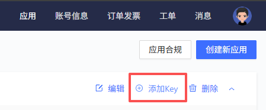

在应用下点击“添加Key”。

3**填写名称，选择Web服务并提交**

填写 Key 名称，服务平台选择 **Web 服务**，确认协议后提交。[官方申请说明](https://lbs.amap.com/api/webservice/guide/create-project/get-key)

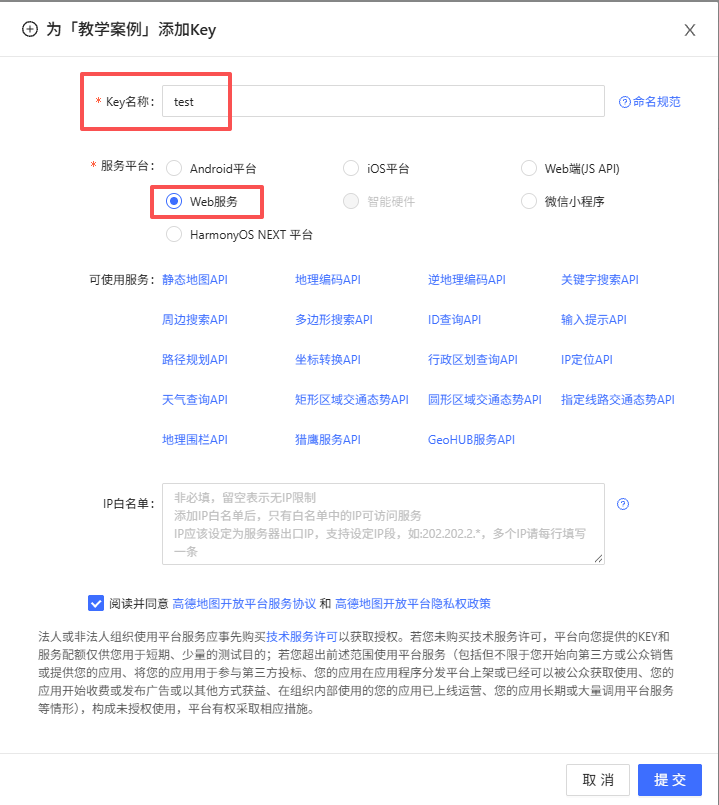

填写Key名称，服务平台选择“Web服务”，随后提交。

4**查看Key并保存到本地**

在应用的 Key 栏复制密钥，保存到本地环境配置。截图已打码，课程代码使用占位符。

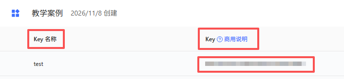

在Key列表中取得生成的值。图中内容已打码。

**R 代码：配置 Key、查询与导出按原有六个模块依次运行**

**模块1 · 在本地配置并读取Key**

在R Console运行下面一行，打开用户目录中的`.Renviron`文件。

```r
file.edit(path.expand("~/.Renviron"))
```

在文件中添加下面一行，将占位内容替换为刚取得的Web服务Key。保存后重启R，使环境变量生效。

```
AMAP_WEB_KEY=在此填入个人Web服务Key
```

重启后运行读取代码。`nzchar()`返回`TRUE`表示读到了配置值。

```r
amap_key <- Sys.getenv("AMAP_WEB_KEY", unset = "")
nzchar(amap_key)
stopifnot(nzchar(amap_key))
```

**模块2 · 准备查询与坐标处理函数**

以`第5章`为工作目录。空间读写使用`sf`，查询与响应解析还需`curl`、`jsonlite`。下面缓存并载入随课函数，后续可读取本地文件。

```r
library(sf)
amap_helper_dir <- "figures/social-fused-aoi/R"
dir.create(amap_helper_dir, recursive = TRUE, showWarnings = FALSE)
helper_files <- c("amap_coordinates.R", "amap_boundary_tools.R",
                  "coordtransform_LICENSE.txt")
for (filename in helper_files) {
  local_path <- file.path(amap_helper_dir, filename)
  if (!file.exists(local_path)) {
    download.file(paste0("https://dawn-ecnu.github.io/data/social_fused_aoi/",
                         filename), local_path, mode = "wb")
  }
}
source(file.path(amap_helper_dir, "amap_coordinates.R"), encoding = "UTF-8")
source(file.path(amap_helper_dir, "amap_boundary_tools.R"), encoding = "UTF-8")
```

**模块3 · 查询上海市及各区的边界**

上海行政代码为`310000`，闵行、普陀分别为`310112`、`310107`。辅助函数先取得区代码清单，再分别查询各区边界，并将GCJ-02坐标作近似WGS84转换。

```r
amap_boundaries <- query_amap_shanghai(api_key = amap_key)
rm(amap_key)
```

行政区域接口的`subdistrict`控制返回下级列表的层数。`extensions = "all"`返回**当前查询区域**的边界，取得16个区的边界需逐区查询。[行政区域查询文档](https://lbs.amap.com/api/webservice/guide/api/district/)

**模块4 · 检查返回的要素与坐标**

当前上海市界应有1个要素，区界有16个要素，研究区含闵行、普陀2个要素。继续核对几何有效性、研究区代码和坐标声明。

```r
stopifnot(
  nrow(amap_boundaries$shanghai_city) == 1L,
  nrow(amap_boundaries$shanghai_districts) == 16L,
  nrow(amap_boundaries$study_area) == 2L,
  all(st_is_valid(amap_boundaries$shanghai_city)),
  all(st_is_valid(amap_boundaries$shanghai_districts)),
  st_crs(amap_boundaries$study_area)$epsg == 4326L,
  identical(sort(amap_boundaries$study_area$district_code),
            c("310107", "310112"))
)
amap_boundaries$study_area[, c("district_name", "district_code")]
```

**模块5 · 写出三份GeoJSON与来源记录**

本次在线查询写入`data/amap_api_example/`。每个对象保存为一个GeoJSON，查询日期与坐标处理方式另存为来源JSON。

```r
api_cache_dir <- "data/amap_api_example"
dir.create(api_cache_dir, recursive = TRUE, showWarnings = FALSE)

# 上海市界。
st_write(amap_boundaries$shanghai_city,
  file.path(api_cache_dir, "shanghai_city.geojson"),
  delete_dsn = TRUE, quiet = TRUE,
  layer_options = c("RFC7946=YES", "COORDINATE_PRECISION=10"))

# 上海16区边界。
st_write(amap_boundaries$shanghai_districts,
  file.path(api_cache_dir, "shanghai_districts.geojson"),
  delete_dsn = TRUE, quiet = TRUE,
  layer_options = c("RFC7946=YES", "COORDINATE_PRECISION=10"))

# 闵行与普陀研究区。
st_write(amap_boundaries$study_area,
  file.path(api_cache_dir, "study_area.geojson"),
  delete_dsn = TRUE, quiet = TRUE,
  layer_options = c("RFC7946=YES", "COORDINATE_PRECISION=10"))

jsonlite::write_json(amap_boundaries$provenance,
  file.path(api_cache_dir, "boundary_provenance.json"),
  pretty = TRUE, auto_unbox = TRUE)
```

**模块6 · 回读导出的文件**

后续使用时直接读取GeoJSON即可。先回读刚写出的文件，核对要素数和研究区名称，确认查询、导出与读取形成完整流程。

```r
city_check <- st_read(file.path(api_cache_dir, "shanghai_city.geojson"),
                      quiet = TRUE)
districts_check <- st_read(file.path(api_cache_dir, "shanghai_districts.geojson"),
                           quiet = TRUE)
study_check <- st_read(file.path(api_cache_dir, "study_area.geojson"),
                       quiet = TRUE)
stopifnot(nrow(city_check) == 1L, nrow(districts_check) == 16L,
          nrow(study_check) == 2L, all(st_is_valid(study_check)))
study_check[, c("district_name", "district_code")]
```

高德返回的`polyline`以分号分隔坐标对，以竖线`|`分隔不同地块。辅助函数完成地块解析与近似坐标逆变换，`st_transform()`用于依据已声明空间参考系统转换投影。坐标模型的往返残差描述内部一致性，外部位置精度还需独立核验。[高德坐标体系说明](https://developer.amap.com/faq/advisory/others/39838) · [坐标模型与MIT许可](https://github.com/wandergis/coordtransform)

课堂主分析读取`data/social_fused_aoi/`中2026年11月8日查询并核验的固定边界。本次查询保存在`data/amap_api_example/`，便于与课堂数据对照。取数日期与底层边界更新日期分别记录，接口未说明后者。

[查询辅助函数](https://dawn-ecnu.github.io/data/social_fused_aoi/amap_boundary_tools.R) · [坐标转换函数](https://dawn-ecnu.github.io/data/social_fused_aoi/amap_coordinates.R) · [坐标模型许可](https://dawn-ecnu.github.io/data/social_fused_aoi/coordtransform_LICENSE.txt)

**CTAmap：选择年度行政区边界选学 · 年度快照与来源对照**

CTAmap v2.0提供2000—2026年省、地、县三级年度行政区划文件，采用**CC BY 4.0**许可。发布者声明坐标为**WGS84（EPSG:4326）**，年份Y表示Y年1月1日的区划状态。选择2025年图层时，其时间含义为2025年年初。数据引用使用Zenodo DOI，作者页面所列配套论文当前标为修订中。[版本与快照说明](https://www.shengshixian.com/pages/9f2c41/) · [数据集DOI](https://doi.org/10.5281/zenodo.22179207)

以下示例读取2025年县级GeoPackage，再按`区划码`提取上海及两个研究区。首次下载约64MB，之后读取本地文件。代码将候选研究区另存为`ctamap_2025_study_area.geojson`，可用于来源对照。[作者下载页](https://www.shengshixian.com/pages/d35ae5/)

```r
# 模块1. 下载带版本标识的GeoPackage并核对发布者校验值。
library(sf)
library(dplyr)
dir.create("data/ctamap", recursive = TRUE, showWarnings = FALSE)
ctamap_path <- "data/ctamap/T2025_county.gpkg"
ctamap_url <- paste0("https://zenodo.org/api/records/22179207/files/",
  "T2025_county.gpkg/content")
if (!file.exists(ctamap_path)) download.file(ctamap_url, ctamap_path, mode = "wb")
stopifnot(unname(tools::md5sum(ctamap_path)) == "3ddd0050b10c9984fe4cf3e8532519b3")

# 模块2. 读取县级区界，按六位代码选择上海与两研究区。
ctamap_counties <- sf::st_read(ctamap_path, quiet = TRUE)
ctamap_shanghai <- ctamap_counties %>%
  filter(substr(as.character(`区划码`), 1, 2) == "31")
ctamap_study <- ctamap_shanghai %>%
  filter(as.character(`区划码`) %in% c("310112", "310107")) %>%
  mutate(district_code = as.character(`区划码`), district_name = `地名`,
    slug = if_else(district_code == "310112", "minhang", "putuo"))
stopifnot(nrow(ctamap_study) == 2L, sf::st_crs(ctamap_study)$epsg == 4326L,
  all(sf::st_is_valid(ctamap_study)))
sf::st_write(ctamap_study, "data/ctamap/ctamap_2025_study_area.geojson",
  delete_dsn = TRUE, quiet = TRUE)
```

年度快照、取数日期与坐标处理方法共同构成边界的来源信息。高德缓存和CTAmap的时间口径与生产过程不同。更换边界时，应重新检查点落区、有效评价网格与AOI范围，保留文件版本、许可和处理记录。

**研究区定位**

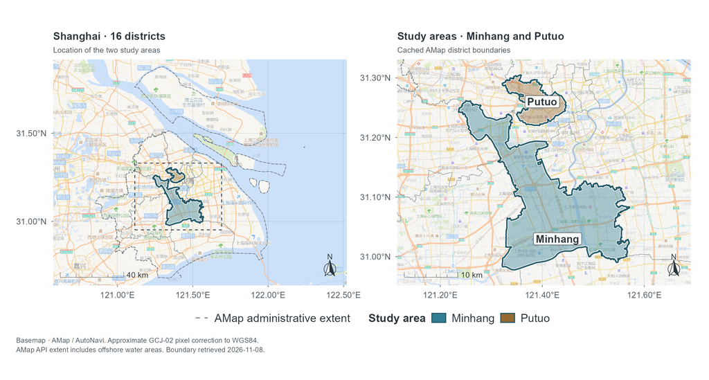

上海市及闵行、普陀两研究区。高德行政范围与底图陆地海岸线的表达范围存在差异。

**研究区定位图 R 代码复现地图 · 分模块查看与复制**

> 这段地图代码还需两份高德底图缓存：basemap/city_amap_corrected.png 与 basemap/study_amap_corrected.png。上方下载表尚未包含这两份文件。

**模块 1：UTF-8、R包与数据路径。** 除这里载入的四个包外，还使用`ggspatial`与`png`的具名函数；首次使用时需在Console安装缺少的包。

```r
# 统一字符编码，避免中文路径或标签在Windows下乱码。
invisible(Sys.setlocale("LC_CTYPE", ".UTF-8"))
library(sf)         # 读取与转换空间边界
library(dplyr)      # 使用管道整理属性
library(ggplot2)    # 组合底图、边界与标注图层
library(patchwork)  # 排列左右地图并集中图例

# 以“第5章”为工作目录；后续相对路径都从这里开始。
data_dir <- "data/social_fused_aoi"
```

**模块 2：读取边界并计算视野。** 三份边界统一转换到EPSG:3857；`pad`控制地图四周的留白。

```r
# 由边界范围计算固定比例的地图窗口，避免两图视野随意变化。
interval_window <- function(boundary_display, pad = 1.20, aspect = 1.30) {
  # st_bbox()提取xmin、xmax、ymin、ymax四个边界值。
  bounds <- st_bbox(boundary_display)
  centre_x <- mean(bounds[c("xmin", "xmax")])
  centre_y <- mean(bounds[c("ymin", "ymax")])

  # 同时满足指定宽高比和边界覆盖范围，再按pad向外扩展。
  height <- max(
    (bounds[["xmax"]] - bounds[["xmin"]]) / aspect,
    bounds[["ymax"]] - bounds[["ymin"]]
  ) * pad
  c(
    xmin = unname(centre_x - height * aspect / 2),
    xmax = unname(centre_x + height * aspect / 2),
    ymin = unname(centre_y - height / 2),
    ymax = unname(centre_y + height / 2)
  )
}

# st_read()读取GeoJSON；st_transform(3857)将边界转换到Web墨卡托，
# 使行政边界能够与使用同一坐标系的底图准确叠合。
boundaries <- st_read(file.path(data_dir, "study_area.geojson"),
                      quiet = TRUE) %>% st_transform(3857)
shanghai_districts <- st_read(file.path(data_dir, "shanghai_districts.geojson"),
                              quiet = TRUE) %>% st_transform(3857)
shanghai_city <- st_read(file.path(data_dir, "shanghai_city.geojson"),
                         quiet = TRUE) %>% st_transform(3857)

# 命名向量把数据中的英文标识转换为图面使用的区名。
district_labels <- c(minhang = "Minhang", putuo = "Putuo")
locator_windows <- list(
  city = interval_window(shanghai_districts, pad = 1.07),
  study = interval_window(boundaries, pad = 1.16)
)
```

**模块 3：读取底图并适配页面主题。** 两张PNG已经与边界视野对齐；深色模式调整底图明度，随后叠加页面底色。

```r
# lapply()对city和study各执行一次：读取底图，并保存其空间范围。
locator_rasters <- lapply(names(locator_windows), function(name) {
  list(
    # readPNG()返回高度×宽度×颜色通道的数值数组。
    image = png::readPNG(file.path(
      data_dir, "basemap", paste0(name, "_amap_corrected.png")
    )),
    window = locator_windows[[name]]
  )
})
names(locator_rasters) <- names(locator_windows)

# alpha越大，底图原色保留越多；其余部分与地图面板底色混合。
locator_basemap_alpha <- c(light = .50, dark = .55)

theme_basemap <- function(raster, theme, alpha, panel_colour) {
  image <- raster$image
  # col2rgb()把十六进制颜色转成0—255的RGB，再缩放到0—1。
  background <- as.numeric(grDevices::col2rgb(panel_colour)) / 255
  if (theme == "dark") {
    # 用加权亮度调整暗色底图，同时保留道路与水系的色彩差异。
    luminance <- .2126 * image[, , 1] + .7152 * image[, , 2] +
      .0722 * image[, , 3]
    contrast <- pmin(1 - luminance, .45) * .38
    for (channel in 1:3) {
      chroma <- image[, , channel] - luminance
      image[, , channel] <- pmin(1, pmax(0,
        background[channel] + contrast + chroma * .80))
    }
  }
  # 分别混合红、绿、蓝三个通道，控制底图在面板中的显眼程度。
  for (channel in 1:3) {
    image[, , channel] <- image[, , channel] * alpha +
      background[channel] * (1 - alpha)
  }
  # as.raster()把数值数组转换为annotation_raster()可绘制的栅格对象。
  list(image = grDevices::as.raster(image), bounds = raster$window)
}
```

**模块 4：设置浅深色配色。** 两套主题共用几何、视野和图层顺序。

```r
# 将颜色集中保存在命名列表中，后续函数通过fused_palette调用。
# ink用于主要文字，muted用于次要文字，boundary_halo用于边界外侧衬线。
palettes <- list(
  light = list(
    background = "transparent", panel = "#F3F3F2", land = "#E6E7E5",
    ink = "#29353A", muted = "#4A555D", boundary = "#265A68",
    boundary_halo = "#FFFFFF", graticule = "#788E95",
    study_minhang = "#2F7E93", study_putuo = "#956A31",
    context_line = "#8A989A", city_boundary = "#555B62"
  ),
  dark = list(
    background = "transparent", panel = "#27262A", land = "#36363A",
    ink = "#F1EDF1", muted = "#CAC3CD", boundary = "#9FDEEB",
    boundary_halo = "#211F25", graticule = "#A8A1B0",
    study_minhang = "#71C8D6", study_putuo = "#E8BB78",
    context_line = "#817C88", city_boundary = "#D5CED8"
  )
)
```

**模块 5：建立底图图层与经纬网。** `map_base()`把PNG放入对应空间范围，`map_graticule()`计算经纬度刻度和网格线。

```r
map_base <- function(window, basemap, boundary_display) {
  # annotation_raster()把图片按左、右、下、上四个坐标铺到地图中。
  ggplot() + annotation_raster(
    basemap$image,
    basemap$bounds[["xmin"]], basemap$bounds[["xmax"]],
    basemap$bounds[["ymin"]], basemap$bounds[["ymax"]]
  )
}

map_graticule <- function(window) {
  # 先将地图窗口建立为3857矩形，再转换到4326计算经纬度范围。
  frame <- st_as_sfc(st_bbox(
    window[c("xmin", "ymin", "xmax", "ymax")], crs = st_crs(3857)
  ))
  geographic_bounds <- st_bbox(st_transform(frame, 4326))
  # pretty()选择便于阅读的刻度；n = 4是目标数量，并非严格固定为4个。
  longitude <- pretty(unname(geographic_bounds[c("xmin", "xmax")]), n = 4)
  latitude <- pretty(unname(geographic_bounds[c("ymin", "ymax")]), n = 4)
  longitude <- longitude[longitude > geographic_bounds[["xmin"]] &
                           longitude < geographic_bounds[["xmax"]]]
  latitude <- latitude[latitude > geographic_bounds[["ymin"]] &
                         latitude < geographic_bounds[["ymax"]]]
  # st_graticule()生成经纬网几何；这些曲线随后作为普通空间图层绘制。
  lines <- st_graticule(
    frame, crs = st_crs(3857), datum = st_crs(4326),
    lon = longitude, lat = latitude
  )
  # 同时返回刻度位置和网格线，供坐标轴与地图图层共同使用。
  list(longitude = longitude, latitude = latitude, lines = lines)
}
```

**模块 6A：设置经纬度坐标与地图范围。**

```r
add_map_coordinates <- function(plot, graticule, window) {
  plot +
    # 只替换刻度文字：保留两位小数，并标明东经E和北纬N。
    scale_x_continuous(breaks = graticule$longitude,
                       labels = function(x) sprintf("%.2f°E", x)) +
    scale_y_continuous(breaks = graticule$latitude,
                       labels = function(y) sprintf("%.2f°N", y)) +
    # crs/default_crs控制地图显示坐标；datum指定经纬网使用的基准坐标。
    # expand = FALSE取消视野四周的自动扩展，保持与底图边缘对齐。
    coord_sf(
      crs = st_crs(3857), default_crs = st_crs(3857), datum = st_crs(4326),
      label_axes = list(bottom = "E", left = "N"),
      xlim = window[c("xmin", "xmax")], ylim = window[c("ymin", "ymax")],
      expand = FALSE
    )
}
```

**模块 6B：添加比例尺与真北指北针。**

```r
add_map_furniture <- function(plot) {
  plot +
    # 比例尺位于左下（bl）；width_hint给出其占面板宽度的目标比例。
    ggspatial::annotation_scale(
      location = "bl", width_hint = .23, style = "ticks",
      unit_category = "metric", line_col = fused_palette$ink,
      text_col = fused_palette$ink, text_family = "Arial", text_cex = .95,
      line_width = .55, pad_x = grid::unit(.14, "in"),
      pad_y = grid::unit(.16, "in")
    ) +
    # 指北针位于右下（br）；grid::unit()用英寸固定其图形尺寸。
    ggspatial::annotation_north_arrow(
      location = "br", which_north = "true",
      height = grid::unit(.45, "in"), width = grid::unit(.39, "in"),
      pad_x = grid::unit(.14, "in"), pad_y = grid::unit(.14, "in"),
      style = ggspatial::north_arrow_fancy_orienteering(
        line_col = fused_palette$ink,
        fill = c(fused_palette$panel, fused_palette$ink),
        text_col = fused_palette$ink, text_family = "Arial", text_size = 11
      )
    )
}
```

**模块 6C：设置文字、背景、坐标轴与图例主题。**

```r
add_map_theme <- function(plot) {
  plot +
    # 先载入简洁主题，再逐项覆盖颜色、字号和边距。
    theme_minimal(base_family = "Arial", base_size = 15) +
    theme(
      # panel.background是地图区域底色；plot.background保持透明以融入网页。
      panel.background = element_rect(fill = fused_palette$panel, colour = NA),
      plot.background = element_rect(fill = "transparent", colour = NA),
      panel.grid = element_blank(), panel.border = element_blank(),
      axis.title = element_blank(),
      axis.text = element_text(colour = fused_palette$muted, size = 12),
      axis.ticks = element_line(colour = fused_palette$muted, linewidth = .35),
      plot.title = element_text(colour = fused_palette$ink, face = "bold", size = 16),
      plot.subtitle = element_text(colour = fused_palette$muted, size = 12),
      axis.ticks.length = grid::unit(2.5, "pt"),
      plot.margin = margin(8, 11, 8, 8),
      legend.title = element_text(size = 14), legend.text = element_text(size = 13)
    ) +
    # 第二个theme()集中控制图例位置，并覆盖单图的标题字号。
    theme(
      legend.position = "bottom", legend.direction = "horizontal",
      legend.box = "horizontal",
      legend.background = element_rect(fill = "transparent", colour = NA),
      legend.key = element_rect(fill = "transparent", colour = NA),
      legend.title = element_text(colour = fused_palette$ink),
      legend.text = element_text(colour = fused_palette$ink),
      plot.title = element_text(size = 15, face = "bold"),
      plot.subtitle = element_text(size = 11)
    )
}
```

**模块 6D：依次组合经纬网、边界、坐标、地图元素与主题。** `annotation_theme()`另用于组合图的标题和来源说明。

```r
map_frame <- function(plot, reference) {
  # reference集中传入当前面板的边界与视野，减少重复参数。
  window <- reference$window
  boundary_display <- reference$boundary
  # 未明确写FALSE时默认描边；全市图会关闭最外层重复描边。
  draw_boundary <- !identical(reference$draw_boundary, FALSE)
  graticule <- map_graticule(window)
  framed <- plot +
    # inherit.aes = FALSE避免经纬网继承点或面图层的审美映射。
    geom_sf(data = graticule$lines, inherit.aes = FALSE,
            colour = fused_palette$graticule, linewidth = .22,
            alpha = .36, show.legend = FALSE)
  if (draw_boundary) {
    # 先画较粗、较浅的衬线，再画主边界，使区界在复杂底图上仍清楚。
    framed <- framed +
      geom_sf(data = boundary_display, fill = NA,
              colour = fused_palette$boundary_halo, linewidth = 1.65) +
      geom_sf(data = boundary_display, fill = NA,
              colour = fused_palette$boundary, linewidth = .95)
  }
  framed <- add_map_coordinates(framed, graticule, window)
  framed <- add_map_furniture(framed)
  add_map_theme(framed)
}

annotation_theme <- function() {
  theme(
    text = element_text(family = "Arial", colour = fused_palette$ink),
    plot.title = element_text(size = 24, face = "bold", colour = fused_palette$ink),
    plot.subtitle = element_text(size = 14, colour = fused_palette$muted),
    plot.caption = element_text(size = 11, hjust = 0, colour = fused_palette$muted),
    plot.background = element_rect(fill = "transparent", colour = NA),
    plot.margin = margin(13, 15, 13, 15)
  )
}
```

**模块 7：准备区名标签与图例。** 标签坐标放在两区内部，并用`st_within()`核对空间归属。

```r
make_labels <- function() {
  # st_as_sf()把经纬度表格转换为点数据；原始经纬度声明为EPSG:4326。
  labels <- st_as_sf(
    data.frame(slug = c("minhang", "putuo"),
               longitude = c(121.43, 121.40), latitude = c(31.03, 31.26)),
    coords = c("longitude", "latitude"), crs = 4326
  ) %>% st_transform(3857)
  # vapply()逐点检查；st_within()确认每个标签只落入对应区界一次。
  stopifnot(all(vapply(seq_len(nrow(labels)), function(index) {
    lengths(st_within(labels[index, ],
      boundaries[boundaries$slug == labels$slug[index], ])) == 1L
  }, logical(1))))
  labels$label <- unname(district_labels[labels$slug])
  labels
}

make_scales <- function() {
  # 手工标度把每个区名固定映射到指定颜色，避免自动配色发生变化。
  study_scale <- scale_fill_manual(
    name = "Study area",
    values = c(Minhang = fused_palette$study_minhang,
               Putuo = fused_palette$study_putuo),
    # override.aes只修改图例符号，不改变地图中研究区的透明度。
    guide = guide_legend(nrow = 1, byrow = TRUE, order = 2,
      override.aes = list(alpha = 1, colour = fused_palette$boundary,
                          linewidth = .7))
  )
  city_scale <- scale_colour_manual(
    name = NULL,
    values = c("AMap administrative extent" = fused_palette$city_boundary),
    guide = guide_legend(order = 1,
      override.aes = list(linewidth = .75, alpha = .70, linetype = "dashed"))
  )
  list(study = study_scale, city = city_scale)
}
```

**模块 8：绘制左侧上海市定位图。** 图层依次加入16区边界、研究区填色与描边、右图视野框和上海市界。

```r
make_city_plot <- function() {
  # 将右图视野转换成矩形，在左图中标出放大区域的位置。
  study_box <- st_as_sfc(st_bbox(
    study_window[c("xmin", "ymin", "xmax", "ymax")], crs = st_crs(3857)
  ))
  plot <- map_base(city_window, locator_basemaps$city, shanghai_city) +
    geom_sf(data = shanghai_districts, fill = NA,
            colour = fused_palette$context_line, linewidth = .24, alpha = .8) +
    # aes(fill = study_area)映射研究区颜色，alpha保留底图细节。
    geom_sf(data = locator_boundaries, aes(fill = study_area),
            colour = NA, alpha = .40) +
    geom_sf(data = locator_boundaries, fill = NA,
            colour = fused_palette$boundary_halo, linewidth = 1.65) +
    geom_sf(data = locator_boundaries, fill = NA,
            colour = fused_palette$boundary, linewidth = .95) +
    scales$study +
    geom_sf(data = study_box, fill = NA, colour = fused_palette$ink,
            linewidth = .5, linetype = "dashed") +
    labs(title = "Shanghai · 16 districts",
         subtitle = "Location of the two study areas") +
    geom_sf(data = shanghai_city, aes(colour = "AMap administrative extent"),
            fill = NA, linewidth = .34, alpha = .70,
            linetype = "dashed", key_glyph = "path") +
    scales$city
  map_frame(plot, list(
    boundary = shanghai_city, window = city_window, draw_boundary = FALSE
  ))
}
```

**模块 9：绘制右侧研究区放大图。** 使用相同图层结构，并在最后添加区名标签。

```r
make_study_plot <- function() {
  plot <- map_base(study_window, locator_basemaps$study, shanghai_city) +
    geom_sf(data = shanghai_districts, fill = NA,
            colour = fused_palette$context_line, linewidth = .26, alpha = .8) +
    geom_sf(data = shanghai_city, aes(colour = "AMap administrative extent"),
            fill = NA, linewidth = .34, alpha = .70,
            linetype = "dashed", key_glyph = "path") +
    scales$city +
    # aes(fill = study_area)映射研究区颜色，alpha保留底图细节。
    geom_sf(data = locator_boundaries, aes(fill = study_area),
            colour = NA, alpha = .40) +
    geom_sf(data = locator_boundaries, fill = NA,
            colour = fused_palette$boundary_halo, linewidth = 1.65) +
    geom_sf(data = locator_boundaries, fill = NA,
            colour = fused_palette$boundary, linewidth = .95) +
    scales$study +
    labs(title = "Study areas · Minhang and Putuo",
         subtitle = "Cached AMap district boundaries")
  map_frame(plot, list(boundary = boundaries, window = study_window)) +
    # geom_sf_label()按点的空间位置放置带底色的区名标签。
    geom_sf_label(
      data = labels, aes(label = label), colour = fused_palette$ink,
      fill = if (figure_theme == "light") "#FFFFFFEB" else "#211F25EB",
      family = "Arial", size = 5.3, fontface = "bold", linewidth = .25,
      label.padding = grid::unit(.18, "lines"),
      label.r = grid::unit(.12, "lines")
    )
}
```

**模块 10：组合左右地图并集中图例。**

```r
assemble_locator <- function() {
  # patchwork用+连接左右面板；ncol = 2表示一行两列。
  # guides = "collect"把相同图例合并，避免左右图重复显示。
  city_plot + framed_study +
    plot_layout(ncol = 2, guides = "collect") +
    # plot_annotation()为整幅组合图添加统一来源说明。
    plot_annotation(
      caption = paste0(
        "Basemap · AMap / AutoNavi. Approximate GCJ-02 pixel correction to WGS84.",
        "\nAMap API extent includes offshore water areas. Boundary retrieved 2026-11-08."
      ),
      theme = annotation_theme() + theme(plot.caption = element_text(
        colour = fused_palette$muted, size = 10, hjust = 0, lineheight = 1.1
      ))
    ) &
    # &把同一主题应用到组合图中的所有面板，而不是只修改最后一个面板。
    theme(
      legend.position = "bottom", legend.direction = "horizontal",
      legend.box = "horizontal", panel.border = element_blank(),
      legend.title = element_text(colour = fused_palette$ink, size = 16, face = "bold"),
      legend.text = element_text(colour = fused_palette$ink, size = 16),
      legend.key.width = grid::unit(.30, "in"),
      legend.key.height = grid::unit(.18, "in"),
      legend.background = element_rect(fill = "transparent", colour = NA),
      legend.key = element_rect(fill = "transparent", colour = NA)
    )
}
```

**模块 11：选择主题并直接显示地图。** 默认使用浅色主题；将第一行改为`figure_theme <- "dark"`即可切换为深色。最后的`locator`会在Plots面板显示组合图，不执行`ggsave()`。

```r
figure_theme <- "light"             # 可改为"dark"
fused_palette <- palettes[[figure_theme]]
city_window <- locator_windows$city
study_window <- locator_windows$study

# 准备当前主题共用的标签、研究区属性和图例。
labels <- make_labels()
locator_boundaries <- boundaries
# factor()的levels固定图例顺序为Minhang、Putuo，与手工配色对应。
locator_boundaries$study_area <- factor(
  district_labels[locator_boundaries$slug], levels = c("Minhang", "Putuo")
)
scales <- make_scales()

# 分别处理全市与研究区底图，再生成左右两个面板。
locator_basemaps <- lapply(names(locator_windows), function(name) {
  theme_basemap(
    locator_rasters[[name]], figure_theme,
    locator_basemap_alpha[[figure_theme]], fused_palette$panel
  )
})
names(locator_basemaps) <- names(locator_windows)
city_plot <- make_city_plot()
framed_study <- make_study_plot()

# 单独列出最终对象，运行本块后即可在Plots面板查看。
locator <- assemble_locator()
locator
```

**记录字段与交通 POI**

| 字段 | 含义 | 本例用途 |
| --- | --- | --- |
| `posted_at` | 源记录发布日期或发布时间 | 限定2023—2025年。 |
| `x`、`y` | 经度、纬度，单位为度 | 建立空间点。 |
| `user_id` | 平台内一致的匿名替代编号 | 识别同账号重复记录，计算聚类稳健标准误。 |
| `platform` | 微博或小红书 | 核对来源构成，区分平台内账号。 |

> 微博时间保留到时分秒，小红书仅有发布日期，源字段未带时区标记。

**准备全市交通POI**

从[课程数据页](https://dawn-ecnu.github.io/data/)下载 `公交站.geojson`、`地铁站.geojson`，放入 `data/`。保留全市候选点，以免漏掉邻区的最近设施。

**统一分析坐标系**

经纬度数据按 EPSG:4326 / CRS84 读取，统一转为 **EPSG:32651（WGS84 / UTM 51N）** 米制投影，计算面积与距离；地图显示采用 EPSG:3857。

**© 华东师范大学 社会发展学院 人口研究所** | [**DAWN 研究组**](https://dawn-ecnu.github.io) | yzliu@soci.ecnu.edu.cn

课程负责人：刘贇喆 本章作者：刘贇喆 | 敖漪宇

最后更新：2026年11月13日 构建环境：R version 4.6.1 (2026-06-24 ucrt)

[CC BY-NC-SA 4.0](https://creativecommons.org/licenses/by-nc-sa/4.0/deed.zh) 回到顶部

##### 数据整理

###### **4.3 核对范围、来源与重复记录**

核对三年记录的**范围与来源**，观察**账号贡献**及**空间分布**。

**整理年份、坐标与区属整理数据 · 两个模块依次运行**

> 先运行 4.2“读取记录与研究区边界”，得到 `social_data` 和 `study_area`。

**统一载包并筛选年份。** `sf` 沿用 4.2；`tidyverse` 在同一 R 会话中只需载入一次。

```r
# 同一R会话已载入tidyverse时，可跳过这一行；后续代码不再重复载包。
library(tidyverse)

# substr()取日期开头四位；as.integer()把年份转换为整数。
social_data <- social_data %>%
  mutate(year = as.integer(substr(posted_at, 1, 4))) %>%
  filter(year %in% 2023:2025)
```

**建立米制空间点并定位区属。** 将点落入的区名与分区代码加入记录表。

```r
# x、y是经纬度；转换为米制投影，并保留原坐标列供后续汇总。
social_points <- st_as_sf(social_data, coords = c("x", "y"),
                          crs = 4326, remove = FALSE) %>%
  st_transform(32651)

# st_join()将相交区界的名称和分区代码带入点表；本例各点均只落在一个区。
social_points <- social_points %>%
  st_join(study_area %>% dplyr::select(district_name, slug),
          join = st_intersects)

# st_drop_geometry()暂时去掉几何列；count()按区、年份和平台统计记录行数。
social_points %>% st_drop_geometry() %>%
  count(district_name, year, platform, name = "n_records")
```

> 按区、年份和平台分组后有 12 行，每行 6,000 条；合并年份与平台后，每区 36,000 条。

**两区的来源构成**

| 研究区 | 微博 | 小红书 | 合计 | 不同坐标数 |
| --- | --- | --- | --- | --- |
| 闵行区 | 18,000(50.0%) | 18,000(50.0%) | 36,000(50.0%) | 7,963(62.4%) |
| 普陀区 | 18,000(50.0%) | 18,000(50.0%) | 36,000(50.0%) | 4,796(37.6%) |
| 合计 | 36,000(100.0%) | 36,000(100.0%) | 72,000(100.0%) | 12,759(100.0%) |

括号为各列合计占比；不同坐标数按经纬度组合计数。

**来源汇总表 R 代码统计记录与坐标组合 · 添加合计和百分比**

**汇总区内记录与坐标组合。** 原始点表继续保留全部记录。

```r
# factor()固定区名顺序，使表格与地图都先显示闵行、再显示普陀。
record_rows <- social_points %>% st_drop_geometry() %>%
  mutate(district_name = factor(district_name, levels = c("闵行区", "普陀区")))

# n()统计记录行；n_distinct(x, y)统计不同坐标组合，不删除原始记录。
district_summary <- record_rows %>%
  group_by(district_name) %>%
  summarise(weibo = sum(platform == "微博"),
            rednote = sum(platform == "小红书"),
            records = n(), locations = n_distinct(x, y), .groups = "drop")

# 全部记录单独汇总，确保合计中的不同坐标数按全体样本计算。
total_summary <- record_rows %>%
  summarise(district_name = "合计", weibo = sum(platform == "微博"),
            rednote = sum(platform == "小红书"),
            records = n(), locations = n_distinct(x, y))
source_summary <- bind_rows(district_summary, total_summary)
source_summary
```

**将百分比放在数值下方。** 各列统一以合计行为分母；HTML 表格可在 Rmd 中显示。

```r
# across()逐列处理数值；last()取本列合计，计算各区占该列总量的百分比。
display_summary <- source_summary %>%
  mutate(across(-district_name, function(value) {
    sprintf('<span class="cell-value">%s</span><small class="cell-share">(%.1f%%)</small>',
            format(value, big.mark = ",", trim = TRUE),
            100 * value / dplyr::last(value))
  }))

# escape = FALSE保留单元格中的HTML，使百分比显示在数值下方。
source_table <- knitr::kable(display_summary, format = "html", escape = FALSE,
  col.names = c("研究区", "微博", "小红书", "合计", "不同坐标数"),
  align = c("l", "r", "r", "r", "r"))
source_table
```

**账号发文量与样本贡献**

按平台与账号汇总发文量，可观察高频账号在样本中占多大权重。

**发文量排序**

> 账号按发文量从高到低排列；双对数刻度便于同时观察少数高频账号和大量低频账号。

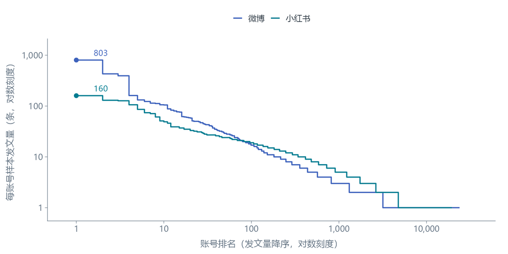

微博共 **23,879** 个账号，最高 **803** 条；小红书共 **19,469** 个账号，最高 **160** 条。两者中位数均为 **1** 条。

**发文量排序图 R 代码汇总账号 · 配置主题 · 绘制排序图**

沿用本节已载入的 `tidyverse` 和整理后的 `social_data`，此处不重复载包。

**统计账号发文量与贡献。** `platform + user_id` 共同识别账号，累计比例按发文量降序计算。

```r
# social_data 来自4.2的数据读取代码；账号编号只在各自平台内识别。
# count()把同一平台、同一账号的记录行加总；这里不按坐标去重。
account_counts <- social_data %>%
  count(platform, user_id, name = "posts") %>%
  mutate(platform = factor(platform, levels = c("微博", "小红书"))) %>%
  group_by(platform) %>%
  # 并列发文量按账号编号排序，保证每次运行的顺序一致。
  arrange(desc(posts), user_id, .by_group = TRUE, .locale = "C") %>%
  mutate(
    rank = row_number(),
    account_pct = 100 * rank / n(),
    record_pct = 100 * cumsum(posts) / sum(posts)
  ) %>%
  ungroup()

# ceiling()向上取整，确定“前1%账号”的人数；cumsum()计算降序累计发文量。
account_summary <- account_counts %>%
  group_by(platform) %>%
  summarise(
    records = sum(posts), accounts = n(), max_posts = max(posts),
    top1pct_n = ceiling(n() * .01),
    top1pct_share = 100 * sum(posts[rank <= ceiling(n() * .01)]) / sum(posts),
    top10pct_n = ceiling(n() * .10),
    top10pct_share = 100 * sum(posts[rank <= ceiling(n() * .10)]) / sum(posts),
    .groups = "drop"
  )
account_summary
```

**统一两张图的主题。** 默认浅色；将 `figure_theme` 改为 `"dark"` 可切换深色。

```r
# 将"light"改为"dark"，即可为深色页面生成相同数据的图。
figure_theme <- "light"
font_family <- "Microsoft YaHei"
account_palettes <- list(
  light = list(text = "#26323D", muted = "#607080", axis = "#607080",
               colours = c("微博" = "#3D62BC", "小红书" = "#007C91")),
  dark = list(text = "#E8EDF2", muted = "#AEB8C2", axis = "#AEB8C2",
              colours = c("微博" = "#90B8FF", "小红书" = "#58D8E7"))
)

# 自定义函数把两张图的字体、坐标轴与透明背景统一，避免重复写样式。
account_plot_theme <- function(ink, small = FALSE) {
  theme_classic(base_family = font_family, base_size = 16) +
    theme(
      text = element_text(colour = ink$text),
      axis.text = element_text(colour = ink$muted, size = if (small) 11 else 13),
      axis.title = element_text(colour = ink$muted, size = 14, face = "plain"),
      axis.title.x = element_text(margin = margin(t = 10)),
      axis.title.y = element_text(margin = margin(r = 10)),
      axis.line = element_line(colour = ink$axis, linewidth = .35),
      axis.ticks = element_line(colour = ink$axis, linewidth = .30),
      legend.position = "top", legend.title = element_blank(),
      legend.text = element_text(size = 13),
      plot.background = element_rect(fill = "transparent", colour = NA),
      panel.background = element_rect(fill = "transparent", colour = NA),
      legend.background = element_rect(fill = "transparent", colour = NA),
      legend.key = element_rect(fill = "transparent", colour = NA),
      plot.margin = margin(12, 20, 8, 10)
    )
}
```

**绘制排序图。** `geom_step()` 显示整数发文量形成的阶梯。

```r
make_account_rank_plot <- function(mode = figure_theme) {
  ink <- account_palettes[[mode]]
  ggplot(account_counts, aes(rank, posts, colour = platform)) +
    # geom_step()保留整数发文量形成的阶梯；每条线包含该平台全部账号。
    geom_step(linewidth = .9, direction = "hv") +
    geom_point(data = filter(account_counts, rank == 1), size = 2.6, show.legend = FALSE) +
    geom_text(data = filter(account_counts, rank == 1), aes(label = posts),
              nudge_x = .2, hjust = 0, vjust = -.7,
              family = font_family, size = 4.5, show.legend = FALSE) +
    scale_colour_manual(values = ink$colours) +
    # 两轴均取log10刻度，便于同时看清高频头部与大量低频账号。
    scale_x_log10(limits = c(.8, max(account_counts$rank) * 1.5),
                  breaks = 10^(0:4), labels = scales::label_comma()) +
    scale_y_log10(limits = c(.8, max(account_counts$posts) * 1.8),
                  breaks = 10^(0:3), labels = scales::label_comma()) +
    labs(x = "账号排名（发文量降序，对数刻度）",
         y = "每账号样本发文量（条，对数刻度）") +
    account_plot_theme(ink)
}
make_account_rank_plot()
```

**高频账号的累计贡献**

按发文量降序累加记录，观察高频账号的贡献。虚线为等比例贡献参照，局部图放大前 10%。

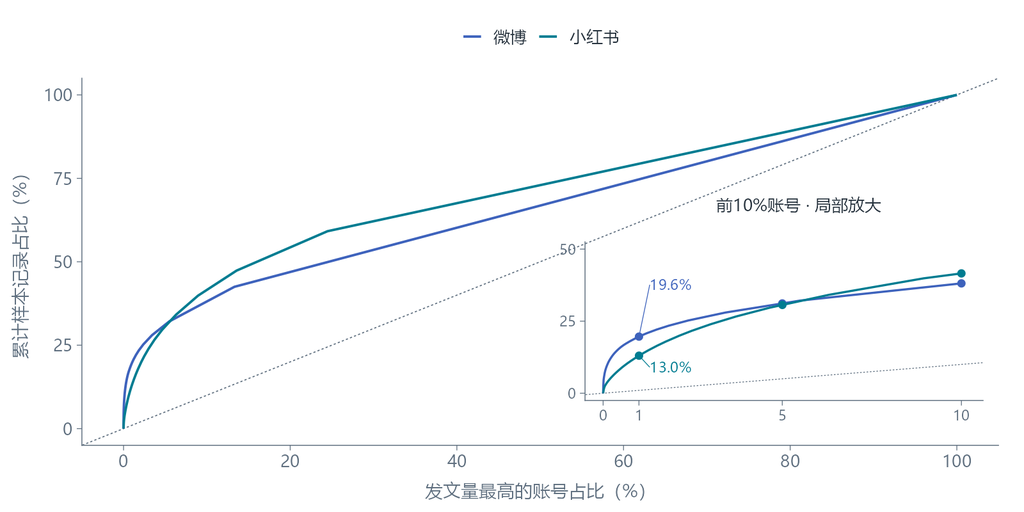

前 **1%** 账号贡献了微博 **19.64%**、小红书 **13.03%** 的记录；扩大到前 **10%** 后，贡献分别为 **38.11%**、**41.57%**。

> 比较结果取决于观察的账号范围：微博最头部的贡献更高，小红书前 10% 的累计贡献更高。

**累计贡献图 R 代码接续上方账号汇总与主题 · 绘制主图和局部放大**

使用上方的 `account_counts`、`account_palettes` 和主题函数。`cowplot::draw_plot()` 按画布比例放入局部图。

```r
make_account_contribution_plot <- function(mode = figure_theme) {
  ink <- account_palettes[[mode]]
  origin <- data.frame(platform = factor(c("微博", "小红书"),
                        levels = c("微博", "小红书")),
                       account_pct = 0, record_pct = 0)
  curve <- account_counts %>%
    select(platform, account_pct, record_pct) %>%
    bind_rows(origin) %>% arrange(platform, account_pct)
  marks <- account_counts %>% group_by(platform) %>%
    # 前1%、5%、10%账号的位置用于局部放大的参考点。
    filter(rank %in% ceiling(n() * c(.01, .05, .10))) %>%
    mutate(target_pct = c(1, 5, 10)) %>% ungroup()
  inset_ymax <- ceiling(max(marks$record_pct) / 10) * 10

  main <- ggplot(curve, aes(account_pct, record_pct, colour = platform)) +
    # 45度虚线表示账号占比与记录占比相等，仅作为参照。
    geom_abline(slope = 1, intercept = 0, colour = ink$axis,
                linetype = "22", linewidth = .4) +
    geom_line(linewidth = .9) +
    scale_colour_manual(values = ink$colours) +
    scale_x_continuous(limits = c(0, 100), breaks = seq(0, 100, 20)) +
    scale_y_continuous(limits = c(0, 100), breaks = seq(0, 100, 25)) +
    labs(x = "发文量最高的账号占比（%）", y = "累计样本记录占比（%）") +
    account_plot_theme(ink)

  first_labels <- filter(marks, target_pct == 1) %>%
    mutate(label_y = record_pct + c(.36, -.08) * inset_ymax)
  inset <- ggplot(filter(curve, account_pct <= 10.1),
                   aes(account_pct, record_pct, colour = platform)) +
    geom_abline(slope = 1, intercept = 0, colour = ink$axis,
                linetype = "22", linewidth = .3) +
    geom_line(linewidth = .8) + geom_point(data = marks, size = 2.1) +
    geom_segment(data = first_labels,
                 aes(xend = account_pct + .3, yend = label_y), linewidth = .3) +
    geom_text(data = first_labels,
              aes(y = label_y, label = sprintf("%.1f%%", record_pct)),
              nudge_x = .3, hjust = 0, family = font_family, size = 4) +
    scale_colour_manual(values = ink$colours) +
    scale_x_continuous(limits = c(0, 10.1), breaks = c(0, 1, 5, 10)) +
    scale_y_continuous(limits = c(0, inset_ymax),
                       breaks = c(0, inset_ymax / 2, inset_ymax)) +
    labs(x = NULL, y = NULL) + account_plot_theme(ink, small = TRUE) +
    theme(legend.position = "none", plot.margin = margin(5, 8, 5, 5))

  # draw_plot()按0—1的画布比例把局部图放在主图右下方的空白处。
  cowplot::ggdraw(main) +
    cowplot::draw_plot(inset, x = .54, y = .16, width = .43, height = .38) +
    cowplot::draw_label("前10%账号 · 局部放大", x = .78, y = .60,
                        fontfamily = font_family, size = 13, colour = ink$text)
}
make_account_contribution_plot()
```

**原始记录的空间分布**

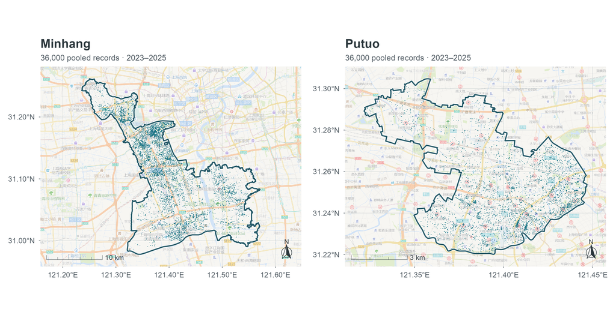

**两区原始记录地图 R 代码复现地图 · 六个模块依次运行**

> 先运行 4.2 的定位图代码，复用配色与地图函数。本图另需 `basemap/minhang_amap_corrected.png`、`basemap/putuo_amap_corrected.png`；现有下载表尚未包含这两份底图。

**模块 1：选择主题并转换坐标。** 点与区界在分析时使用EPSG:32651，绘图前统一转换为底图采用的EPSG:3857。

```r
figure_theme <- "light"  # 改为"dark"可切换深色主题

# 从配色列表中取出当前主题，并补充足迹点专用颜色。
fused_palette <- palettes[[figure_theme]]
fused_palette$points <- if (figure_theme == "light") "#1F7787" else "#70D2DD"

# 保留全部72,000条记录，不按坐标去重，也不抽样。
# 点与区界统一转换到EPSG:3857，以匹配底图的坐标参考系。
map_points <- st_transform(social_points, 3857)
map_boundaries <- st_transform(study_area, 3857)

# 向量名称是内部分区代码，向量值是地图标题使用的英文区名。
district_labels <- c(minhang = "Minhang", putuo = "Putuo")
```

**模块 2：计算两区视野并读取对应底图。** `pad = 1.14`在区界四周保留空间；底图范围与地图窗口一一对应。

```r
# names(district_labels)依次给出"minhang"与"putuo"，逐区计算视野。
point_windows <- lapply(names(district_labels), function(slug) {
  boundary <- map_boundaries[map_boundaries$slug == slug, ]
  # pad = 1.14将区界包围框扩大14%，避免边界贴近图框。
  interval_window(boundary, pad = 1.14)
})
names(point_windows) <- names(district_labels)

# 每份底图都与对应视野一起保存，供annotation_raster()确定摆放范围。
# readPNG()返回包含颜色通道的数值数组，而不是sf空间对象。
point_rasters <- lapply(names(district_labels), function(slug) {
  list(
    image = png::readPNG(file.path(
      data_dir, "basemap", paste0(slug, "_amap_corrected.png")
    )),
    window = point_windows[[slug]]
  )
})
names(point_rasters) <- names(district_labels)
```

**模块 3：调整底图明度。** 点图需要看清密集足迹，因此底图透明度低于定位图，避免底图颜色盖过点位。

```r
# 分别为浅色、深色主题设置底图不透明度；数值越小，底图越淡。
point_alpha <- c(light = .42, dark = .45)

# theme_basemap()调整颜色通道，并将底图与当前面板背景色混合。
point_basemaps <- lapply(names(district_labels), function(slug) {
  theme_basemap(
    point_rasters[[slug]], figure_theme,
    alpha = point_alpha[[figure_theme]], panel_colour = fused_palette$panel
  )
})
names(point_basemaps) <- names(district_labels)
```

**模块 4：定义单区点图函数。** 每区使用自己的视野和边界；`size`控制点径，`alpha`让重叠位置自然加深。

```r
# 输入分区代码，函数返回该区的一幅完整ggplot地图。
make_point_panel <- function(slug) {
  # 按slug同时筛选区界和记录点，保证两者属于同一研究区。
  boundary <- map_boundaries[map_boundaries$slug == slug, ]
  district_points <- map_points[map_points$slug == slug, ]

  # map_base()先放置底图，geom_sf()随后叠加全部记录点。
  plot <- map_base(point_windows[[slug]], point_basemaps[[slug]], boundary) +
    # size控制点径，alpha让重叠位置加深；stroke = 0取消点边缘。
    geom_sf(
      data = district_points, colour = fused_palette$points,
      size = .44, alpha = if (figure_theme == "light") .75 else .60,
      stroke = 0
    ) +
    # labs()设置当前面板的区名标题与样本说明。
    labs(
      title = district_labels[[slug]],
      subtitle = "36,000 pooled records · 2023–2025"
    )

  # 复用4.2的经纬网、区界、比例尺、指北针和主题函数。
  map_frame(plot, list(boundary = boundary, window = point_windows[[slug]])) +
    # 在通用地图主题上，进一步调整点图标题与副标题字号。
    theme(
      plot.title = element_text(colour = fused_palette$ink, size = 20, face = "bold"),
      plot.subtitle = element_text(colour = fused_palette$muted, size = 13)
    )
}
```

**模块 5：分别绘制闵行与普陀。** 两个面板各自保留完整坐标轴与地图整饰。

```r
# 对两个分区代码依次调用make_point_panel()，得到两个ggplot对象。
point_panels <- lapply(names(district_labels), make_point_panel)

# 保留分区名称，之后可用point_panels$minhang或$putuo单独查看。
names(point_panels) <- names(district_labels)
```

**模块 6：左右排列并显示组合地图。** `wrap_plots()`将两个单区面板并排排列，`guides = "keep"`保留各区独立的图例与地图整饰。

```r
# wrap_plots()把列表中的ggplot对象按两列拼接；keep表示不合并图例。
points_map <- wrap_plots(point_panels, ncol = 2, guides = "keep") +
  # plot_annotation()设置整幅组合图的共享属性，这里使用透明背景。
  plot_annotation(
    theme = theme(plot.background = element_rect(fill = "transparent", colour = NA))
  )

# 单独写出对象名，即可在RStudio的Plots面板显示组合地图。
points_map
```

**© 华东师范大学 社会发展学院 人口研究所** | [**DAWN 研究组**](https://dawn-ecnu.github.io) | yzliu@soci.ecnu.edu.cn

课程负责人：刘贇喆 本章作者：刘贇喆 | 敖漪宇

最后更新：2026年11月13日 构建环境：R version 4.6.1 (2026-06-24 ucrt)

[CC BY-NC-SA 4.0](https://creativecommons.org/licenses/by-nc-sa/4.0/deed.zh) 回到顶部

##### 点KDE

###### **4.4 各区合并记录的核密度估计**

每区合并三年、两平台的 **36,000 条记录**，分别估计二维高斯核密度（KDE），观察区内的空间集中位置。

**带宽与求值精度**

**自动带宽**根据各区点位，分别选择 X、Y 方向的平滑尺度。

**求值精度**`512 × 512` 为密度面的求值位置数，原始点直接参与估计。

**交互示意 · 带宽与密度显示模拟点 · 带宽、色盘、不透明度与等值线**

改变带宽观察平滑程度，切换色盘与等值线比较显示效果。

[interactive chart not shown]

参考色阶低 → ≥参考峰值

带宽设置

色盘

热力层不透明度90%

显示点等值线等值线数值

密度值：模拟单位⁻²

**原理与算例 · 二维 KDE 怎样计算高斯核、带宽与两个点的计算**

每个点贡献一个**二维高斯核**，带宽控制贡献随距离衰减的快慢。在任一位置，将所有点的贡献相加，再除以点数，就得到该位置的概率密度。

n 为点数，(xᵢ, yᵢ) 为点的位置；σ<sub>x</sub>、σ<sub>y</sub> 为两个方向的实际核标准差。

两个点，求中点的密度

1. **设定位置。**两个点位于 `(0, 0)`、`(2, 0)`，查询位置为 `(1, 0)`。为便于演算，取 σ<sub>x</sub> = σ<sub>y</sub> = 1。
2. **计算贡献。**查询位置距两个点均为 1，各点的高斯核贡献相同：exp(−1/2) / (2π) ≈ 0.09653。
3. **取平均。**(0.09653 + 0.09653) / 2 ≈ 0.09653 模拟单位⁻²。

在其他求值位置重复计算，就得到连续的密度面；等值线连接密度相同的位置。

密度值不是某个位置的发生概率；某片区域的概率需要对区域内的密度积分。

**计算示例 · 闵行区 KDE取点与边界 → 选择带宽 → 估计密度面**

承接 4.3 的 点数据准备代码，使用 `social_points` 与 `study_area`；坐标为 EPSG:32651。

**模块 1：提取点与边界。**取出闵行区的记录，将米制坐标整理为 X、Y 两列。

```r
minhang_points <- social_points %>% filter(district_name == "闵行区")
minhang_boundary <- study_area %>% filter(district_name == "闵行区")
# st_coordinates() 将点几何提取为 X、Y 坐标矩阵。
xy <- st_coordinates(minhang_points)
```

**模块 2：自动选择带宽。**两个方向分别估计；`h_arg` 传入函数，`sigma` 表示实际核标准差。

```r
# bandwidth.nrd() 按点位分布自动估计两个方向的带宽参数。
h_arg <- c(MASS::bandwidth.nrd(xy[, 1]), MASS::bandwidth.nrd(xy[, 2]))
# MASS 的参数约定：返回值带有 4 倍系数，kde2d() 内部会除以 4。
# sigma 用于报告实际核标准差与确定外扩范围。
sigma <- h_arg / 4
```

**模块 3：估计密度面。**求值范围向区界外延伸三个核标准差，保留边缘密度的衰减。

```r
# st_bbox() 提取区界范围；lims 依次为 X 下限、X 上限、Y 下限、Y 上限。
bbox <- st_bbox(minhang_boundary)
limits <- c(bbox[["xmin"]] - 3 * sigma[1],
            bbox[["xmax"]] + 3 * sigma[1],
            bbox[["ymin"]] - 3 * sigma[2],
            bbox[["ymax"]] + 3 * sigma[2])
# 传入自动选择的 h_arg 原值，由函数内部完成带宽换算。
kde <- MASS::kde2d(xy[, 1], xy[, 2], h = h_arg,
                   n = c(512, 512), lims = limits)
```

> `kde$x`、`kde$y` 为求值位置，`kde$z` 为密度值；乘以 `1e6` 后单位为 km⁻²。[MASS 文档](https://stat.ethz.ch/R-manual/R-devel/library/MASS/html/kde2d.html)

各区自动选择的高斯核标准差

| 研究区 | 东西向有效带宽（m） | 南北向有效带宽（m） |
| --- | --- | --- |
| 闵行区 | 545.1 | 910.2 |
| 普陀区 | 304.5 | 223.9 |

**表格代码 · 两区有效带宽按区计算 X、Y 方向的高斯核标准差**

`lapply()` 逐区计算 X、Y 方向带宽，`bind_rows()` 合并结果，`kable()` 显示表格。

```r
# lapply() 将每个区名传给 function(district)，返回各区的小表。
# bandwidth.nrd() 的结果除以 4，换算为实际高斯核标准差（米）。
bandwidth_table <- lapply(unique(social_points$district_name), function(district) {
  xy <- social_points %>%
    filter(district_name == district) %>%
    st_coordinates()

  tibble(
    研究区 = district,
    `东西向有效带宽（m）` = MASS::bandwidth.nrd(xy[, 1]) / 4,
    `南北向有效带宽（m）` = MASS::bandwidth.nrd(xy[, 2]) / 4
  )
}) %>%
  bind_rows()  # 将各区结果合并为一张表

knitr::kable(
  bandwidth_table, digits = 1, row.names = FALSE,
  caption = "各区自动选择的高斯核标准差"
)
```

**两区分别估计的密度**

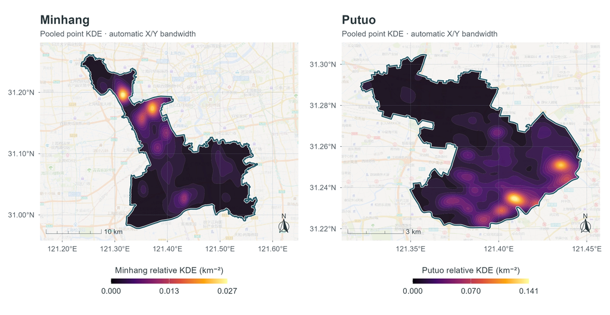

各区分别合并三年、两平台记录，独立估计空间概率密度。

**绘图代码 · 两区 KDE 地图密度计算 → 等值带 → 地图整饰 → 双区拼图**

承接 4.3 的 原始点地图代码，复用底图、地图窗口与整饰函数；`tidyverse`、`sf` 和 `patchwork` 沿用前文。

**模块 1：设置主题与底图。**沿用前节底图，降低不透明度，便于辨认密度色带。

```r
figure_theme <- "light"  # 改为"dark"可切换深色主题
fused_palette <- palettes[[figure_theme]]

# 分别设置浅色、深色主题的底图不透明度。
density_alpha <- c(light = .22, dark = .25)

# 使用4.3读取的两区底图，并按当前主题调整颜色与明度。
density_basemaps <- lapply(names(district_labels), function(slug) {
  theme_basemap(
    point_rasters[[slug]], figure_theme,
    alpha = density_alpha[[figure_theme]], panel_colour = fused_palette$panel
  )
})
names(density_basemaps) <- names(district_labels)
```

**模块 2：定义单区估计函数。**在 EPSG:32651 下，自动选择两个方向的带宽，估计 `512 × 512` 个位置的密度。

```r
estimate_district_kde <- function(slug) {
  # 原始点与区界使用米制坐标，距离和带宽的单位均为米。
  boundary <- study_area[study_area$slug == slug, ]
  district_points <- social_points[social_points$slug == slug, ]
  xy <- st_coordinates(district_points)

  # bandwidth.nrd()分别估计X、Y方向带宽；kde2d()内部将h除以4。
  h_arg <- c(
    x = MASS::bandwidth.nrd(xy[, 1]),
    y = MASS::bandwidth.nrd(xy[, 2])
  )
  sigma <- h_arg / 4

  # 求值范围向区界外延伸三个核标准差，保留边缘密度的衰减过程。
  bbox <- st_bbox(boundary)
  margin <- 3 * sigma
  limits <- c(
    bbox[["xmin"]] - margin[1], bbox[["xmax"]] + margin[1],
    bbox[["ymin"]] - margin[2], bbox[["ymax"]] + margin[2]
  )

  # 全部原始记录直接输入；kde2d() 按样本数生成概率密度。
  # h_arg 原值传入函数，由其内部完成 /4 换算。
  fit <- MASS::kde2d(
    x = xy[, 1], y = xy[, 2], h = h_arg,
    n = c(512, 512), lims = limits
  )

  # 建立与密度矩阵对应的求值点，识别落在本区内部的位置。
  evaluation_xy <- expand.grid(x = fit$x, y = fit$y)
  evaluation_points <- st_as_sf(
    evaluation_xy, coords = c("x", "y"), crs = 32651
  )
  inside <- matrix(
    lengths(st_intersects(evaluation_points, boundary)) > 0L,
    nrow = length(fit$x), ncol = length(fit$y)
  )

  # fit$z 为每平方米概率密度，乘以 1e6 转为每平方千米概率密度。
  list(x = fit$x, y = fit$y, zrel = fit$z * 1e6, inside = inside)
}
```

**模块 3：逐区估计并设置色阶。**对两个区分别调用函数，用各区内部的最大密度设置图例上限。

```r
# 对minhang与putuo分别调用函数，得到两张独立密度面。
kde_surfaces <- lapply(names(district_labels), estimate_district_kde)
names(kde_surfaces) <- names(district_labels)

density_limits <- lapply(kde_surfaces, function(surface) {
  c(0, max(surface$zrel[surface$inside]))
})
```

**模块 4：生成密度等值带。**`isoband` 将密度面分为 20 个区间，再将多边形裁切到区界内；`t()` 用于匹配矩阵行列约定。

```r
make_density_bands <- function(slug) {
  surface <- kde_surfaces[[slug]]
  boundary <- study_area[study_area$slug == slug, ]
  maximum <- density_limits[[slug]][2]

  # 从0到区内最大密度等距划分20个区间，并计算区间中点。
  breaks <- seq(0, maximum, length.out = 21L)
  lower <- head(breaks, -1L)
  upper <- tail(breaks, -1L)
  midpoints <- (lower + upper) / 2
  upper[length(upper)] <- Inf  # 最后一个区间包含密度最大值

  # MASS按X为行、Y为列保存矩阵，isoband要求Y为行、X为列。
  bands <- isoband::isobands(
    surface$x, surface$y, t(surface$zrel), lower, upper
  )
  bands <- st_sf(
    density = midpoints,
    geometry = st_sfc(unname(isoband::iso_to_sfg(bands)), crs = 32651)
  )

  # 删除空几何，修复可能无效的多边形，再按区界裁切。
  bands <- bands[!st_is_empty(bands), ]
  st_agr(bands) <- "constant"  # 裁切不改变密度属性
  bands <- st_intersection(st_make_valid(bands), st_geometry(boundary))
  bands <- bands[!st_is_empty(bands) & st_dimension(bands) == 2L, ]

  # 密度计算使用EPSG:32651，地图显示转换到底图的EPSG:3857。
  st_transform(bands, 3857)
}

contour_bands <- lapply(names(district_labels), make_density_bands)
names(contour_bands) <- names(district_labels)
```

**模块 5：定义地图函数。**叠加密度色带，设置各区图例，再添加区界、经纬网、比例尺和指北针。

```r
make_kde_panel <- function(slug) {
  boundary <- map_boundaries[map_boundaries$slug == slug, ]
  maximum <- density_limits[[slug]][2]

  # 先放置低不透明度的底图，再叠加20个密度色带。
  plot <- map_base(point_windows[[slug]], density_basemaps[[slug]], boundary) +
    geom_sf(
      data = contour_bands[[slug]], aes(fill = density),
      colour = NA, alpha = .92
    ) +
    # inferno色带映射密度；limits固定当前区的色阶范围。
    scale_fill_viridis_c(
      option = "inferno", limits = c(0, maximum),
      breaks = c(0, maximum / 2, maximum),
      labels = scales::label_number(accuracy = .001),
      name = paste(district_labels[[slug]], "relative KDE (km⁻²)"),
      guide = guide_colourbar(
        order = 1, title.position = "top", title.hjust = .5,
        barwidth = grid::unit(68, "mm"), barheight = grid::unit(3, "mm")
      )
    ) +
    labs(
      title = district_labels[[slug]],
      subtitle = "Pooled point KDE · automatic X/Y bandwidth"
    )

  # 添加经纬网、区界、比例尺、指北针与地图主题。
  map_frame(plot, list(boundary = boundary, window = point_windows[[slug]])) +
    theme(
      plot.title = element_text(colour = fused_palette$ink, size = 20, face = "bold"),
      plot.subtitle = element_text(colour = fused_palette$muted, size = 13)
    )
}
```

**模块 6：生成两区地图。**`lapply()` 逐区调用地图函数，得到两个 `ggplot` 对象。

```r
# 逐区调用绘图函数，返回两个独立的ggplot对象。
kde_panels <- lapply(names(district_labels), make_kde_panel)
names(kde_panels) <- names(district_labels)
```

**模块 7：拼接并显示。**`wrap_plots()` 将地图左右排列，`guides = "keep"` 保留各区色条。

```r
# 两个面板按两列拼接，透明背景便于嵌入不同页面主题。
kde_map <- wrap_plots(kde_panels, ncol = 2, guides = "keep") +
  plot_annotation(
    theme = theme(plot.background = element_rect(fill = "transparent", colour = NA))
  )

# 单独写出对象名，即可在RStudio的Plots面板显示组合地图。
kde_map
```

**© 华东师范大学 社会发展学院 人口研究所** | [**DAWN 研究组**](https://dawn-ecnu.github.io) | yzliu@soci.ecnu.edu.cn

课程负责人：刘贇喆 本章作者：刘贇喆 | 敖漪宇

最后更新：2026年11月13日 构建环境：R version 4.6.1 (2026-06-24 ucrt)

[CC BY-NC-SA 4.0](https://creativecommons.org/licenses/by-nc-sa/4.0/deed.zh) 回到顶部

##### AOI提取

###### **4.5 从单一密度面的P95提取兴趣区**

接续 4.4 的核密度估计，将高密度范围提取为多边形，再统计其面积与记录覆盖。

**AOI 与城市兴趣区**

AOI（Area of Interest）用于表达具有空间范围的关注对象，通常以多边形表示。城市研究可据此识别**活动集聚区**或**具有功能联系的区域**，如商圈、校园与公园。

本节将社交媒体记录的高密度范围作为城市兴趣区，边界由数据、带宽与阈值共同决定。

**阈值选择：区内密度值的 P95**

分别取两区内部求值位置的密度值，计算其**第 95 百分位（P95）**，再将达到阈值的连续范围转为多边形。

阈值可随研究目的调整。参考：[Esri 应用案例](https://www.esri.com/arcgis-blog/products/arcgis-pro/analytics/density-to-decisions-with-percentile-contours-tools) · [阈值选择说明](https://doc.arcgis.com/en/arcgis-solutions/latest/reference/identify-hot-spots.htm)

**计算示例 · 闵行区 P95 AOI确定阈值 → 提取多边形 → 统计覆盖记录**

承接 4.4“计算示例 · 闵行区 KDE”，使用 `kde`、`minhang_points` 与 `minhang_boundary`。

**模块 1：计算区内 P95。**`expand.grid()` 建立求值位置，点面关系筛选区内位置，再计算这些位置的密度百分位。

```r
# expand.grid() 使 X 先变化，与密度矩阵按列展开的顺序一致。
evaluation_xy <- expand.grid(x = kde$x, y = kde$y)
evaluation_points <- st_as_sf(evaluation_xy, coords = c("x", "y"),
                               crs = 32651)
inside <- lengths(st_intersects(evaluation_points, minhang_boundary)) > 0
# quantile() 默认使用 type = 7；此处只取区内求值位置的密度。
threshold <- quantile(as.vector(kde$z)[inside], 0.95)
```

**模块 2：提取并裁切多边形。**`t()` 匹配矩阵行列约定，`isobands()` 提取达到阈值的范围，随后修复几何并裁切到区界。

```r
# 达到阈值的密度范围形成等值面；t() 将 X 行、Y 列转为 Y 行、X 列。
bands <- isoband::isobands(kde$x, kde$y, t(kde$z),
  levels_low = unname(threshold), levels_high = Inf)
contour <- st_sfc(isoband::iso_to_sfg(bands), crs = 32651)
minhang_aoi <- st_intersection(st_make_valid(contour),
                               st_geometry(minhang_boundary)) %>%
  st_make_valid() %>% st_union()
```

> 本例的密度与阈值均为 m⁻²；完整地图沿用 4.4 的 km⁻² 密度面，单位换算不改变提取范围。

**模块 3：统计覆盖。**用点面关系统计 AOI 内的记录数、记录占比和面积。

```r
# st_intersects() 计入 AOI 内部及边界上的记录，再汇总覆盖率。
in_aoi <- lengths(st_intersects(minhang_points, minhang_aoi)) > 0
sum(in_aoi)       # AOI内12755条记录
100 * mean(in_aoi)  # 约35.43%
sum(as.numeric(st_area(minhang_aoi))) / 1e6  # 约18.63 km²
```

**两区的 P95 兴趣区**

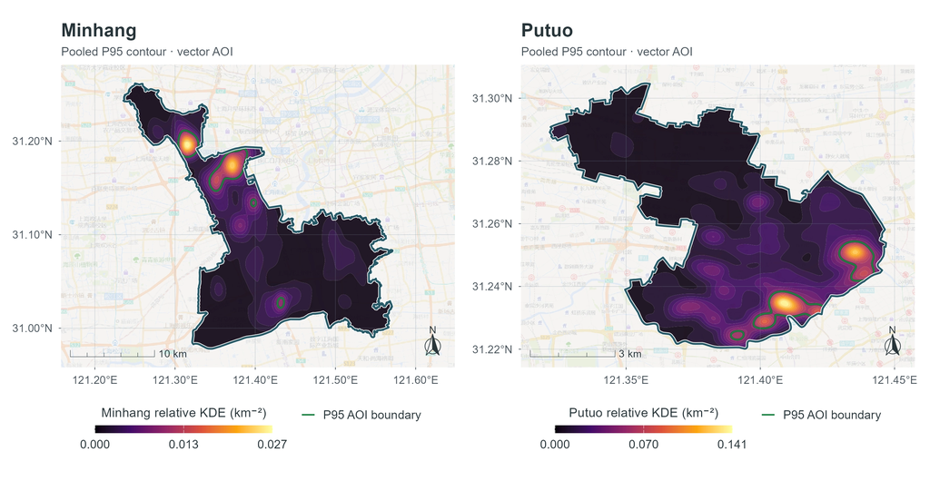

各区独立计算 P95，绿色轮廓表示由密度面提取的 AOI。

**绘图代码 · 两区 P95 AOI提取与裁切 → 逐区计算 → 地图整饰 → 双区拼图**

承接 4.4“两区 KDE 地图”代码，复用密度面、密度色带、底图和地图函数；沿用前文已载入的 `tidyverse`、`sf` 与 `patchwork`。

**模块 1：定义单区提取函数。**用区内求值位置计算 P95，提取等值面，在 EPSG:32651 下裁切，再转换为绘图坐标系。

```r
extract_district_aoi <- function(slug) {
  surface <- kde_surfaces[[slug]]
  boundary <- study_area[study_area$slug == slug, ]

  # zrel 在 4.4 已换算为 km⁻²，P95 阈值沿用同一单位。
  # type = 7 是 quantile() 的默认算法；unname() 去除分位数名称。
  threshold <- unname(quantile(
    surface$zrel[surface$inside], probs = .95, type = 7
  ))

  z <- surface$zrel

  # MASS与isoband的矩阵行列方向不同，因此传入t(z)。
  band <- isoband::isobands(
    surface$x, surface$y, t(z),
    levels_low = threshold, levels_high = Inf
  )
  contour <- st_sfc(isoband::iso_to_sfg(band), crs = 32651)

  # 修复几何后裁切到区界；几何集合只保留其中的面要素。
  clipped <- st_make_valid(st_intersection(
    st_make_valid(contour), st_geometry(boundary)
  ))
  if (any(st_geometry_type(clipped) == "GEOMETRYCOLLECTION")) {
    clipped <- st_collection_extract(clipped, "POLYGON", warn = FALSE)
  }
  clipped <- clipped[!st_is_empty(clipped)]

  # st_union()合并同一区的AOI要素，空间上分离的斑块仍保留。
  st_sf(
    district_name = unique(boundary$district_name), slug = slug,
    threshold_relative = threshold, geometry = st_union(clipped)
  ) %>% st_transform(3857)
}
```

**模块 2：逐区提取 AOI。**`lapply()` 逐区调用函数，`do.call(rbind, ...)` 合并空间要素，再沿用 4.4 的主题设置轮廓颜色。

```r
# lapply() 返回各区的 sf 要素列表；do.call() 将列表交给 rbind() 合并。
aoi_polygons <- do.call(
  rbind, lapply(names(district_labels), extract_district_aoi)
)

# AOI主线随页面主题切换，深色衬线用于提高轮廓辨识度。
fused_palette$aoi <- if (figure_theme == "light") "#208345" else "#83F5A5"
```

**模块 3：定义 AOI 地图。**在 4.4 的密度色带上叠加 AOI 轮廓，并保留各区独立的密度色条。

```r
make_aoi_panel <- function(slug) {
  boundary <- map_boundaries[map_boundaries$slug == slug, ]
  district_aoi <- aoi_polygons[aoi_polygons$slug == slug, ]
  maximum <- density_limits[[slug]][2]

  plot <- map_base(point_windows[[slug]], density_basemaps[[slug]], boundary) +
    # 20个密度等值带提供背景，fill映射区间中点密度。
    geom_sf(
      data = contour_bands[[slug]], aes(fill = density),
      colour = NA, alpha = .92
    ) +
    scale_fill_viridis_c(
      option = "inferno", limits = c(0, maximum),
      breaks = c(0, maximum / 2, maximum),
      labels = scales::label_number(accuracy = .001),
      name = paste(district_labels[[slug]], "relative KDE (km⁻²)"),
      guide = guide_colourbar(
        order = 1, title.position = "top", title.hjust = .5,
        barwidth = grid::unit(68, "mm"), barheight = grid::unit(3, "mm")
      )
    ) +
    # 深绿色粗线作衬边，主题绿色细线表示实际AOI边界。
    geom_sf(
      data = district_aoi, fill = NA,
      colour = "#15592A", linewidth = 1.0
    ) +
    geom_sf(
      data = district_aoi, aes(colour = "P95 AOI boundary"),
      fill = NA, linewidth = .6, key_glyph = "path"
    ) +
    scale_colour_manual(
      values = c("P95 AOI boundary" = fused_palette$aoi), name = NULL,
      guide = guide_legend(
        order = 2, override.aes = list(fill = NA, linewidth = .8)
      )
    ) +
    labs(
      title = district_labels[[slug]],
      subtitle = "Pooled P95 contour · vector AOI"
    )

  # 添加经纬网、区界、比例尺、指北针与地图主题。
  map_frame(plot, list(boundary = boundary, window = point_windows[[slug]])) +
    theme(
      plot.title = element_text(colour = fused_palette$ink, size = 20, face = "bold"),
      plot.subtitle = element_text(colour = fused_palette$muted, size = 13)
    )
}
```

**模块 4：拼接并显示。**`wrap_plots()` 左右排列两区地图，`guides = "keep"` 保留各区图例。

```r
aoi_panels <- lapply(names(district_labels), make_aoi_panel)
names(aoi_panels) <- names(district_labels)

# guides = "keep"保留各区独立图例，避免合并不同范围的密度色阶。
aoi_map <- wrap_plots(aoi_panels, ncol = 2, guides = "keep") +
  plot_annotation(
    theme = theme(plot.background = element_rect(fill = "transparent", colour = NA))
  )

# 单独写出对象名，即可在RStudio的Plots面板显示组合地图。
aoi_map
```

**面积与记录覆盖**

AOI面积、斑块数与记录覆盖

| 研究区 | 斑块数 | AOI面积（km²） | 行政区面积占比（%） | AOI内记录 | 记录占比（%） |
| --- | --- | --- | --- | --- | --- |
| 闵行区 | 4 | 18.63 | 4.99 | 12755 | 35.43 |
| 普陀区 | 3 | 2.77 | 4.99 | 10250 | 28.47 |

闵行的**4 个斑块**覆盖**35.43%**的记录；普陀的**3 个斑块**覆盖**28.47%**。面积表示识别出的空间范围，记录占比表示这些范围集中了多少条记录。

**表格代码 · 面积与记录覆盖米制面积、分离斑块与记录计数**

先运行本节的两区 AOI 提取代码。面积统计回到 EPSG:32651；合并几何中的各个 `POLYGON` 作为分离斑块，孔洞不另计。

```r
# 逐区汇总；地图几何采用 EPSG:3857，面积计算先转换回米制分析投影。
aoi_summary <- lapply(names(district_labels), function(slug) {
  boundary <- study_area[study_area$slug == slug, ]
  district_points <- social_points[social_points$slug == slug, ]
  aoi <- aoi_polygons[aoi_polygons$slug == slug, ] %>% st_transform(32651)

  # st_cast() 拆分空间上分离的面；st_intersects() 统计记录覆盖。
  patches <- st_cast(st_geometry(aoi), "POLYGON")
  in_aoi <- lengths(st_intersects(district_points, aoi)) > 0
  aoi_area <- as.numeric(sum(st_area(aoi)))
  boundary_area <- as.numeric(sum(st_area(boundary)))

  tibble(
    研究区 = unique(boundary$district_name), 斑块数 = length(patches),
    `AOI面积（km²）` = aoi_area / 1e6,
    `行政区面积占比（%）` = 100 * aoi_area / boundary_area,
    AOI内记录 = sum(in_aoi), `记录占比（%）` = 100 * mean(in_aoi)
  )
}) %>% bind_rows()

knitr::kable(
  aoi_summary, digits = c(0, 0, 2, 2, 0, 2), row.names = FALSE,
  caption = "AOI面积、斑块数与记录覆盖"
)
```

**延伸阅读 · 城市兴趣区怎样识别社交媒体活动集聚与多模态边界生成**

**活动集聚与区内语义**Kim & Yang（2026）

[GeoAI-driven analysis of urban activity shifts using geotagged social media data across the COVID-19 pandemic](https://doi.org/10.1177/23998083251413306)

Environment and Planning B: Urban Analytics and City Science, 53(8), 1839-1858.

用 HDBSCAN 对 Flickr 照片点位聚类以划定兴趣区，再用图像分类解释区内活动类型，观察其随时间的变化。

**从影像生成区域边界**Shi et al.（2025）

[Multimodal urban areas of interest generation via remote sensing imagery and geographical prior](https://doi.org/10.1016/j.jag.2024.104326)

International Journal of Applied Earth Observation and Geoinformation, 136, 104326.

融合遥感影像、POI 与道路节点等地理先验，直接预测 AOI 多边形，展示功能对象边界的另一种识别思路。[开放稿](https://arxiv.org/abs/2401.06550)

**© 华东师范大学 社会发展学院 人口研究所** | [**DAWN 研究组**](https://dawn-ecnu.github.io) | yzliu@soci.ecnu.edu.cn

课程负责人：刘贇喆 本章作者：刘贇喆 | 敖漪宇

最后更新：2026年11月13日 构建环境：R version 4.6.1 (2026-06-24 ucrt)

[CC BY-NC-SA 4.0](https://creativecommons.org/licenses/by-nc-sa/4.0/deed.zh) 回到顶部

##### 交通距离比较

###### **4.6 计算最近设施距离并比较AOI内外**

按 AOI 内外分组，比较记录到最近公交、地铁类 POI 的直线距离。

**计算示例 · 闵行区最近公交距离设施候选 → AOI 分组 → 最近匹配 → 汇总**

承接 4.5 的闵行区 AOI 示例，使用 `minhang_points` 与 `minhang_aoi`；沿用前文已加载的 `tidyverse` 和 `sf`。

**模块 1：读取全市设施并统一投影。**保留邻区候选，避免边界附近记录遗漏最近设施；EPSG:32651 的距离单位为米。

```r
# 全市设施统一到米制投影，不按区裁切，以保留邻区的最近候选。
bus_points <- st_read("data/公交站.geojson", quiet = TRUE) %>%
  st_transform(32651)
```

**模块 2：按 AOI 分组。**沿用 4.5 的 `minhang_aoi`，将内部及边界上的记录归入 AOI 组。

```r
# st_intersects() 判断相交，内部及边界上的记录均归入 AOI。
minhang_points$aoi_status <- ifelse(
  lengths(st_intersects(minhang_points, minhang_aoi)) > 0,
  "AOI", "nonAOI"
)
```

**模块 3：匹配设施并计算距离。**`st_nearest_feature()` 返回最近设施的行号，`by_element = TRUE` 让点与对应设施逐对计算。

```r
# 最近设施索引与记录逐行对应；by_element = TRUE 只计算这些配对的距离。
nearest_index <- st_nearest_feature(minhang_points, bus_points)
minhang_points$distance_m <- as.numeric(st_distance(
  minhang_points, bus_points[nearest_index, ], by_element = TRUE
))
```

**模块 4：查看分组结果。**闵行 AOI 内 12,755 条、非 AOI 23,245 条；平均公交距离分别约 191.0 米、206.9 米。

```r
minhang_points %>% st_drop_geometry() %>%
  group_by(aoi_status) %>%
  summarise(n = n(), mean_m = mean(distance_m),
            median_m = median(distance_m), .groups = "drop")
```

将设施文件换为 `data/地铁站.geojson` 即可计算最近地铁类 POI 距离。两区、两类设施汇总后得到 144,000 行“记录 × 设施类型”距离表。

**云雨图怎样读？**回看第 3 章 · 3.6

- **云：**半小提琴显示分布形状，高度不表示记录数。
- **箱：**箱体概括中间一半记录，中线为中位数；菱形为均值。
- **雨：**抽样记录堆叠为点，每点最多表示 5 条抽中记录。

**闵行区 · AOI 内外交通距离**

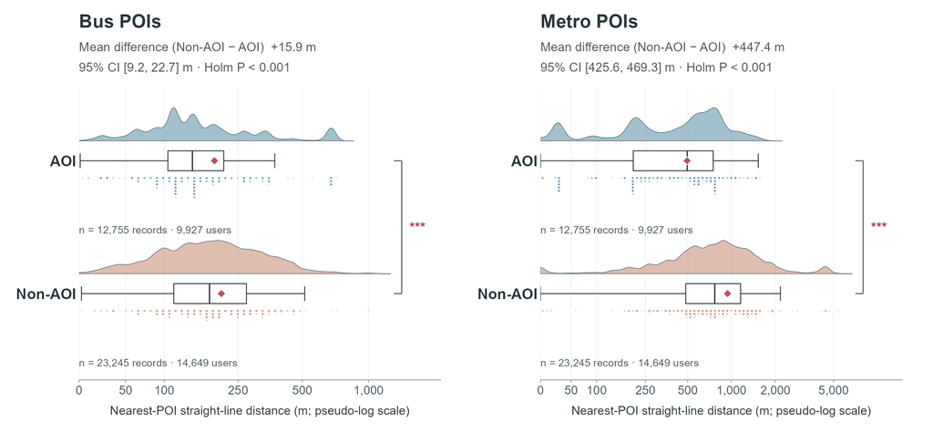

Holm 校正后：* p < 0.05，** p < 0.01，*** p < 0.001；区间为逐项 95% CI。

**普陀区 · AOI 内外交通距离**

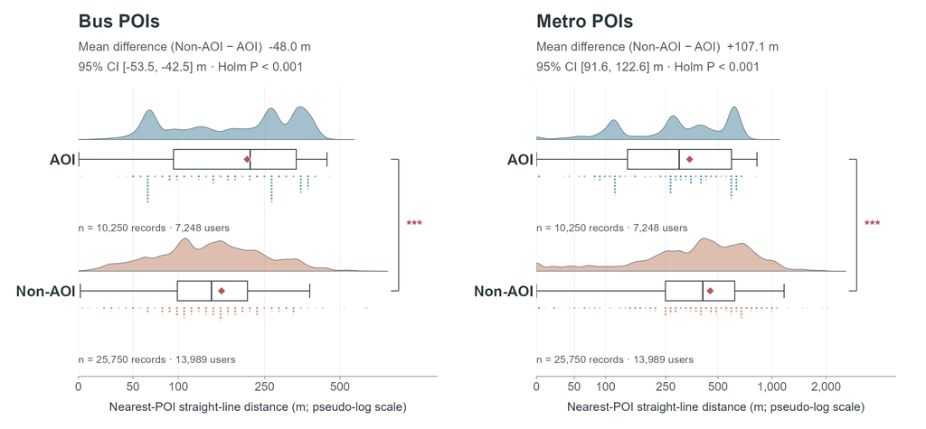

Holm 校正后：* p < 0.05，** p < 0.01，*** p < 0.001；区间为逐项 95% CI。

**计算与绘图代码 · 两区交通距离距离表 → 分布图层 → 账号聚类检验 → 云雨图**

承接 4.5 的两区 AOI 代码，使用 `social_points`、`aoi_polygons` 与 `district_labels`；沿用 `tidyverse`、`sf` 和 `patchwork`。

**模块 1：生成完整距离表。**按 AOI 内外分组，分别计算到最近公交、地铁类 POI 的距离。

```r
facility_labels <- c(bus = "Bus POIs", subway = "Metro POIs")

# 行号用于固定雨点抽样顺序，平台与匿名账号共同标识平台内账号。
social_points$source_row_id <- seq_len(nrow(social_points))
social_points$user_cluster_id <- paste(
  social_points$platform, social_points$user_id, sep = "::"
)
social_points$aoi_status <- "nonAOI"

# 4.5的AOI用于地图显示，转回EPSG:32651后与原始点进行空间叠加。
aoi_metric <- st_transform(aoi_polygons, 32651)
for (slug in names(district_labels)) {
  selected <- social_points$slug == slug
  district_aoi <- aoi_metric[aoi_metric$slug == slug, ]
  inside <- lengths(st_intersects(
    social_points[selected, ], district_aoi
  )) > 0L
  # 位于AOI内部或边界上的记录均归入AOI组。
  social_points$aoi_status[selected] <- ifelse(inside, "AOI", "nonAOI")
}

station_paths <- c(
  bus = "data/公交站.geojson",
  subway = "data/地铁站.geojson"
)
distance_parts <- lapply(names(facility_labels), function(station_type) {
  stations <- st_read(station_paths[[station_type]], quiet = TRUE) %>%
    st_transform(32651)

  # 最近设施可位于邻区；索引给出每条记录对应的最近POI行号。
  nearest_index <- st_nearest_feature(social_points, stations)
  distance_m <- as.numeric(st_distance(
    social_points, stations[nearest_index, ], by_element = TRUE
  ))

  # 去掉空间几何后整理成长表，每条记录保留AOI分组与账号标识。
  social_points %>% st_drop_geometry() %>%
    select(source_row_id, district_name, slug, user_id, platform,
           user_cluster_id, aoi_status) %>%
    mutate(station_type = station_type, distance_m = distance_m)
})
distance_long <- bind_rows(distance_parts)
```

**模块 2：准备显示坐标与箱线统计。**箱体、中位数和均值先按原始米数计算，再转换为 pseudo-log 显示坐标。

```r
# pseudo-log 在 0 附近近似线性，较大值按对数压缩；sigma 控制过渡尺度。
distance_transform <- scales::transform_pseudo_log(sigma = 50, base = 10)
distance_view <- distance_long %>%
  mutate(
    group_id = if_else(aoi_status == "AOI", 2, 1),
    distance_view = distance_transform$transform(distance_m)
  )

box_summary <- distance_long %>%
  group_by(slug, station_type, aoi_status) %>%
  group_modify(~ {
    # boxplot.stats()给出箱体与1.5倍IQR规则下的胡须端点。
    box_values <- boxplot.stats(.x$distance_m, do.conf = FALSE)$stats
    tibble(
      n_records = nrow(.x), n_users = n_distinct(.x$user_cluster_id),
      whisker_low_m = box_values[1], q25_m = box_values[2],
      median_m = box_values[3], q75_m = box_values[4],
      whisker_high_m = box_values[5], mean_m = mean(.x$distance_m)
    )
  }) %>%
  ungroup() %>%
  mutate(
    group_id = if_else(aoi_status == "AOI", 2, 1),
    # across()一次性转换六个距离统计量，并保留原米制列。
    across(
      c(whisker_low_m, q25_m, median_m, q75_m, whisker_high_m, mean_m),
      distance_transform$transform, .names = "{.col}_view"
    ),
    count_label = paste0(
      "n = ", format(n_records, big.mark = ",", trim = TRUE),
      " records · ", format(n_users, big.mark = ",", trim = TRUE), " users"
    )
  )

# 垂直方向依次安排雨点、箱线和半小提琴，并为样本数标签留白。
cloud_base_offset <- .15
cloud_height <- .25
box_half_height <- .075
whisker_half_height <- .055
dot_base_offset <- -.13
count_label_offset <- -.52
panel_y_limits <- c(.35, 2.55)
```

**模块 3：计算半小提琴。**在 pseudo-log 坐标中估计密度，并在 0 处反射校正；各组曲线等高，高度不表示样本量。

```r
# values 是 pseudo-log 显示坐标；返回归一化密度轮廓的坐标。
half_density <- function(values) {
  # 在pseudo-log坐标中估计带宽，0.8为平滑程度的倍率。
  effective_bandwidth <- 0.8 * stats::bw.nrd0(values)

  # c(-values, values)构造关于0的反射样本，实际只绘制非负一侧。
  fitted <- stats::density(
    c(-values, values), bw = effective_bandwidth,
    from = 0, to = max(values) + 4 * effective_bandwidth, n = 512
  )

  # 首尾补0形成闭合多边形，密度除以最大值后统一半小提琴高度。
  tibble(
    distance_view = c(0, fitted$x, tail(fitted$x, 1)),
    density_height = c(0, fitted$y / max(fitted$y), 0)
  )
}

density_polygons <- distance_view %>%
  group_by(slug, station_type, aoi_status, group_id) %>%
  group_modify(~ half_density(.x$distance_view)) %>%
  ungroup() %>%
  mutate(
    density_y = group_id + cloud_base_offset + cloud_height * density_height
  )
```

**模块 4：抽取并堆叠雨点。**每组最多随机抽取 260 条，再补入真实极值；雨点只辅助显示，其他图层使用全部记录。

```r
dot_binwidth <- .028
dot_records_per_point <- 5L
dot_stack_step <- .024
set.seed(20261016)

display_points <- distance_view %>%
  group_by(slug, station_type, aoi_status, group_id) %>%
  group_modify(~ {
    # 先按原始行号排列，保证固定种子在不同运行中得到相同样本。
    .x <- arrange(.x, source_row_id)
    selected_rows <- unique(c(
      sample.int(nrow(.x), min(260L, nrow(.x))),
      which.min(.x$distance_m), which.max(.x$distance_m)
    ))
    .x[selected_rows, ]
  }) %>%
  ungroup() %>%
  mutate(
    # 横坐标落在分箱中心，减少重叠；并非每条记录的精确横坐标。
    dot_bin = floor(distance_view / dot_binwidth),
    dot_x = (dot_bin + .5) * dot_binwidth
  ) %>%
  arrange(slug, station_type, aoi_status, dot_bin, distance_view) %>%
  group_by(slug, station_type, aoi_status, group_id, dot_bin) %>%
  mutate(dot_stack = ceiling(row_number() / dot_records_per_point)) %>%
  ungroup()

dot_cells <- display_points %>%
  group_by(slug, station_type, aoi_status, group_id, dot_bin, dot_stack) %>%
  summarise(dot_x = first(dot_x), dot_records = n(), .groups = "drop") %>%
  mutate(
    dot_y = group_id + dot_base_offset - dot_stack_step * (dot_stack - 1),
    # 同一雨点最多合并5条抽中记录，记录越多，点越不透明。
    dot_alpha = .86 * dot_records / dot_records_per_point
  )
```

**模块 5：定义账号聚类比较函数。**按账号汇总记录对均值差的贡献，用 CR1 有限样本修正计算标准误及 95% 区间。

```r
# 比较单位仍为记录；同一账号的记录先合并贡献，用于估计均值差的不确定性。
compare_aoi_distance <- function(data) {
  inside <- data$aoi_status == "AOI"
  mean_inside <- mean(data$distance_m[inside])
  mean_outside <- mean(data$distance_m[!inside])
  difference <- mean_outside - mean_inside
  n_records <- nrow(data)
  n_accounts <- n_distinct(data$user_cluster_id)

  # 影响量用于估计均值差的标准误：组内偏差除以本组记录数，AOI 组取负。
  # rowsum() 按账号加总，保留同一账号多条记录之间的关联。
  influence <- if_else(
    inside, -(data$distance_m - mean_inside) / sum(inside),
    (data$distance_m - mean_outside) / sum(!inside)
  )
  account_influence <- rowsum(influence, data$user_cluster_id, reorder = FALSE)

  # CR1 有限样本修正：账号数决定聚类数，记录数减 2 对应两组均值。
  correction <- n_accounts / (n_accounts - 1) *
    (n_records - 1) / (n_records - 2)
  standard_error <- sqrt(correction * sum(account_influence^2))
  # qt(.975) 给出双侧 95% 区间的临界值；自由度为账号数减 1。
  critical_t <- qt(.975, df = n_accounts - 1)

  tibble(
    mean_inside_m = mean_inside, mean_outside_m = mean_outside,
    estimate_out_minus_in_m = difference,
    se_user_cluster_m = standard_error,
    ci_low_m = difference - critical_t * standard_error,
    ci_high_m = difference + critical_t * standard_error,
    # pt() 计算 t 分布尾概率；乘 2 得到双侧原始 p 值。
    p_raw = 2 * pt(-abs(difference / standard_error), df = n_accounts - 1)
  )
}
```